# Graphical Grammar

A historical survey up to Chomsky and Tesnière

Michael Cysouw

Prepublication draft

November 26, 2024

# 1 Visualising sentences

## 1.1 Graphics before Chomsky and Tesnière

## 1.2 Graphical methods

- symbols inserted between words
- symbols added/above each word
- symbolic abbreviations
- curly braces for grouping
- other brackets for grouping
- vertical/slanted lines
- chinese boxes
- numbered tables
- positional tables/templates
- music score, high/low lines
- indentation
- etc.

## 1.3 Functional terminology for sentence analysis

[1.1] Slowly, during the 17th and 18th Century, a new terminological amalgamation arose, combining terms from Aristotelian logic with concepts from the descriptive grammatical tradition. The result of this mixture are the contemporary terms “subject”, “object” and “predicate”, which seem to be first used in the modern sense at the start of the 19th Century. The history of the emergence of these terms deserves a detailed investigation in it’s own right (e.g. Forsgren 1985; Forsgren 1992– for the German grammatical tradition). The following summary is but a very short and strongly simplified overview of this terminological development. The underlying impetus for this development appears to be an ambition on behalve of grammarians to insert more “logic” into their analyses, or, in more modern terms, to create general terms for grammatical functions on top of the description of the grammatical form of linguistic elements.

[1.2] Everything starts with Aristoteles. First, the term “subject”, through Latin *subiectum*, is a calque from Greek *ὑποκείμενον* ‘that which lies beneath’. This term is one of the central tenets of Aristotelian philosophy of substance. Similarly, the term “predicate” is derived from Latin *praedicatum*, which is a calque from Greek *κατηγορούμενον* ‘that which is being spoken against’. These two elements, subject and predicate, are the building blocks of the Aristotelian (and medieval) logical proposition, not of a linguistic sentence. Linguistically, a Greek *λόγος* ‘sentence’ consists of *ὄνομᾰ* ‘noun’ and *ῥῆμα* ‘verb’. Although Aristotle describes a third element linking the logical terms *ὑποκείμενον* ‘subject’ and *κατηγορούμενον* ‘predicate’, he does not use a specific term for this third element. Moro (2017: 35) argues that only with Abelard in the 12th Century a specific term is introduced for this link, namely the Latin term *copula*. Separataly, the term object, from Latin *objectum*, is a calque from Aristotle’s *ἀντικείμενον* ‘that which lies opposite’. This term does not play any role in classical logical analysis, it only figures as a philosophical concept for observed reality.

[1.3] In the ensuing centuries, the Latin terms *subiectum*, *praedicatum* and *copula* become a staple in medieval logic, specifically in the analysis of the syllogism. In contrast, these terms are never used for grammatical analysis of language. For example, the 13th Century scholastic grammarians (the “Modists”) use *suppositum* and *appositum* approximately in the sense of the Greek *ὄνομᾰ* and *ῥῆμα*, respectively (Robins 1980: 234).

[1.4] In the 17th Century, the *Grammaire Générale et Raisonnée* from 1660 by Antoine Arnauld and Claude Lancelot is probably one of the first occurences of new terminology. In their attempt to link language to logic and thought, there is a first glimpse of a terminological confluence of Aristotelian logic and the grammatical tradition, as the french word *sujet* ist used, although alongside *attribut* and not yet something like *prédicat*:

> La connoissance de la nature du Verbe dépend de ce que nous avons dit au commencement de ce discours, que le jugement que nous faisons des choses (comme quand je dis, *la terre est ronde*) enferme necessairement deux termes; l’un appellé sujet, qui est ce dont on affirme, comme, *terre*; & l’autre appellé attribut, qui est ce qu’on affirme, comme *ronde*: Et de plus la liaison entre ces deux termes, qui est proprement l’action de notre esprit qui affirme l’attribut du sujet. (Arnauld & Lancelot 1660: 89)

> (‘The knowledge of the nature of the Verb depends on what we said at the beginning of this discourse, that the judgment we make about things (as when I say, *the earth is round*) necessarily includes two terms: one called subject, which is what we affirm about, such as *earth*; and the other called attribute, which is what is affirmed, such as *round*. And moreover the connection between these two terms, which is strictly the action of our mind that affirms the attribute about the subject.’ translation from Kahane 2020: 100)

[1.5] Also in the 17th Century, Christopher Cooper in his *Grammatica Linguae Aglicanae*, a grammar of the English language written in Latin, makes an attempt to bridge the two worlds of grammatical and logical analysis, clearly articulating the difference between the grammatical term “nominative” and the logical term “subject”. He also uses the term “predicate”, but apparently not yet “object”:

> Substantivum … Et hoc a *grammaticis* noncupatur casus nominativus, a *logicis* subjectum. … Id … vocatur praedicatum; quod si duobus verbis exprimitur, substantivum vel adjectivum subsequens copulam in regimine. (Cooper 1685: 171-172)

> (‘Noun, … grammatically it is called nominative, logically it is called subject. … It is called predicate when there are two words expressed, noun or adjective following a copula.’)

[1.6] In the 18th Century the use of the logical terminology for functional categories in the analysis of sentence structure broadens. For example, in France, l’Abbé Girard in *Les vrais principes de la language françoise* (1747: 90-92) uses the terms *Subjectif*, *Attributif* and *Objectif* (see also Forsgren 1985: 43). He seems to build on the *sujet/attribut* terminology from the *Grammaire Générale et Raisonnée* (see above) and extends this functional approach to other aspects of linguistic structure, notebly introducing the term “object”. In Germany, Johann Christoph Adelung in his *Umständliches Lehrgebäude der Deutschen Sprache* (1782: 61) uses the terms *Subject* and *Praedicat*, but not anyting resembling the term object. In yet another example, this time from England, Joseph Priestly in his *Rudiments of English Grammar* (1772) uses the terms “subject” and “object”, but he does not appear to have used the term “predicate”:

> *Q.* What is meant by the Subject of an affirmation?  
> *A.* The person of thing concerning which the affirmation is made.

> *Q.* What is a verb transitive?  
> *A.* A verb transitive, besides having a subject, implies, likewise, an object of the affirmation, upon which its meaning may, as it were, pass; and without which the sense would not be complete. (Priestley 1772: 13)

[1.7] These are just a few examples of the adoption of erstwhile logical terminology into the realm of grammatical description. The expansion of this terminology in the 17th and 18th Century needs a more detailed investigation than what I am able to provide here. But by the start of the 19th Century the terms *subject*, *object*, *predicate* and *copula* all seem to have been completely accepted as regular terms for grammatical analysis. Yet, what exactly these terms are supposed to main in the realm of grammar remains up for debate. Specifically, there are two aspects of the logical origin of these terms that spill over into the grammatical realm and remain widespread in the 19th Century and beyond. These are (i) the balanced and privilaged bond between subject and predicate (cf. the “S-P-Funktion” in Forsgren 1992–: 75-76) and (ii) the universality of the copula (cf. the “Copula-Theorie” in Forsgren 1992–: 135-153).

[1.8] There seem to be at least two reasons:

- First, the opposition subject/predicate with many authors becomes just a updated terminological replacement for the classical linguistic concepts of Greek *ὄνομᾰ*/*ῥῆμα* or Latin *suppositum/appositum*.
- Second, IE verb inflection
- Argument against: developing ideas about the verb as centre of the sentence, projecting roles/arguments. Subject not distinctiv

## 1.4 Previous research

[1.9] Previous studies into the history of graphical grammar: (Gelbe 1880; Grosse 1966; Brittain 1973; Percival 1976; Stewart 1976; Baum 1976: 36-42; Coseriu 1980; Forsgren 1992–; Thümmel 1993; Seuren 1998: 219-227; Franzkowiak 2013; Seuren 2015; Dukes 2024)

[1.10] Studies on grammar writing in general: (Lyman 1922; Huston 1954; Leitner 1991; Görlach 1997; Graffi 2001; Linn 2006)

- http://www.polysyllabic.com/?q=olddiagrams
- https://dickhudson.com/sentence-diagramming/
- https://bsky.app/profile/coffeeanddonatus.bsky.social/

## 1.5 Structure of this book

[1.11] Often multiple editions of works, with differences. So it is important to check exactly which edition is consulted. Bibliography includes links to scans of the originals, different entries for different editions consulted. Not all crucial editions are available online, but hopefully this will change.

# 2 Germany

## 2.1 A mostly forgotten tradition

### 2.1.1 *Periodenbild*

[2.1] He uses the term *Periode* for the complex sentence, a term that goes straight back to antiquity. Aristotle uses the term *περίοδος* ‘periodos’ to describe something akin to a complete sentence, consisting of multiple clauses (with *κῶλον* ‘kolon’ being used for something akin to a clause). Burkett explains that “the term *periodos* is one of Aristotle‘s visual metaphors, suggesting a circular motion or completeness of thought and rhythm.” (Burkett 2011: 206).

> λέγω δὲ περίοδον λέξιν ἔχουσαν ἀρχὴν καὶ τελευτὴν αὐτὴν καθ᾽ αὑτὴν καὶ μέγεθος εὐσύνοπτον (Aristoteles, Rhetorica III 9.3)<sup>1</sup> Original online at the Perseus Digital Library < http://data.perseus.org/citations/urn:cts:greekLit:tlg0086.tlg038.perseus-grc1:3.9.3>.

> (‘I call a period an expression having a beginning and an end in itself and a magnitude easily taken in at a glance.’ translation from Burkett 2011: 206)

[2.2] The term *Periode* as a grammatical term for the complex sentence is widespread in German 18th and 19th Century grammatical texts. It is used already by Meiner (1781: 446) and Heyse (1814: 491) and appears in almost all works to be discussed later in this chapter.

### 2.1.2 *Nackte Sätze*

[2.3] In German grammars of the 18th and 19th Century there is a widespread conceptual distinction between a bare and an extended sentence. A bare sentence is mostly defined as a sentence with only a subject and a predicate without any attributive or adverbial modifiers; a minimal sentence of sorts. The examples given always have intransitive verbs and it remains unclear whether transitive sentences also could be “bare”. An extended sentence, in contrast, contains additional modifiers, though subordinate clauses are mostly relegated to yet further categories of sentence structure. This distinction is mostly referred to using the German words *nackt* ‘naked’ vs. *ausgebildet* ‘developed’. However, there is some interesting variations and discussion throughout the 19th Century about exactly which word should be used.

[2.4] The origin of this terminological distinction can probably be traced back to Meiner (1781: 446), who uses the terms *bloß* ‘bare’ for a minimal sentence and *ausgebildet* ‘developed’ for a sentence with additional modifiers. Contemporaneously, Adelung (1782: 572) uses the terms *einfach/nackt* ‘simple/naked’ and *ausgebildet* ‘developed’. This terminology is slightly changed in the first edition of Heyse’s influential grammar of German (Heyse 1814: 492-492) into *einfach/rein* ‘simple/pure’ and *ausgebildet/erweitert* ‘developed/extended’. Then Heyse adjusted this again in the second edition by adding the term *nackt* ‘naked, bare’ as an alternative to *einfach* and *rein* (Heyse 1820: 598). Finally, in the fourth edition of 1827 Heyse adds the term *bekleidet* ‘dressed’:

> Solche Sätze […] kann man ausgebildete, erweiterte, oder (im Gegensatze zu den nackten) bekleidete Sätze nennen. (Heyse 1827: 636)

> (‘Such sentences can be called “developed”, “extended” or (opposite to “naked”) “dressed” sentences.’)

[2.5] The term *bekleidet* leads to a lot of discussion, because of the sexual connotations. The term *nackt* is not so much the problem, because this German word in general is used to refer to situation without cover, like *nackter Boden* ‘bare floor’, and it is also regularly used metaphorically, like in *nackte Angst* ‘sheer terror’. So, there is no sexual connotation with the usage of the word *nackt* when used in opposition to the words *ausgebildet* or *erweitert*. However, in opposition to the word *bekleidet* ‘dressed’ the meaning of the word *nackt* suddenly obtains a strong sexual connotation, clearly meaning ‘nude’. Some authors (e.g. Billroth 1834; Götzinger 1835a) use *bekleidet*, maybe because they find it funny and consider it a nice joke to motivate students, while others strongly object to this choice of words as being vulgar, or at least tasteless.

> Man nennt solche Sätze, welche nur die wesentlichen (Haupt-) Satztheile enthalten, nackte, und solche, welche auch noch andere Theile enthalten, (nicht: bekleidete, sondern) ausgebildete oder erweiterte Sätze. (Diesterweg 1830: 166)

> Von nackten und bekleideten Sätzen zu reden ist geschmacklos, von nackten und erweiterten ist nicht viel geschmackvoller und enthält außerdem einen schiefen Gegensatz, den man in keiner Schülerarbeit dulden würde. (Kern 1883: 5)

## 2.2 Preliminary groundwork

### 2.2.1 Moritz (1782) *Deutsche Sprachlehre*

[2.6] Karl Philipp Moritz (1756-1793) was a prolific author with wide ranging interests. Towards the end of his life he became professor for the arts at the *Königliche Akademie der Künste* in Berlin. Among his many writings there are various instructional books and articles about grammar, see Schmidt (1993) for a concise summary of his linguistic oeuvre. Of particular interest here is the *Deutsche Sprachlehre für die Damen in Briefen* (Moritz 1782). The context and linguistic content of this work is discussed in more detail by Buhofer (1994). This book was quite successful, being reprinted in 1791, 1794 and 1806. All later editions dropped the somewhat curious addition *für die Damen* from the title.

[2.7] The *Deutsche Sprachlehre* contains to my knowledge the first graphical display of a grammatical analysis. In the *Zehnter Brief: Von dem Bau der Rede*, starting on page 267, Moritz discusses various simple examples, culminating in two large fold-out page-inserts between pages 308 and 309, reproduced here in Figure 2.1 and Figure 2.2. Later, in the first volume of his 1793 *Grammatisches Wörterbuch der deutschen Sprache* there is a short summary of this grammatical analysis under the heading of *Construktion* (Moritz 1793: 283-295). After Moritz’ early demise that same year (at only 37 years of age) this *Grammatisches Wörterbuch* was completed by other authors without any further mentioning of this new kind of sentence analysis. The most extensive exposition of Moritz’ envisioned analysis thus remains the discussion in the 1782 *Deutsche Sprachlehre*.

[2.8] Moritz’ linguistic analysis is particularly noteworthy because it is an early version of what later will be called a *Satzgliedanalyse* (‘phrasal analysis’). Although Moritz consistently talks about the “words” of the sentence, he clearly intends these “words” to be something closer to what today would be called phrases. These phrases are classified into various functions, using German labels for didactic purposes (e.g. *Grund*=subject, *Ziel*=accusative object, *Zweck*=dative indirect object). Forsgren (1985: 76), discussing the origin of such phrasal analyses at the end of the 18th Century, argues that Moritz’ approach is one of the earliest examples of a phrasal analysis and his ideas appear to be developed independently from other contemporaries.

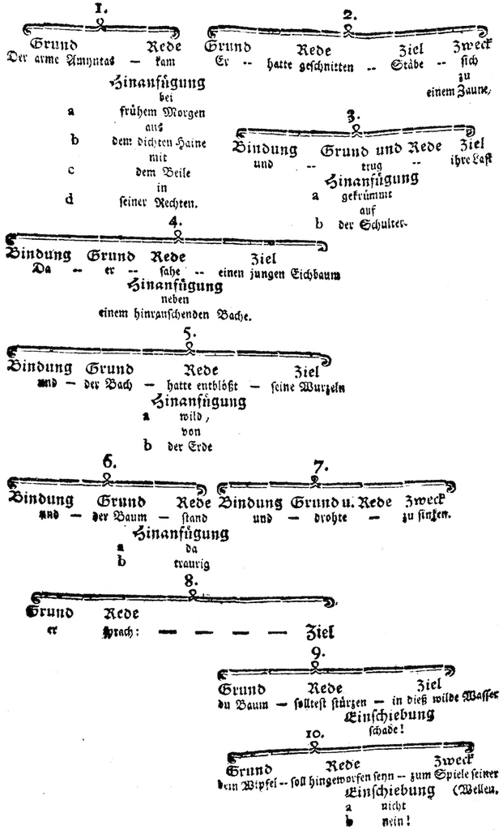

**Figure 2.1:** First page insert in *Deutsche Sprachlehre* (Moritz 1782: 308). Individual clauses are marked by a numbered bracket. Note the graphically lowered adjuncts (*Hinanfügung, Einschiebung*) and the subordinated direct speech clauses (clause 9 and 10). [**[Hi-Res image]**](https://cysouw.github.io/graphicalgrammar/figures/moritz1782_308i_full.jpg)

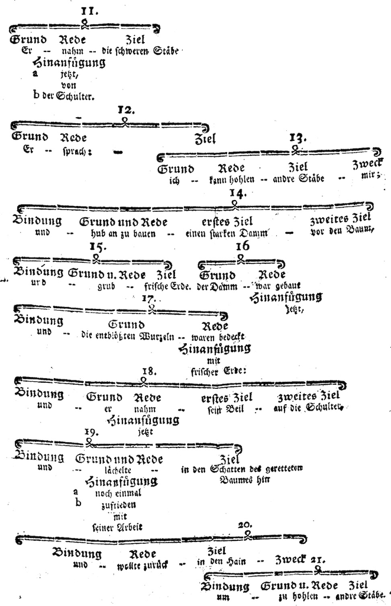

**Figure 2.2:** Second page insert in *Deutsche Sprachlehre* (Moritz 1782: 308). Note another example of a subordinated direct speech (clause 13) and a subordinated adverbial *um zu+Infinitiv* clause (clause 21). [**[Hi-Res image]**](https://cysouw.github.io/graphicalgrammar/figures/moritz1782_308ii_full.jpg)

[2.9] Examining the details of this visual display, each clause can be identified by a large bracket. Within each clausal bracket there is a table-like structure with function-names on top and the actual words of the clause below. Each clause consists of *Grund* (“subject”) and *Rede* (“predicate”), with possibly additional syntactic functions like *Ziel* (“accusative object”), *Zweck* (“dative object”) or *Bindung* (“conjunction”). Optional elements like *Hinanfügung* (“adverbial phrase”) and *Einschiebung* (“interjection”) are placed loosely below the main syntactic functions, implicitly hinting at an argument/adjunct distinction. Various details are not completely thought through and the examples are sometimes slightly inconsistent. For example, the phrase *von der Schulter* in clause 11 is analysed as an adverbial *Hinanfügung*, while the completely parallel phrase *auf die Schulter* in clause 18 is analysed as an object-like *zweites Ziel*.

[2.10] More interesting is the treatment of subordinate clauses. Subordinate clauses are given a function in the matrix clause and then are further analysed within a new bracket as a separate clause below. This can be seen in Figure 2.2 with the analysis of direct speech in clause 13, which is the *Ziel* of the matrix clause 12. Likewise, the adverbial *um zu+Infinitiv* subordinate clause 21 is the *Zweck* of the matrix clause 20.

[2.11] This display of subordinate clauses is no coincidence. In the text there is an explicit discussion of this analysis of subordinate clauses (Moritz 1782: 299-300) based on the example sentence (2.1). This sentence is analysed by Moritz into four separate clauses. The four clauses and their functions in the superordinate clause are listed in (2.1 a-d), as shown in Figure 2.3. Each of these subordinate clauses is subsequently analysed using the same clausal analysis structure as the superordinate clause, as can be seen in Figure 2.4.

| (2.1) | Wenn ich meine Pflicht thue, so fühle ich, daß mir dieses genug ist, um vergnügt und glücklich zu sein. |  |
| --- | --- | --- |
|  | a. | Grund und Rede: *so fühle ich* |
|  | b. | Ziel: *daß mir dieses genug ist* |
|  | c. | Zweck: *um vergnügt und glücklich zu sein* |
|  | d. | Hinanfügung: *wenn ich meine Pflicht thue* |

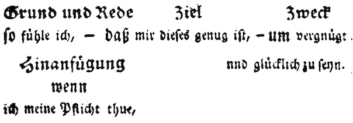

**Figure 2.3:** Complex sentence with syntactic functions assigned to subordinate clauses, from *Deutsche Sprachlehre* (Moritz 1782: 299). [**[Hi-Res image]**](https://cysouw.github.io/graphicalgrammar/figures/moritz1782_299_full.jpg)

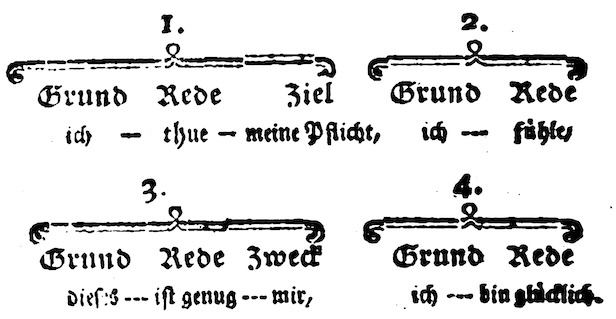

**Figure 2.4:** Separate analyses of the subordinate clauses of the complex sentence in (2.1) from *Deutsche Sprachlehre* (Moritz 1782: 300). [**[Hi-Res image]**](https://cysouw.github.io/graphicalgrammar/figures/moritz1782_300_full.jpg)

[2.12] Nitpicking one might argue that this analysis of the complex sentence is not completely correct. Clause 2 from Figure 2.4 is not a separate clause but the superordinate clause itself. Further, The subordinate part *um vergnügt und glücklich zu sein* is analysed in Figure 2.3 as *Zweck* (‘reason’, confusingly a label otherwise also used for dative arguments by Moritz). However, this clause is not directly subordinate to the main clause *so fühle ich* but it is secondary subordinate to the *Ziel* complement clause *daß mir dieses genug ist*.

[2.13] Notwithstanding these inaccuracies, Moritz’ analysis shows a clear understanding of subordinate clauses having simultaneously an internal functional structure and, as a whole clause, having a function inside a superordinate structure. Anachronistically interpreting this as a constituency analysis, this sentence can be displayed as shown in Figure 2.5. Note that this is somewhat akin to an “underlying” structure as the ordering does not correspond to the original sentence. Moritz consistently applies the same functional structure on each clause (viz. the ordering *Grund-Rede-Ziel-Zweck-Hinanfügung*). The numbering in this example indicates the eventual ordering in the resulting sentence.

[figure not shown]

**Figure 2.5:** Constituency tree of the example in (2.1) following the analysis from Moritz (Moritz 1782: 299-300). Note the fixed ordering of the functional categories in each clause, making this a kind of “underlying” structure. The bracketed numbers indicate the ordering in the actual example.

[2.14] Summarising, Moritz appears to have a clear understanding of, first, phrases as the basis of syntactic analysis. Second, he assigns a syntactic function to each phrase. Third, his examples indicate a basic, through rather implicit, understanding of adjuncts as less crucial phrases (*Hinanfügung*) that are visually displayed below the main constituents. Fourth, subordinate clauses have their own clausal structure, while the subordinate as a whole is assigned a function in the superordinate clause, which is a clear precursor of constituency structure. Finally, in the text he explicitly mentions that the ordering of the elements in the actual sentence is slightly different from the ordering in his analyses, and he hints at rules that determine how the abstract “underlying” structure has to be reordered into the actual form.

[2.15] All these theoretical concepts are quite charmingly summarised by his graphical display, which can be interpreted as a kind of precursor of a constituency structure. Apparently appearing completely out of the blue, the idea of using graphics to elucidate grammatical structure is off to a great start with these proposals from Moritz’ *Deutsche Sprachlehre*. Unfortunately, his approach does not have had any following and it would take almost 50 years for graphical methods to be used again for grammatical analysis, by Diesterweg in 1830 (see Section 2.3.1).

### 2.2.2 Herling (1823) *Periodenbau der deutschen Sprache*

[2.16] Simon Heinrich Adolf Herling (1780-1849) was a teacher in Frankfurt am Main and founding member, and later main organiser, of the *Frankfurter Gelehrtenverein für deutsche Sprache*. His analysis of multi-clause sentences is widely considered foundational for the grammatical analysis of German. A wide-ranging appraisal of Herling’s work can be found in Elmentaler (1996). Herling is a close friend and colleague to Ferdinand Becker (see Section 2.2.5), who is also an active member of the *Frankfurter Gelehrtenvereion*. A plan to write a joint grammar fell apart, indicating different opinions in their approach to grammatical analysis (Haselbach 1966: 69). Their relation remains amicable, as indicated by the fact that the first part of Herling’s *Syntax der deutschen Sprache* (Herling 1830) is dedicated to Becker.

[2.17] Strictly speaking, the work of Herling does not include any graphical display of grammatical analysis. However, his work is still included here because he introduces some notation that will be expanded upon graphically by later authors, especially Lehmann (see Section 2.3.3) and Götzinger (see Section 2.3.4). Herling’s notational framework is first introduced in the *Grundregeln des deutschen Stils oder der Periodenbau der deutschen Sprache. Ein Lehrbuch für den stilistischen Unterricht* (Herling 1823), which later becomes the second part of *Die Syntax der deutschen Sprache* (second edition 1827, third edition 1832).

[2.18] In his book Herling analyses the different ways a *Periode* is constructed from multiple clauses. In a short note inserted in small font inside the main text, Herling proposes a special notation *um die Umformungen kürzer zu bezeichnen, und so leichter überschauen zu können* ‘to succinctly mark the transformations and thus be able to survey them more easily’ (Herling 1823: 177). The usage of the term *Umformung* deserves it’s own discussion, which will not be pursued here. The special notation is summarised slightly clearer in the second and third edition (e.g. Herling 1832: 232, see also 177). The version from the third edition is shown here in the Figure 2.6, which can be translated as follows:

> For the succinct marking of the sentences and their syntactic relationships may the following symbols be of use: *h* indicates grammatical main sentence; *b* adjective clause, *β*, when it is shortened; *a* adverbial clause, *α*, the same shortened; *s* nominal clause, *σ* the same shortened. The exponents, e.g. *a<sup>2</sup>* indicate the grammatical grade, to *h* e.g. *h<sup>2</sup>* the grade of the logical gradation; *h/2*, *h/3*, indicates that the main clause, or *a/2*, *a/3* that the adverbial clause is separated into two or three parts. The coefficients e.g. *2h* indicate the number of equivalent main clauses; with *a*, *b*, *s* their relationship to the main clauses, often their coordination. (Herling 1832: 232)

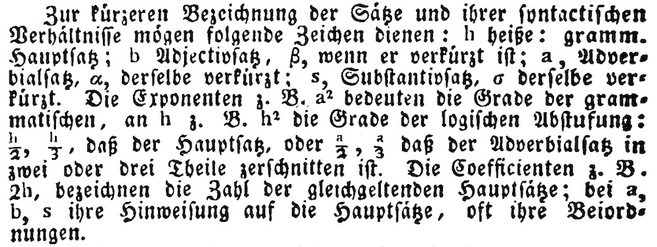

**Figure 2.6:** Notation of Herling (1832: 232) for the analysis of subordinate clauses in complex sentence structure. The different letters have a grammatical meaning, with *h* for main clauses, *b* for relative clauses, *a* for adverbial clauses and *s* for nominal clauses. Superscript numbers are used for the depth of the embedding. [**[Hi-Res image]**](https://cysouw.github.io/graphicalgrammar/figures/herling1832_232_full.jpg)

[2.19] Herling does not use his notations consistently throughout his book. There are only a few incidental examples and there are almost no sentences completely marked according to his system. The example in (2.2) is one of the more interesting and complex cases (Herling 1832: 233). Yet, in contrast to intended purpose, the abstract analysis with letters and numbers, interspersed inside the sentence, does not really ease the quick appraisal of the sentence structure, in my opinion.

(2.2)

Um (α) dem Soldatenstande zu entgehen, gegen den (b<sup>2</sup>) er, ungeachtet (α<sup>3</sup>) seinen unternehmenden Geistes und kräftigen Körpers, entschiedene Abneigung fühlte, verdingte er sich, (1h) im sechszehnten Jahre, bei einem Gastwirthe an der Gränze als Fuhrknecht, und (2h) kehrte erst nach sieben Jahren, da (2a) eben in seinem Geburtsorte ein nicht ganz unbedeutendes Grundstück feil geboten ward, in die Heimath zurück. (Herling 1832: 233)

[2.20] Anachronistically interpreting Herling’s analysis in modern terms, his symbols can be seen as a constituency structure. All clauses in the complex sentence are given a label and are related to each other in a hierarchical fashion, distinguishing coordination (viz. number in front) from subordination (viz. special letters for different kinds of embedding and superscript numbers to indicate deeper levels of embedding). Crucially, the clauses are linked to each other without using specific words as anchor points, like they would be in a dependency structure (cf. Becker’s sentence analysis of a complex sentence, see Section 2.2.5). Figure 2.7 shows an interpretation of Herling’s analysis from (2.2) in the form of a constituency tree.

[figure not shown]

**Figure 2.7:** Constituency tree illustrating Herling’s analysis (Herling 1832: 233) of the example in (2.2) using a modern visualization. Crucially, the clauses are linked to each other without attaching them to any specific words as would be the case in a dependency structure.

[2.21] The analysis of the complex sentence remains a topic of Herling’s subsequent work. Noteworthy in the current context is a note to the teachers at the end of the *Erster Cursus eines wissenschaftlichen Unterrichtes in der deutschen Sprache für Deutsche, nach einer neuen auf die Bildungsgesetze der Sprachen gegründeten Methode* (Herling 1828). This book does not have any graphics in the main text. However, completely at the end, in the Appendix *Bemerkungen und Erläuterungen für den Lehrer* (Herling 1828: 311-367), he mentions the symbolic analysis using letters as discussed above (Herling 1828: 365-366). And then, as a cherry on top, he proposes to use the well-known graphical display of musical notation to illustrate the structure of complex sentences, as shown in Figure 2.8. Herling does not seem to have taken this idea further, only Diesterweg did (see Section 2.3.1). Unfortunately, this innovative proposal appears to have disappeared after that.

(2.3)

So lange der Mensch nicht reden konnte, so sah, hörte, fühlte und schmeckte er bloß; aber er dachte nicht. So langue der Mensch nicht schreiben konnte, dachte er wenig, und redete schlecht. Die Zunge und der Griffel machten endlich den Menschen zu dem, was er werden sollte. Seine Begriffe wurden hell, indem er sie mitzutheilen suchte; sie wurden methodisch, indem er ihnen eine gewisse Fortdauer gab, die sie der Verbesserung, und Ausbildung fähig machte. Und dieser Weg, den das ganze menschliche Geschlecht nahm, um klüger zu werden, ist auch immer noch der einzige für den einzelnen Menschen. (Herling 1828: 305-306, uncredited quotation from J.J. Engel (1775) *Der Philosoph für die Welt*, Siebzehntes Stück *Das Weihnachtsgeschenk*)

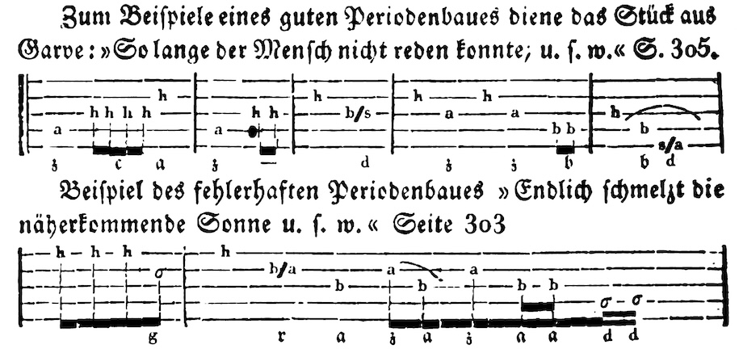

**Figure 2.8:** Musical notation used to illustrate the grammatical structure of whole paragraphs. Main clauses (indicated by *h*) are higher up, subordinate clauses are lower. Different sentences are separated by bar lines (Herling 1828: 366). [**[Hi-Res image]**](https://cysouw.github.io/graphicalgrammar/figures/herling1828_366_full.jpg)

### 2.2.3 Götzinger (1827) *Deutsche Sprachlehre*

[2.23] Maximilian Wilhelm Götzinger (1799–1856) was a teacher of German, most of his life working in Schaffhausen (Switzerland). He wrote extensively about grammar, literature and dialectology, see Olsson (2009) for an comprehensive appraisal of his work. Besides his didactic writings, Götzinger also provided material for Grimm’s dictionary project (Olsson 2009: 37) and he was even awarded a doctorate *honoris causa* from the University of Basel in 1838 (Olsson 2009: 36), probably through his personal contact with Wilhelm Wackernagel (the father of Jacob Wackernagel of *Wackernagel’s law*-fame).

[2.24] Götzinger wrote two didactic grammatical textbooks, both of which appeared in many different editions throughout the 19th Century (see Olsson 2009: 42-46 for a list of all editions). The book *Die Anfangsgründe der deutschen Sprachlehre in Regeln und Aufgaben* was first published in Leipzig in 1825. This was followed in quick succession by the *Deutsche Sprachlehre für Schulen*, first published in 1827 in Aarau. He also wrote a much more interesting book in 1836, which will be discussed separately (see Section 2.3.4).

[2.25] There is a curious graphic in the first edition of the *Deutsche Sprachlehre für Schulen* (Götzinger 1827: 263), reproduced here in Figure 2.9 from the second edition because of the higher quality of the scan (Götzinger 1830: 263). The graphic indicates the *Hebung* ‘raising’ and *Senkung* ‘lowering’ of the voice at the various *Glieder* of a *Periode*, so this is not a graphical display of syntactic structure. For example, the example sentence in (2.4) illustrates the option *Viergliedrig*, in this case probably intended to show a case with three rising *Glieder* and a final falling one.

[output not shown]

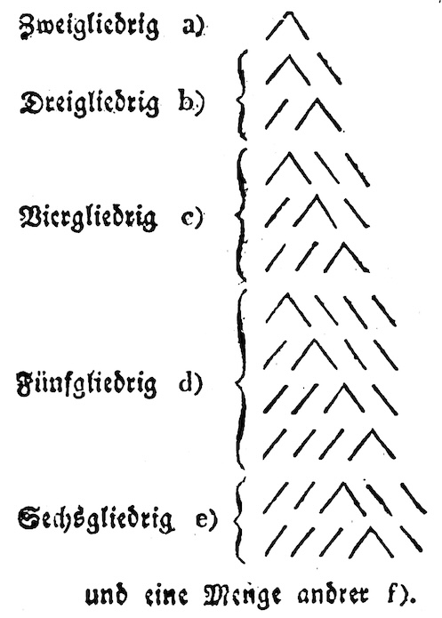

### 2.2.4 Schmitthenner (1828) *Teutonia*

[2.26] Friedrich Jakob Schmitthenner (1796-1850) was school director and later professor for history and organisation of state at the university of Gießen. He also wrote various books about German grammar and was part of the *Frankfurtischer Gelehrtenverein für deutsche Sprache*, alongside Herling (Section 2.2.2) and Becker (Section 2.2.5).

[2.27] In his 1828 book *Teutonia. Ausführliche Sprachlehre nach neuer wissenschaftlicher Begründung. II. Buch. Höhere Sprachlehre* Schmitthenner includes a graphic for the *Periode* (Figure 2.10). This graphic is very similar to Götzinger’s graphic (see Section 2.2.3), though it is unclear whether there is any direct influence. Like Götzinger, Schmitthenner explains that in his graphic the up and down strokes are supposed to indicate rising (*Hebung*) and falling (*Senkung*) intonation, and not syntactic structure. (Schmitthenner 1828: 185)

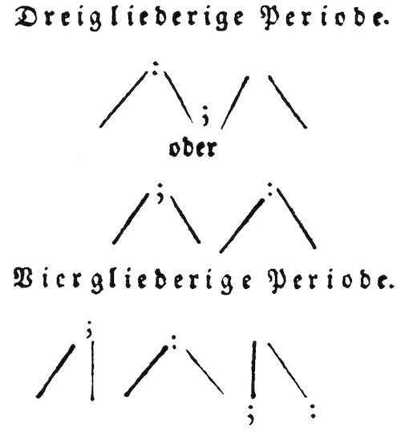

**Figure 2.10:** Intonation contours for multi-clause extended sentences, the so-called *Periode* (Schmitthenner 1828: 186). According to Schmitthenner, a *Periode* consists of multiple *Glieder*, the *Glieder* consist of *Abschnitte*, and each *Abschnitt* seems to be an individual sentence. The lines in the graphic indicate *Abschnitte* (with rising or falling intonation), the *Glieder* are separated by colons or semicolons. For example, the last example has six *Abschnitte* and four *Glieder*. Differently from Götzinger in Figure 2.9, for Schmitthenner a *Periode* can have multiple intonation maxima. It remains unclear from the text whether there is an intended difference between slanted and vertical lines. [**[Hi-Res image]**](https://cysouw.github.io/graphicalgrammar/figures/schmitthenner1828_186_full.jpg)

### 2.2.5 Becker (1829) *Deutsche Grammatik*

[2.28] Karl Ferdinand Becker (1775-1849) was probably one of the most influential grammatical educators from the start of the 19th Century. He originally started out as a medical doctor, but that turned out not be a financial success. Instead, he started to make a living by teaching German to English-speaking students. Turning his attention to linguistics, he wrote various books about German grammar. For a thorough repraisal of Becker’s linguistic work, see Haselbach (1966). Becker also became a member of the *Frankfurter Gelehrtenverein für deutsche Sprache*, where he met Herling (see Section 2.2.2) and Schmitthenner (see Section 2.2.4).

[2.29] In his *Organism der Sprache als Einleitung zur deutschen Grammatik* (Becker 1827) Becker presents a clear plan for analysis of syntactic relationships inside the sentence (which he called *Satzverhältnisse*), and it is easily possible to anachronistically depict these ideas graphically (e.g. Haselbach 1966: 156-161). However, Becker himself never produced any graphical display of the analysis of a specific sentence, but he came very close with a tabular method of analysis.

[2.30] Becker orginaly introduced a few examples of his tabular method in the preface of the *Deutsche Grammatik* (Becker 1829). Here he presents a few examples of how sentences should be analysed, calling the process *Analyse der Sätze* (Becker 1829: xvi-xix). This explanation is addressed to teachers, instructing them how students should approach the analysis of a sentence. Astonishingly, he never describes this analytical approach in the grammar itself. He returns to this approach in a short book *Über die Methode des Unterrichtes in der deutschen Sprache*, again directed to teachers (Becker 1833: 36-46). In this book he calls the process *Zergliederung*.

[2.31] Becker’s basic idea is to use a table with all words of the sentence listed as the rows of a table. This approach feels completely natural in the English grammatical tradition of “parsing”, which he might have encountered while teaching English-speaking students. In the English grammatical tradition, parsing has a long history. The English word itself originates from the Latin *pars orationis*, i.e. originally parsing is the process to assign parts of speech to individual words. The Oxford English Dictionary lists examples of this usage all the way back to the 16th Century. However, the process of consistently going through a sentence, listing all words separately, and analysing each one individually, seems to have been first used by John Brinsly the Elder in his *Ludus Literarius* from 1612 (nice examples in Brinsley 1612: 102, 130). In the centuries since, this approach to parsing became a mainstay in the English grammatical tradition (Lyman 1922: 120-122). Curiously, this approach to sentence analysis seems to have been basically unknown outside of the English-speaking grammatical tradition.

[2.32] An example of Becker’s table is shown in Figure 2.11, analysing the example sentence in (2.5). The crucial innovation of Becker is the addition of numbers to each row of the table, an approach never before and never since used in the English tradition. Becker uses these numbers to clarify the relationships between the words, as for each word he adds the number to the word it modifies at the end of each row in the table.

| (2.5) | Wallenstein wußte längst den Inhalt ihrer Sendung als die Abgesandten des Kaisers ihm vor die Augen traten. |
| --- | --- |

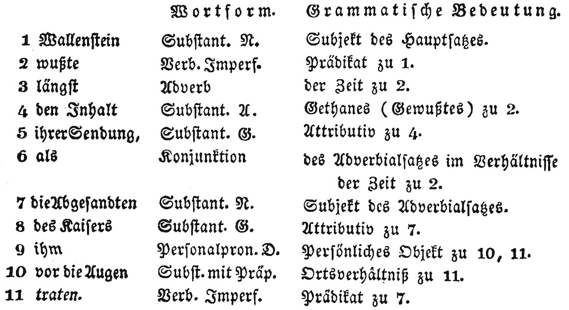

**Figure 2.11:** Tabular analysis of the sentence in (2.5) from the preface of Becker (1829: xvii). The crucial innovation of this “parsing” table is the addition of line-numbers at the start of each row, which allows for a reference to the head of each row (given at the end of each row after *zu*). This format is almost completely identical to the CoNNL-U format for dependency trees, which is widely used today, almost 200 years later. A dependency tree for this table is shown in Figure 2.12. [**[Hi-Res image]**](https://cysouw.github.io/graphicalgrammar/figures/becker1829_xvii_full.jpg)

[2.33] The format of the table is actually almost completely identical to the modern CoNLL-U table-format<sup>2</sup> https://universaldependencies.org/format.html of for dependency trees. In that format all words are listed in a tab-delimeted file, with minimally five columns: (i) a numerical ID, (ii) the linguistic elemens, (iii) the word class, (iv) the relation to the head, and (v) the number of the head it modifies. The resulting dependency tree is shown in Figure 2.12. The file to reproduce this tree is linked at the end of the caption, and is almost verbatim the table from Becker’s book of 1829.

[figure not shown]

**Figure 2.12:** Dependency tree of (2.5) on the basis of the tabular analysis by Becker as shown in Figure 2.11. This dependency tree is generated by using the CoNLL-U format (code linked at the end), which is almost a verbatim copy of the tabular analysis by Becker. Note that in this analysis, the subject is head of the verb, while the verb is the head of the other elemenst in the sentence. [**[Code]**](https://cysouw.github.io/graphicalgrammar/figures/becker1829_xvii_tree.txt)

[2.34] A more extensive description of this tabular method is given in Becker (1833: 38-46), using the Term *Zergliederung*. From the exposition in that book the impression arises that Becker considered this kind of analysis the basis of all grammatical education. He argues how important it is to practice this *Zergliederung* with students, and that all other aspects of the grammar can be better explained and understood when they are able to perform such a *Zergliederung*. It remains completely unclear why this method is only presented in texts adressed for the teachers, and never in the actual grammar books.

[2.35] A final example of such a *Zergliederung* is presented in Figure 2.13 for the sentence in (2.6). This example is interesting because it contains various subordinated clauses. However, the method is easily extended to deal with such complex sentences. I leave it as an exercise for the reader to turn this table into the CoNLL-U format and generate a dependency tree.

[2.36] In summary, the grammatical writings of Becker have had a lot of influence in the 19th Century, but his very practical idea of a numbered tabular analysis has unfortunately not been widely acknowledged. Diesterweg used it, but those proposals also did not have a large impact (see Section 2.3.1).

[output not shown]

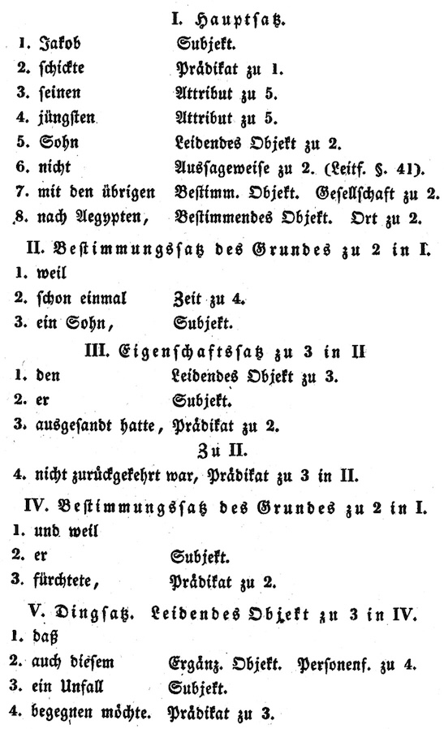

**Figure 2.13:** Tabular analysis from Becker (1833: 43) of the complex sentence (2.6) with various subordinate clauses, . The term *Eigenschaftssatz* is used for relative clauses, *Bestimmungssatz* for adverbial clauses and *Dingsatz* for complement clauses. [**[Hi-Res image]**](https://cysouw.github.io/graphicalgrammar/figures/becker1833_43_full.jpg)

## 2.3 *Periodenbild* and *Satzbild*

### 2.3.1 Diesterweg (1830) *Praktischer Lehrgang für den Unterricht*

[2.37] Freidrich Adolph Wilhelm Diesterweg (1790-1866) was a teacher and a prolific author of textbooks. He also wrote extensively about didactic methods in general, strongly influenced by the ideas of Pestalozzi. Later in life he was politically active in an attempt to reform the Prussian educational system. His practical textbooks mainly dealt with mathematics and German linguistics. A comprehensive analysis of his linguistic work can be found in Czoska (1984). His linguistic proposals did not have much influence on the further development of syntactic analysis, which is unfortunate, because there are a lot of useful insights hidden there.

[2.38] The *Praktischer Lehrgang für den Unterricht in der deutschen Sprache* is a massive three-volume guide for teachers. As it says in the subtitle, it is *ein Leitfaden für Lehrer, welche die Muttersprache naturgemäß lehren wollen* (‘a guide for teachers who want to teach the mother tongue in a natural way’). In the current context I will concentrate on the second volume *Die Wortformen und die Satzlehre*. This second volume first appeared in 1830 (Diesterweg 1830), but there have been some important changes in the second edition from 1834 (Diesterweg 1834). The third edition from 1838 (Diesterweg 1838) and the fourth from 1847 only saw minor changes. I will cite the 1830 and 1834 version where appropriate, but often include references to the 1838 version as well, as this is the highest-quality openly available digital version. For that reasons I have also used the 1838 for the images included here, as they do not change from the 1830 or 1834 versions.

[2.39] In the preface to the second edition from 1834, Diesterweg calls his approach *Elementarmethode* ‘elementary method’ (a clear nod to Pestalozzi), in opposition to the *wissenschaftliche oder die constructive Methode* ‘scientific or constructive method’ (Diesterweg 1834: xii-xiii). As examples of the scientific method he explicitly cites Herling, Becker, Götzinger and Schmitthenner, all of which he deems inappropriate for secondary education. However, the subsequent proposals Diesterweg makes in his book are all clearly inspired by these authors.

[2.40] In the first edition from 1830, Diesterweg includes a graphical represenation of the intonation contour of a *Periode*, following Götzinger (Section 2.2.3) and Schmitthenner (Section 2.2.4), shown here in Figure 2.14 (Diesterweg 1830: 191), shown here in the version from the third edition (Diesterweg 1838: 169). Diesterweg proposes a consistent uses of punctuation marks, with semicolons for sequences of *Beiordung* and colons for the main intonation maximum. With this analysis, Diesterweg follows the approach from Götzinger that each *Periode* has a single maximum.

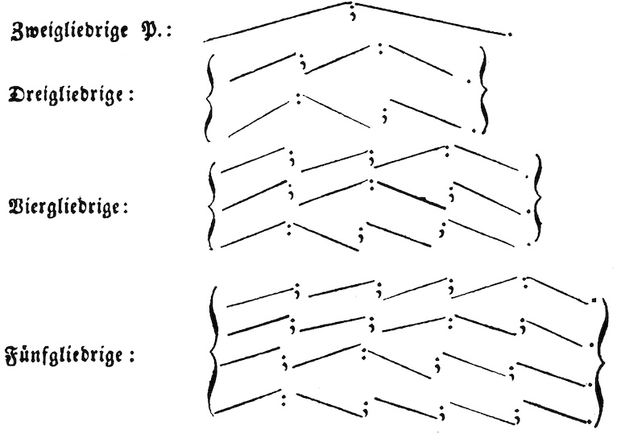

**Figure 2.14:** The rhythmical structure of the *Periode* (Diesterweg 1830: 191; Diesterweg 1838: 169), clearly inspired by Götzinger and Schmitthenner. The structure is actually closest to Götzinger as shown in Figure 2.9, because for Diesterweg each *Periode* only has a single intonation maximum, which is indicated by the colon between two slanted lines. The semicolons are always linking a *Beiordnung* and were originally accompanied by a horizontal line (Diesterweg 1830: 191). When the horizontal lines were removed in later editions (e.g. Diesterweg 1838: 169 shown here), the same structure as found in Götzinger (1827: 263) is obtained. [**[Hi-Res image]**](https://cysouw.github.io/graphicalgrammar/figures/diesterweg1838_169_full.jpg)

[2.41] In the 1830 edition Diesterweg also proposes a notation for subordinated clauses (using a raised star: *) and coordinated clauses (using a the typographic dagger: †). Deeper embedded clauses are marked by repeating these symbols (Diesterweg 1830: 188-190). These symbols are placed at the start of each clause, resulting in examples like (2.7), somewhat reminiscent of the use of letters in (2.2) by Herling.

(2.7)

Nicht, * um dir einen neuen Beweis meiner zärtlichen Sehnsucht zu geben, *† sondern um feurige Kohlen auf dein feindseliges Haupt zu sammeln, schreibe ich dir noch eineml, † und zwar aus dieser berühmten Handelsstadt (Leipzig), * welche durch ihre Messen ganz Deutschland mit Waaren aller Art versorgt, *† und deren Name gleich berühmt ist durch die Leckerbissen, ** die sie den Reichen, *† wie durch Schätze der Gelehrsamkeit, ** die sie den Gebildeten liefert. (Diesterweg 1830: 189)

[2.42] In the 1834 edition Diesterweg replaces these symbolic visualisations with letter sequences based on the proposals by Herling (see Section 2.2.2) and Lehmann (see Section 2.3.3). He introduces capital letters for main clauses and lower-case letters for subordinate clauses like Lehmann (1833) using the superscript numbers for ‘deeper’ subordinations like Herling Herling (1823). However, Diesterweg ignores the meaning of the different letters as proposed by Herling, similar to Lehmann (1833). Also, he ignores Lehmann’s use of horizontal braces, replacing them with simple commas. The resulting sequence of letters is called *Satzbild* by Diesterweg (1834: 163, 170), which is the first occurence of this term. However, at another page he uses the term *Periodenbild* with the same meaning (Diesterweg 1834: 168-169). This term was first used by Lehmann (1833).

[2.43] Additionally, Diesterweg combines the letter sequences with the graphical representation of the intonation contour (Diesterweg 1834: 162-163; Diesterweg 1838: 164-165). And as an alternative representation, Diesterweg also proposes to use the music-score diagram from Herling (1828). Both visualisations are shown in Figure 2.15 (Diesterweg 1834: 169; Diesterweg 1838: 171) illustrating the example sentence in (2.8). Just like Diesterweg, I leave it as an exercise to the reader to follow along with the analysis in the figure.

(2.8)

Wenn der Mensch allein auf der Erde steht, und alle Herzen, die ihn liebten, in ihr und unter ihr ausgeschlagen haben, und in dem Gewühle der Menge, die ohne Rast nach ihrem Ziele drängt, keiner bei ihm verweilen will; wenn sein Schmerz einsam auf seinem harten Lager stöhnt, und keine Stimme ihm antwortet, als der herzlose Wiederhall; wenn sein thränenloses, glühendes Auge umsonst ein anderes sucht, und seine starre Hand nach einer andern greift, und die Kälte der Menschen ihn noch empfindlicher quält, als die Kälte des Winters in seiner düsteren Kammer: so ist doch in diesem Jammer, den so Viele jammern, noch eines, welches die Dornen des Schmerzes zerdrückt; do ist doch ein Auge, das liebend auf ihm ruht, und eine Hand, die ihn von seinem Strohlager aufrichtet. (Diesterweg 1834: 169, citing an example from Friedrich Jacobs)

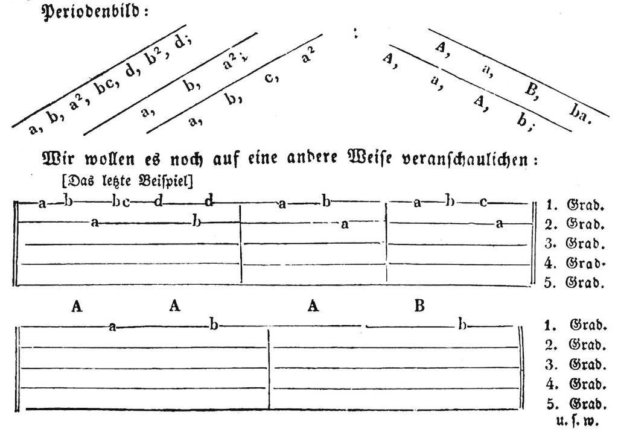

**Figure 2.15:** Revised visualisation of the *Periode* from Diesterweg (1834: 169), exemplified by an analysis of the example sentence in (2.8). The visualisation is based on proposals from Herling (Section 2.2.2) and Lehmann (Section 2.3.3). First, the intonation contour (on top) is further specified by letter sequences (called *Satzbild* or *Periodenbild* by Diesterweg), which are a blend of the abbreviations used by Herling (1823) and Lehmann (1833). Second, as an alternative display, Diesterweg uses the music score approach similar to the proposal by Herling (1828). [**[Hi-Res image]**](https://cysouw.github.io/graphicalgrammar/figures/diesterweg1834_169_full.jpg)

[2.44] But Diesterweg is not yet finished. He also proposes a syntactic analysis based on the ideas of Becker (see Section 2.2.5). Diesterweg uses an intricate graphical analysis of clause internal structure for *ausgebildete Sätze*, as shown in Figure 2.16 (Diesterweg 1830: 174, 266; Diesterweg 1838: 158, 260). He uses the distinction between *nackte* ‘naked’ and *ausgebildete* ‘developed’ sentences here, which was widespread at the time. The question about the internal structure of a sentence only arises with *ausgebildete* ‘developed’ sentences, i.e. with sentences that have additional material other than a bare subject and predicate.

[2.45] Diesterweg uses braces, both horizontal and vertical, to indicate groups of words in developed sentences. It is tempting to compare this graphical approach using braces with the analysis of Moritz (see Section 2.2.1). However, there is no indication that there has been any direct influence of Moritz on Diesterweg. It seems more plausible that the use of braces is a parallel development, because large braces is simply one of the few graphical tricks that were available for typesetting at the time.

[2.46] Diesterweg does not employ syntactic diagrams with lines, because he restricts line diagrams to the illustration of hierarchical subdivision of grammatical categories, e.g differentiating kinds of plurals (Diesterweg 1838: 8), kinds of nouns (Diesterweg 1838: 22-23) or kinds of adjectives (Diesterweg 1838: 53), and many more such examples through the book. In contrast, a sentence is not an example of hierarchical subdivision, but an example of hierarchical modification, which Diesterweg calls *Bestimmung*. It seems plausible that Diesterweg quite consciously avoided the usage of the same visualisation for these two different applications.

[2.47] The visual analysis with braces, which Diesterweg calls *Zergliederung* and sometimes *Analyse* (following Becker 1829: 16) includes various crucial syntactic details. Many of these details are not explained; Diesterweg simply claims that well-taught pupils should be able to follow along with the analysis of the complex sentence (2.9) as illustrated with the graphic in Figure 2.16.

> Sind die Schüler bis hieher [sic] gründlich unterrichtet worden; so müssen sie im Stande sein, den nachfolgenden Satz, wie folgt, zu zergliedern und wieder zusammenzusetzen. (Diesterweg 1830: 174; 1838: 158)

> (‘When the pupils have been taught thoroughly up to here, then they should be able to parse and assemble again the following sentence, as follows.’)

[output not shown]

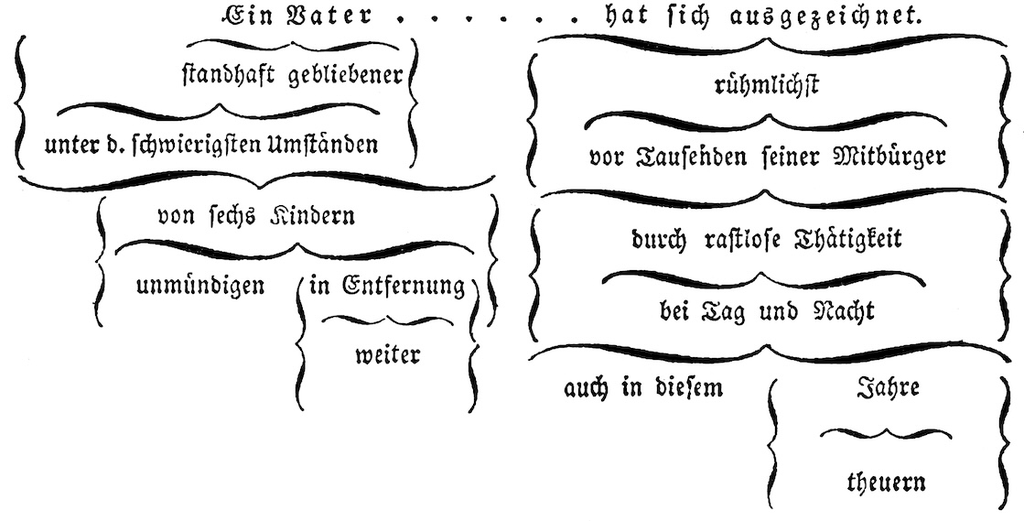

**Figure 2.16:** Syntactic analysis by diagram of the sentence in (2.9) from Diesterweg (1830: 174; 1838: 158). The “naked” sentence with only subject and predicate is positioned on top, linked by a dotted line. Horizontal braces indicate modification by other words, with the part below the brace being the *Bestimmer* ‘determiner’ of the word on top. Vertical braces indicate “constituent” grouping. The single reversed horizontal brace on the mid left also indicates a grouping, possibly considered too large for another set of hierarchically positioned vertical braces. [**[Hi-Res image]**](https://cysouw.github.io/graphicalgrammar/figures/diesterweg1830_174_full.jpg)

[2.48] Diesterweg’s visual analysis of (2.9), as shown in Figure 2.16, contains various important syntactic details that have to be inferred from closely inspecting the display:

- The analysis has a subject-predicate basis, as indicated by the dots at the top, linking the subject *Ein Vater* to the predicate *hat sich ausgezeichnet*. This is called the *nackter Satz* by Diesterweg.
- On the predicate side (to the right), the various adverbial modifiers are simply stacked downwards using horizontal braces, with the actual ordering in the sentence being from bottom to top. Notice the difference in size of the braces, which is meaningful. In contrast, the vertical braces on the right side indicate constituent subgrouping.
- On the subject side (to the left), we also see horizontal braces to indicate modification and vertical braces to indicate grouping. The horizontal braces seem to point towards the head they modify, though this positioning is not always completely accurate.
- On the subject side (to the left) there is also a single reversed horizontal brace to indicate modification to the whole first part of the noun phrase up to the head noun *Vater*. It would have been more consistent to use large vertical braces, then the hierarchical structure would have become obvious.
- There are various small negligent errors, both in the image (the word *lebenden* is omitted) and in the explaining text (where the phrase *unter fremden Menschen* is added).

[2.49] Diesterweg returns to this syntactic analysis at the end of the book (Diesterweg 1830: part 3, chapter nine; Diesterweg 1834: part 3, chapter ten) under the heading *Die grammatische Zergliederung der Sätze* (Diesterweg 1830: 263). He first repeats the previously used analysis using braces, but then turns his attention to sentences containing (multiple) subordinate clauses. Without any comment he omits the bracketed analysis and turns to a table-style analysis with numbered words and cross-references, exactly like Becker (see Section 2.2.5). Diesterweg probably noticed that the bracketed visualisation becomes exceedingly complex and confusing with more elaborated sentences. However, from his seemless switch between bracketed visualisation and numbered tables it becomes clear that these two approaches are interchangeable in his mind. It is just a matter of practical applicability which system to use in a particular example.

[2.50] Finally, there are two interesting terminological issues addressed by Diesterweg. First, he prefers the term *Ausbildung* over the widespread term *Erweiterung*, which is actually still an extremely common grammatical term in Germany today.

> Man hat die ausbildung des Satzes auch erweiterung desselben genannt. Es ist Erweiterung, in so fern mehr Wörter hinzutreten, als der Satz länger wird. Es ist dies eine grammatische Erweiterung. Da aber die näher bestimmten Wörter eine engere Begriffssphäre erhalten, so ist es eine logische Verengerung. Deshalb wird das Wort erweiterung besser vermieden. (Diesterweg 1830: 167; 1834: 151)

> (‘The development (*Ausbildung*) of a sentence is also called expansion (*Erweiterung*). It is an expansion because more words are added, and the sentence will become longer. So it is a grammatical expansion. However, because the modified words obtain a more narrow meaning, it is a logical narrowing. Therefore, the word expansion (*Erweiterung*) is better avoided.’)

[2.51] Second, throughout the discussion of syntax, Diesterweg frequently uses the nomen agentis *Bestimmer* ‘determiner’ for a word that modifies another. This appears to be a quite practical term, but unfortunately this terminological quirk has not caught on.

> Die Ausbildung geschieht durch nähere Bestimmung der einzelnen Satztheile. Wir wollen diese Wörter, welche die Hauptsatztheile näher bestimmen, überhaupt bestimmer nennen. (Diesterweg 1830: 167; 1834: 151)

> (‘The development (*Ausbildung*) happens by modification (*Bestimmung*) of the individual parts of the clause. In general, we will call such words, that further modify parts of the main clause, modifiers (*Bestimmer*).’)

[2.52] In summary, the grammatical analysis of Diesterweg is a complex tour-de-force, combining insights from various scholars of the preceding decade, synthesising everything into a coherent and visually appealing package. Additionally, he attempts to make the grammatical analysis practically useful for application in the classroom. Many ideas proposed in his book feel rather modern and might have kickstarted a fruitful dicussion about syntactic analysis. Unfortunately, Diesterweg’s *Lehrgang* does not seem to have had much impact on the further development of linguistics in general, nor specifically on the establishment of linguistic education. From here on, the development of grammatical analysis in Germany will proceed taking baby steps, instead of leaping ahead like Diesterweg demonstrated to be possible.

### 2.3.2 Billroth (1832) *Lateinische Syntax*

[2.53] At the end of his short life, Johann Gustav Willhelm Billroth (1808-1836) became professor for religion at the university in Halle. Before that, between his *Habilitation* in Leipzig in 1830 and the start of his position in Halle in 1834, he worked as a teacher for latin (Alwast 2000). In that context he wrote two latin grammars for use in schools, first the *Lateinische Syntax für die obern Klassen gelehrter Schulen* (Billroth 1832), later followed by the *Lateinische Schulgrammatik für alle Klassen* (Billroth 1834).

[2.54] In these grammars there is a single graphical display of a grammatical structure, shown below in Figure 2.17 (Billroth 1832: 102). There is not much known about the grammatical background of Billroth, nor is there any explicit indication in his books about the inspiration for drawing a grammatical analysis. As he was active as a school teachter, he might very well have been aware of Becker (1829, see Section 2.2.5) or Diesterweg (1830, see Section 2.3.1), both of which might be inspiration for Billroth’s graphical display. One (minor) argument that Billroth was inspired by Diesterweg is that Billroth uses the term *bestimmter Satz* as an alternative to *bekleideter Satz* (Billroth 1832: 97), and the noun *Bestimmung* in the meaning of modifier (Billroth 1832: 126-127). Diesterweg very extensively used the nound *Bestimmung* but also *Bestimmer*, which is not found in Billroth. It is possible that Billroth just used these words out of his own inspiration, but the usage is idiosyncrativ enough to be notewhorthy.

[2.55] In Billroth’s syntax, the whole discussion of the structure of the sentence takes 11 pages (Billroth 1832: 91-102). The structure of the text is really difficult to follow, although on closer inspection there is a clear, but drawn-out organisation. First, he introduces the simple ‘naked’ sentence as option *A*:

> Ein Satz ist entweder: A. ein einfacher (oder nackter) d.h. ein solcher, welcher bloß aus Subject, Prädicat und Copula besteht. (Billroth 1832: 91)

> (‘A sentence is either: A. a simple (or naked) one i.e. one such that it only consists of subject, predicate and copula.’)

> B. oder ein bestimmter (bekleideter) d.h. ein solcher, wo entweder ein einzelner Theil oder mehrere durch Zusätze näher bestimmt werden. (Billroth 1832: 97)

> (‘B. or a determined (dressed) one, i.e. one such, in which either a single part or multiple parts are further determined by additions.’)

[2.57] Then it takes another 5 pages of explanations of different kinds of such “dressed” sentences until finally this topic is closed with the conclusion quoted below. Billroth simply states (without explanation) that the example sentence (2.10) is ‘dressed’ as illustrated in Figure 2.17. In this quote, Billroth takes the metaphor of the naked/dressed sentence even one step further by using the term *Körper* ‘body’ for the naked sentence.

> Auf diese Weise wird z.B. folgender Satz (2.10), dessen Körper eigentlich nur aus dem Subj.: *Miltiades* und dem Prädicat (mit dem Copula) *reddidit* besteht, bekleidet: (Billroth 1832: 102)

> (‘In this way, the following sentence, whose body only consists of the subject *Miltiades* and the predicate (with copula) *reddidit*, is dressed:’)

| (2.10) | Miltiades, dux Atheniensium, toti Graeciae libertatem paene oppressam in pugna apud Marathonem reddidit. |
| --- | --- |

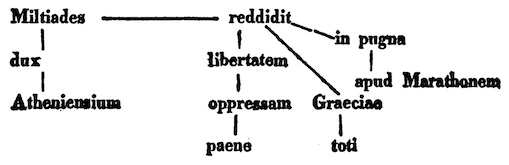

**Figure 2.17:** Graphical sentence analysis of (2.10) from Billroth (1832: 102). Note the horizontal depiction of the subject-predicate pairing and all modifiers hanging down from them. This structure is rather similar to Diesterweg’s Figure 2.16, but the usage of lines instead of braces is different. [**[Hi-Res image]**](https://cysouw.github.io/graphicalgrammar/figures/billroth1832_102_full.jpg)

[2.58] Interpreting his graphical illustration in more detail, the naked sentence is depicted by a horizonal line, while the additional elements of the “dressed” sentence are all shown as vertical/slanted lines. Billroth very clearly intends the vertical lines to represent some kind of dependency, with multiple levels of modification being illustrated by subsequent vertical lines. The structure of the graphic is quite similar to Diesterwegs proposal in Figure 2.16, but with lines instead of curly braces.

[2.59] Exactly the same approach with the same picture is found in his extended grammar written two years later (Billroth 1834: 332-333). After Billroth’s early death this grammar has seen various new editions. The second edition of 1838 is prepared by Friedrich Ellendt and uses exactly the same figure (Billroth 1838: 329). However, in the third edition, the picture is changed, erroneously, and has become completely incomprehensible, cf. Figure 2.18 (Billroth 1848: 358). Ellendt possibly did not completely understand what the figure is supposed to represent.

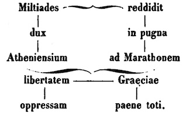

**Figure 2.18:** Revision of the graphical analysis in Figure 2.17 from the 1848 revision on the auspices of Friedrich Ellendt (Billroth 1848: 358). Instead of lines there are braces, and the structure of the braces is completely incomprehensible and in places clearly wrong. [**[Hi-Res image]**](https://cysouw.github.io/graphicalgrammar/figures/billroth1848_358_full.jpg)

[2.60] Billroth’s grammar has an interesting afterlife, but unfortunately without any further development of his graphical innovation. Friedrich Ellendt writes a different grammer for younger students based on Billroth’s model, called *Lateinische Grammatik für die unteren Klassen der Gymnasien*. The discussion of *bekleidete oder erweitete Sätze* is very similar to Billroth’s, but it has different examples and it does not have a picture anymore (Ellendt 1838: 115-116). After the death of Ellendt, that grammar is in turn adapted by Moritz Seyffert as *Dr. Friedrich Ellendt’s Lateinische Grammatik für die unteren und mittleren Klassen der höheren Unterrichtsanstalten*. This grammar has seen very many revisions, editions and reprints under the heading *Ellendt-Seyfferts lateinische Grammatik* far into the 20th Century. However, Seyffert was not very impressed by the syntactical analysis of Billroth (as noted in the preface of his revision), and he rewrote the discussion of syntax wholesale.

[2.61] On a more positive note, Billroth’s grammar had a direct influence on Julius Hoffmann (see Section 2.3.5), and Hoffmann is quoted indirectly by Franz Kern (see Section 2.3.17). So it seems very plausible that Billroth’s line diagram was a seed that grew slowly but surely.

### 2.3.3 Lehmann (1833) *Allgemeiner Mechanismus des Periodenbaues*

[2.62] Johann August Otto Leopold Lehmann (1802-1883) worked as a teacher in Danzig (Gdańsk) and later as a school principal in Marienwerder (Kwidzyn). In this context, he prepared various educational textbooks, mainly consisting of literary commentaries, but also including songbooks, dialect analyses and some works on local history. Early in his career he wrote a linguistic treatise about the structure of the complex sentence: *Allgemeiner Mechanismus des Periodenbaues, nebst einem Versuche, an ihn eine Kritik der deutschen Periode anzuknüpfen* (Lehmann 1833). His approach to the analysis of complex sentences is based on the work of Herling (see Section 2.2.2), who is explicitly cited as a source of inspiration (Lehmann 1833: xv-xvi).

[2.63] In the title of his book, Lehmann uses the term *Periode*, which is a term also used by Herling. This term stems from the domain of rhetoric and roughly indicates a coherent and well-structured utterance. Continuing the tradition of Herling, Lehmann uses the term *Periode* to designate a complex sentence that consists of multiple clauses. Herling introduced symbolic abbreviations for different kinds of clauses (see Section 2.2.2), but Lehmann takes this a step further and proposes a comprehensive visualization of the structure of a complex sentence, which he calls a *Periodenbild*.

> [Die] innere Anschauung der Periode soll als auf äußere Anschauung begründet dargestellt werden. Die äußere Anschauung aber findet ihr Objekt in Bildern, welche das Skelet der Perioden wiedergeben. Ich nenne dies Periodenskelet anschauungsbild der periode oder periodenbild schlechtweg. (Lehmann 1833: xiv)

> (‘The internal structure of the *Periode* will be depicted based on the outward appearance. The outward appearance shows itself as a picture, which reflects the skeleton of the *Periode*. I simply call this *Periode*-skeleton an image of the *Periode* or a *Periodenbild*.’)

[2.64] For the visualization of a *Periodenbild* Lehmann distinguishes three different kinds of subordination, indicated by different symbolic devices as shown in Figure 2.19 (Lehmann 1833: 58). These three notations basically indicate a subordinate position after (1), before (2) and internal (3) to the superordinate clause, respectively. More precisely,

- the first notation uses a horizontal brace, which indicates that the subordinate clause (below the brace) follows the superordinate clause (above the brace). This is called *Anfügung* or *Nachperiode*;
- the second notation uses a colon, which indicates that the subordinate clause (in front of the colon) is positioned before the main clause. This is called *Vordersatz*, *Vorderperiode* or *Vorausschickung*;
- the third notation uses round brackets, which indicates that the subordinate clause (inside the brackets) is positioned inside the superordinate clause. This is called an *Einschaltung*. The separated parts of the superordinate clause are indicated by repeating the same letter. Such repetitions of the same letter thus do not indicate multiple clauses, but separate parts of the same clause.

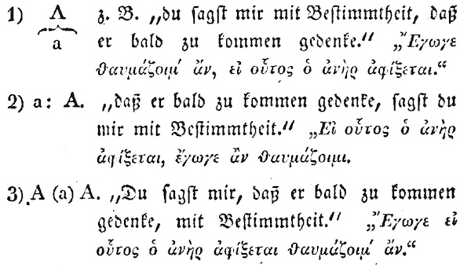

**Figure 2.19:** Three basic structural mechanisms of subordination from Lehmann (1833: 58). The first (with a horizontal brace) indicated that the subordination follows the main clause; the second (with a colon) indicates that the subordination precedes the main clause; and the third (with round brackets) indicated that the subordination is positioned internal to the main clause. [**[Hi-Res image]**](https://cysouw.github.io/graphicalgrammar/figures/lehmann1833_58_full.jpg)

[2.65] At first glance it seems curious that there are completely different notation for the placement in front (colon) and the placement behind (horizontal brace). However, there is clear rationale for this difference arising from the structural possibilities of the German language (although this rationale is not explained by Lehmann in his book). The German main clause has a special initial position (today mostly called *Vorfeld*) that can contain a single subordinate clause. So each main clause can only have a single *Vordersatz*, which Lehmann indicates with the colon. Internal and final subordination can be recursively repeated.

[2.66] Lehmann’s book completely focusses on the analysis of complex sentences into their constituting clauses, using his graphical display to summarize the relationships between the clauses. There are hundreds of examples of different kinds of complex sentences discussed in his book, but there is not a single analysis of a clause-internal structure at all. He appears to be much more interested in the number of possible schemas that could exist, which are all *Umformungen* of a complex sentence. For example, he discusses an example of a particular schematic analysis (apparently without any real linguistic sentence in mind) that could theoretically have 37,632 *Umformungen* (Lehmann 1833: 116-118). Lehmann immediately notes *“Es wäre thöricht, bei dieser oder ähnlichen Perioden, die zu den Verwickeltsten gehören, all möglichen Veränderungen darzustellen.”* (‘It would be foolish for such or similar *Perioden*, that belong to the most complex ones, to illustrate all possible changes.’ Lehmann 1833: 116-118).

[2.67] Clauses are indicated by using letters, an approach that was also used by Herling (cf. Section 2.2.2). However, Lehmann has a completely different approach to the use of the letters. Lehmann is only interested in the relative ordering of the subordinated clauses and he completely ignores what kind of subordination is used. In contrast, Herling uses different letters for different grammatical kinds of subordinated clauses, for example *a* for adverbial clauses. When there are three adverbial clauses in a sentence, then they are all called *a* by Herling. The letters are thus indications of the grammatical kind of the clause. Lehmann instead uses a different letter for each subordinate clause, giving each clause an individual label, but omitting any indication of the internal structure.

[2.68] This difference between Herling and Lehmann also concerns the use of Greek letters. Herling uses greek letters for non-finite subordinate clauses (using *zu*-infinitive or participial verb forms in German), but Lehmann does not consider non-finite clauses at all. He uses greek letters for doubly-embedded subordinate clauses. In contrast, Herling uses numerical superscripts for multiple grades of embedding. Lehmann uses different kinds of scripts to distinguish multiple grades of embedding. He uses capital letters for main clauses, lower-case letters for subordinate clauses and greek letters for doubly-embedded clauses. Third-grade embedding uses Fraktur capital letters (e.g. 𝔄, 𝔅) and fourth-grade embedding uses Fraktur lower-case letter (e.g. 𝔞, 𝔟). There is even a short discussion of a fifth-grade embedding, which is indicated with numerals (Lehmann 1833: 232).

[2.69] In contrast to Herling, Lehmann’s approach thus ignores many apects of the grammatical analysis of a sentence. However, his focus on the relation between clauses allows him in return to tackle really complex sentences. Consider, for example, the long and complex sentence in (2.11), which is a sentence from Immanuel Kant’s *Anthropologie in pragmatischer Hinsicht* (Lehmann 1833: 125-126). The internal structure of this sentence is summarized by Lehmann with a relatively simple *Periodenbild* as shown in Figure 2.20.

(2.11)

Daß ferner, wenn es (das Kind) nun zu sprechen versucht, das Radbrechen der Wörter es für Mütter und Ammen so liebenswürdig macht, es beständig zu herzen und zu küssen und es auch wohl durch Erfüllung alles Wunsches und Willens zum kleinen Befehlshaber zu verziehn: diese Liebenswürdigkeit des Geschöpfs im Zeitraum seiner Entwicklung zur Menschheit, muß wohl auf Rechnung seiner Unschuld und Offenheit aller seiner noch fehlerhaften Aeußerungen, wobei noch kein Hehl und nichts Arges ist, einerseits, andrerseits aber auf den natürlichen Hang der Ammen zum Wohlthun an einem Geschöpf, welches einschmeichelnd sich der Willkür eines andern überläßt, geschrieben werden, da ihm eine Spielzeit eingewilligt wird, die glücklichste unter allen, wobei der Erzieher dadurch, daß er sich selber gleichsam zum Kinde macht, diese Annehmlichkeit nochmals genießt. (Lehmann 1833: 125-126, citing Immanuel Kant *Anthropologie in pragmatischer Hinsicht* 1798: 5)

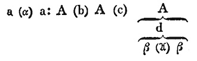

**Figure 2.20:** Lehmann’s (1833: 126) analysis of Kant’s sentence (2.11). The main clause is designated with a capital letter *A*, which is interrupted twice by subordinated clauses designated by lower-case letters, *b* and *c*. A further subordinated clause *a* comes before the main clause, and is itself interrupted by a second-order subordination designated by greek letter *α*. After the main clause there is yet another subordinated clause *d*, which is followed by a secondary embedding *β*, which is interrupted by a tertiary embedding indicated by a Fraktur capital letter *𝔄*. [**[Hi-Res image]**](https://cysouw.github.io/graphicalgrammar/figures/lehmann1833_126_full.jpg)

[2.70] The different clauses in Figure 2.20 are listed below, exactly as it is explained in the text by Lehmann:

- **main clause A:** [clause *a* preceding] *diese Liebenswürdigkeit des Geschöpfs im Zeitraum seiner Entwicklung zur Menschheit, muß wohl auf Rechnung seiner Unschuld und Offenheit aller seiner noch fehlerhaften Aeußerungen* [clause *b* internal] *einerseits, andrerseits aber auf den natürlichen Hang der Ammen zum Wohlthun an einem Geschöpf* [clause *c* internal] *geschrieben werden* [clause *d* following]
- **subordinate clause *a*, preceding *A*:** *daß ferner* [clause *α* internal] *das Radbrechen der Wörter es für Mütter und Ammen so liebenswürdig macht es beständig zu herzen und zu küssen und Willens zum kleinen Befehlshaber zu verziehen*
- **subordinate clause *b*, internal to *A*:** *wobei noch kein Hehl und nichts Arges ist*
- **subordinate clause *c*, internal to *A*:** *welches einschmeichelnd sich der Willkür eines andern überläßt*
- **subordinate clause *d*, following *A*:** *da ihm eine Spielzeit eingewilligt wird, die glücklichste unter allen* [clause *β* following]
- **secondary subordinate clause *α*, internal to *a*:** *wenn es (das Kind) nun zu sprechen versucht*
- **secondary subordinate clause *β*, following *d*:** *wobei der Erzieher dadurch* [clause *𝔄* internal] *diese Annehmlichkeit nochmals genießt*
- **tertiary subordinate clause *𝔄*, internal to *β*:** *daß er sich selber gleichsam zum Kinde macht*

[2.71] Although Lehmann’s book does not appear to have been reprinted after the first edition from 1833, it has influenced later more widely read works by Götzinger (see Section 2.3.4) and Bauer (see Section 2.3.8), whose graphical displays will be reprinted up to 1935. Götzinger’s acknowledgement indicates that Lehmann’s approach might have had some real influence in didactic circles, although it has not endured to the present day:

> *Die von Herrn Director Lehmann in Marienwerden zuerst aufgestellten Periodenbilder haben bei vielen Schulmännern Beifall und Anwendung gefunden, und es macht mir große Freude, durch meine Lehrbücher zur Verbreitung dieser Methode, deren Verdienst ganz allein Herrn Lehmann gebührt, beigetragen zu haben.* (Götzinger 1842: x, Vorrede zur fünften Auflage)

> (‘The *Periodenbilder*, first drawn by director Lehmann from Marienwerder, have been praised and employed by many Schoolmen, and I am delighted through my textbooks to have contributed to the wider circulation of this method, the credit to which completely befits Mr. Lehmann.’)

[2.72] Lehmann himself remained active and used his system in various later publications. First, he used it in *Goethe’s Sprache und ihr Geist* (Lehmann 1852: 152-180) to analyse sentences by Goethe, which includes very complex examples of his notation. Surprisingly, Lehmann is regularly quite critical of Goethe and uses his notation to argue for the imbalanced sentence structure, for example (2.12) as analysed in Figure 2.21.

> Schon das Bilde dieser Periode zeigt deren Uebelstände. Erstlich die große Masse der Sätze, zweitens der Mangel an Ebenmaß theils zwischen den koordinirten Hauptsätzen theils zwischen den koordinirten Nebensätzen, drittens die Vorherrschaft des Anfügungsgesetzes. (Lehmann 1852: 171-172)

> (‘Alreade the image of this *Periode* shows its foul nature. First, the large number of sentences, second the lack of balance, partly beteen the coordinated main clauses, partly between the coordinated subordinated clauses, third the dominance of the *Anfügungsgesetz*’)

(2.12)

Wilhelm hatte während der Zeit seiner Regie das ganze Geschäft mit einer gewissen Freiheit und Liberalität behandelt, vorzüglich auf die Sache gesehen und besonders bei Kleidungen, Dekorationen und Requisiten alles reichlich und anständig angeschafft, auch, um den guten Willen der Leute zu erhalten, ihrem Eigennutze geschmeichelt, da er ihnen durch edlere Motive nicht beikommen konnte; und er fand sich hierzu um so mehr berechtigt, als Serlo selbst keine Ansprüche machte, ein genauer Wirt zu sein, den Glanz seines Theaters gerne loben hörte und zufrieden war, wenn Aurelie, welche die ganze Haushaltung führte, nach Abzug aller Kosten versicherte, daß sie keine Schulden habe, und noch soviel hergab, als nötig war, die Schulden abzutragen, die Serlo unterdessen durch außerordentliche Freigebigkeit gegen seine Schönen und sonst etwa auf sich geladen haben mochte. (J.W. Goethe *Wilhelm Meisters Lehrjahre*)

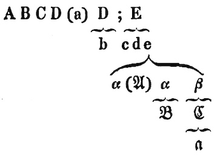

**Figure 2.21:** *Periodenbild* for the sentence in (2.12) from Goethe’s *Wilhelm Meisters Lehrjahre* as analysed by Lehmann (1852: 171-172). Lehmann is quite critical of the large size and the imbalance of the whole construction. [**[Hi-Res image]**](https://cysouw.github.io/graphicalgrammar/figures/lehmann1852_171_full.jpg)

[2.73] Later Lehmann writes *Sprachliche Studien über das Nibelungenlied* (Lehmann 1856; Lehmann 1857) in which he again uses his system to analyse classical German literature. In the introduction he cites Nägelsbach (Lehmann 1856: 4) and Götzinger (Lehmann 1856: 7) and follows Nägelsbach simplification to use a comma instead of the horizontal brace (Lehmann 1856: 8).

[2.74] These two examples of the application of the scheme on actual literary texts inspired many philological analyses in the decades to come. For example, via the *Repetitorium* of Menge (see Section 2.3.10) there is a direct line to the 1969 dissertation on the *Amadisroman* from Langholf (see Section 2.3.31) using similar graphical analyses as Lehmann.

### 2.3.4 Götzinger (1836) *Die deutsche Sprache*

[2.75] Maximilian Wilhelm Götzinger (1799–1856) was a teacher of German, most of his life working in Schaffhausen (Switzerland). He wrote extensively about grammar, literature and dialectology, see Olsson (2009) for an comprehensive appraisal of his work. Besides his didactic writings, Götzinger also provided material for Grimm’s dictionary project (Olsson 2009: 37) and he was even awarded a doctorate *honoris causa* from the University of Basel in 1838 (Olsson 2009: 36), probably through his personal contact with Wilhelm Wackernagel (the father of Jacob Wackernagel of *Wackernagel’s law*-fame).

[2.76] Götzinger’s early textbooks were already mentioned in Section 2.2.3, but these early books did not contain any graphical analyses of sentences. But then Götzinger discovered Lehmann’s *Periodenbau* (1833) and that changed everything. In 1835 Götzinger wrote a review of Lehmann’ book (Götzinger 1835b) and in the third edition of the *Sprachlehre* from 1835 he introduced Lehmann’s graphical displays. Götzinger cites the influence of Lehmann in the preface (Götzinger 1835a: xiii-xiv) and he applies Lehmann’s graphical analysis both to clause structure, under heading *Stellungen der Bekleidung* (Götzinger 1835a: 243-248), and to sentence structure, under the heading *Stellung der Nebensätze* (Götzinger 1835a: 310-315). Götzinger distinguishes these two applications of Lehmann’s analysis by using different names: *Satzbild* for clause structure and *Periodenbild* for larger sentence structures consisting of multiple clauses (Götzinger 1835a: 311).

[2.77] Contamporaneously to revising this textbook, Götzinger prepared his magnum opus *Die deutsche Sprache und ihre Literatur* (volume one 1836; volume two 1839). This book also includes many graphical analyses inspired by the *Periodenbilder* from Lehmann (see Section 2.3.3). In this book, Götzinger does not explicitly cite Lehmann as his inspiration for the graphical display, but he mentions Lehmann’s *vortreffliches Buch* (‘excellent book’) in a different context (Götzinger 1839: 217). I will use these two volumes of *Die deutsche Sprache* to summarise Götzinger’s interpretation of Lehmann’s approach.

[2.78] There are two main differences between Lehmann and Götzinger. First, Götzinger simplifies Lehmann’s quite elaborate use of different character set. Lehmann uses latin, greek, and fraktur letters, in upper- and lower-case, with different meanings. Götzinger only uses latin capitals for main clauses and latin lower-case letters for subordinate clauses. Second, Lehmann originally used his graphical method only for main and subordinated clauses (*Periode*), but Götzinger argues that the same principle of subordination (*Unterordnung*) can be used for other kinds of linguistic structure as well. Consequently, Götzinger uses Lehmann’s notation also for (i) syllabic structure, (ii) clause-internal structure and (iii) clause subordination.

> Auf diese Weiße ordnet die Sprache bei allen Vorgängen den jedesmaligen Stoff so, daß ein Theil desselben als untergeordnet erscheint, in der Silbe die Laute, im Worte die Silben, im Satze die Worte, in der Periode die Sätze. (Götzinger 1836: 15)

> (‘Accordingly, language arranges the particular content in all occurrences in such a way that one part of it appears as subordinated: with syllables the sounds, with words the syllables, with clauses the words, with sentences the clauses.’)

[2.79] First, for the analysis of the syllable, Götzinger (1836: 221-224) uses the capital letter for the vowel as the centre of the syllable (*Träger und Mittelpunkt der Silbe*) and lower-case letters for the consontants as dependent on the vowel (*erscheint stets als untergeordnet*). As long as the syllabic structure is according to the sonority hierarchy (*musikalisches Gesetz*), it can be described as (multiple) prefixal and suffixal subordinations, as illustrated in Figure 2.22. Extrasyllabic initial *s* and affricate codas *ps*, *tsch* and *chs* are illustrated with different structures not shown here (Götzinger 1836: 224).

> In der Regel findet bei der Gliederung der Silbe durch fortschreitende Unterordnung der Elemente ein Schwellen und Sinken, ein Steigen und Fallen, ein Crescendo und Decrescendo statt; d.h. die Silbe fängt mit dem lautlosesten Element an, geht zu dem tönenenden über, gelangt zur eigentlichen Stimme, und geht nun denselben Weg wieder abwärts, so daß mithin in jeder auf diese Weiße gebaute Silbe ein völlig musikalisisches Gesetz statt findet. (Götzinger 1836: 222)

> (‘Normally, the arrangement of the syllable consists, by repeated subordination of the elements, of swelling and sinking, of rising and falling, of crescendo and decrescendo; i.e. the syllable starts with the most silent element, proceeds to the more sounding one, reaches the principal voice, and then follows the same path downwards again in such a way that each such constructed syllable obeys a completely musical law.’)

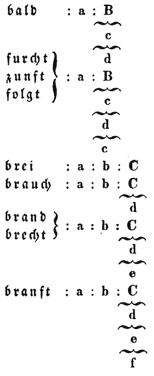

**Figure 2.22:** Syllables with a structure in accordance to the sonority hierarchy (Götzinger 1836: 223) have a vowel as nucleus (capital letter) and possibly multiple ‘subordinate’ consonants in the onset (lower-case letters separated horizontally with colons) and the coda (lower-case letters separated vertically with braces). [**[Hi-Res image]**](https://cysouw.github.io/graphicalgrammar/figures/götzinger1836_223_full.jpg)

[2.80] Second, for the analysis of the internal structure of a clause Götzinger proposes to use the same notation (Götzinger 1839: 159-162), which he calls *Satzbilder* (Götzinger 1839: 161). A few examples are shown in Figure 2.23. The capital letter now refers to the verb and the lower-case letters refer to the constituents. Götzinger calls the lower-cased elements *Bekleidung*. Today a German grammar would call them *Satzglied*. The German main clause structure with two verb positions is indicated by a repeated capital letter, called *trennbare Zusammensetzung* by Götzinger (1839: 160). Similar terminology can still be found in contemporaneous German grammars.

> Mag also die Stellung der Bekleidung in jenem Satze seyn, wie sie will, immer wird nur das Bild entstehen [mit einer Voraussendung]. Niemals kann die Folge vorkommen [mit mehreren Voraussendungen]. (Götzinger 1839: 162)

> (‘Although the position of the constituents in the sentence can be as it chooses, the resulting image will always have a single *Vorraussendung*. The ordering with multiple *Voraussendungen* cannot occur.’)

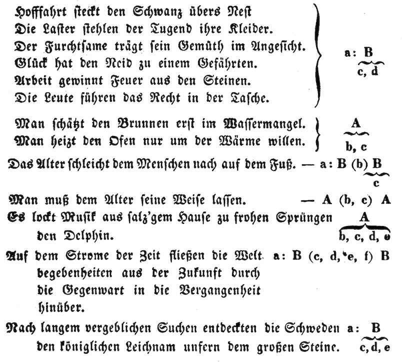

**Figure 2.23:** Main clause analysis from Götzinger (1839: 161) using the same notation as for syllables. In modern grammatical terminology: the main verb is indicated by the capital letter, possibly two times in case of a separated verb. Other *Satzglieder* are indicated by lower-case letters. The *Vorfeld* is separated by a colon. The *Mittelfeld* is put between round brackets, with multiple constituents separated by commas. The *Nachfeld* is indicated below the horizontal brace, again with commas separating mulitple constituents. [**[Hi-Res image]**](https://cysouw.github.io/graphicalgrammar/figures/götzinger1839_161_full.jpg)

[2.82] Third, for the analysis of the multi-clause sentence Götzinger again uses the same notation. He separates the analysis of basic subordination (Götzinger 1839: 364-367) from the analysis of the *Periode* (Götzinger 1839: 374-403). This distinction is not very clear, as he comments that *der Begriff periode ist etwas schwankender Natur* ‘the concept of the *Periode* has somewhat of a wavering nature’. He introduces the equal sign for coordination (Götzinger 1839: 366). A slighly complex *Periodenbild* is shown in Figure 2.24 for an example sentence (2.13) from Goethe.

| (2.13) | Wenn ich mich in einer mittleren oder großen Stadt umsehe und bemerke, wo denn die Menschen sich hinwenden, um ihren Abend zuzubringen: so findet sich immer, daß man dahin gehe, wo man grüßend begrüßt… |
| --- | --- |

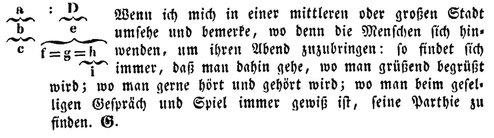

### 2.3.5 Hoffmann (1839) *Neuhochdeutsche Schulgrammatik*

[2.83] Karl August Julius Hoffmann (1812-1869)

[2.84] https://de.wikipedia.org/wiki/Julius_Hoffmann_(Pädagoge)

[2.85] *Schulgrammatik* is the more extensive work, *Elementargrammatik* is sort-of a summary. contains the same image (Hoffmann 1856: 80, 109) (fourth edition, first edition not digitally available)

[2.86] Schulgrammatik: (Hoffmann 1839)

[2.87] “Unter den Grammatiken der fremden Sprachen verdanke ich der Lateinischen von Billroth am meisten.” (p. xiii)

[2.88] nackter und umkleideter Satz 146-148

[2.89] complex sentence p. 224

[2.90] second edition (Hoffmann 1853), basic example the same, on p. 137

[2.91] extended complex sentence on page 216-217

[2.92] new: discussion of *Periode* p. 240: (use of letters like Lehmann)

> Von Perioden kann man Bilder entwerfen, indem man die Hauptsätze mit A B C, die Nebensätze ersten Grades mit a b c, die Nebensätze zweiten Grades mit α β ɣ, die Nebensätze dritten Grades mit 𝔞 𝔟 𝔠 bezeichnet. So ist z.B. das Schema der eben unter Nr. 5 aufgeführten Periode folgendes: [ A a α A b β : B c. ]

(2.14)

Es ist für denjenigen, der mit sich selbst noch nicht recht eins geworden ist, was er denn eigentlich suche und wolle, äußerst beängstigend, wenn er auf seinem Wege auf Sätze stößt, die allen seinen bisherigen Meinungen und den Meinungen seiner Zeitgenossen und der Vorwelt widersprechen: und gewiß ist diese Ängstlichkeit eine der Hauptursachen, warum die Menschheit auf dem Wege zur Wahrheit so langsame Forstschritte gemacht hat. (Hoffmann 1853: 239, citing Fichte)

[2.93] Neuhochdeutsche Elementargrammatik mit Rücksicht auf die Grundsätze der historischen Grammatik

6. Auflage 1865 https://www.digitale-sammlungen.de/view/bsb10583851?page=5 images: https://www.digitale-sammlungen.de/view/bsb10583851?page=194

[2.94] Kern cites Hoffmann (Kern 1888), but only in the second edition after he already published his “tree” metaphors. The idea for the “trees” is already in “Satzlehre”, finished in December 1882, and practically applied in “Methodik” of 1883.

### 2.3.6 Nägelsbach (1846) *Lateinische Stilistik*

[2.95] Carl Friedrich Nägelsbach (1806-1859)

[2.96] graphical *Periode* citing Lehmann (Nägelsbach 1846: 281ff.)

### 2.3.7 Fürg (1847) *Satz und Styllehre*

[2.97] Johann Baptist Fürg (1802-1863) teacher in München

[2.98] fourth edition, unclear first edition. Numbered tables like becker (Fürg 1847: vi-viii)

### 2.3.8 Bauer (1850) *Neuhochdeutsche Grammatik*

[2.99] Friedrich Bauer (1812-1874) studied theology and was the founding director of a missionary education centre in the Bavarian city of Neuendettelsau. This institute is still active today as *Mission EineWelt*. Among other duties, Bauer also taught religion and German grammar at his institute (Fuchshuber-Weiß 2013: 93). In that context he wrote the *Grundzüge der neuhochdeutschen Grammatik für die unteren und mittleren Klassen höherer Bildungsanstalten*, which was first published in 1850. Bauer himself delivered various editions of this book up to his death in 1874.

[2.100] summary of many editions in (Fuchshuber-Weiß 2013: 128-131)

[2.101] After Bauer’s death, the German dictionary maker Konrad Duden kept producing new editions of this grammar with only very minor changes. The *Neuhochdeutsche Grammatik* remained popular and has seen at least 27 editions, including special editions for Austria, for protestant schools and for catholic schools. The last edition was published in 1912 (Fuchshuber-Weiß 2013: 115-117, 128-131). However, even that was not the end, as Bauer’s text was given a second life. In the century since the death of Konrad Duden in 1911, Duden’s dictionary became a household name in Germany for everything related to the German language. In 1935, under the auspice of Otto Basler, the 11th Edition of the Duden dictionary was expanded with a German grammar (Basler 1935), which was basically a new edition of Bauer’s *Neuhochdeutsche Grammatik*, which still includes the graphical analysis (without clear attribution to Bauer). Only after the Second World War was the grammar completely rewritten and new editions of that new Duden grammar are still popular today. The graphical display was removed from this rewritten Duden grammar.

[2.102] (Bauer knew Hoffmann’s grammar, (Fuchshuber-Weiß 2013: 99))

[2.103] In the grammatical analysis of complex sentences, Bauer (1850: 94-97) uses a graphical display in the tradition of Lehmann (see Section 2.3.3), although he does not explicitly cite him (Maybe Bauer got it from Götzinger?). The first similarity is that Bauer’s analysis only deals with the relation between main and subordinate clauses, not clause-internal structure. Second, and most telling, Bauer follows Lehmann’s convention to use capital letters for main sentences and lower-case letters for subordinate sentences. And finally, after a few pages of examples, Bauer comments, almost as an afterthought, that this analysis is called periode, a clear implicit reference to Lehmann (and his inspiration, Herling (1823)).

> *Die künstmäßige Gliederung mehrerer Sätze in beigeordneter oder untergeordneter Verbindung zu einem ganzen heißt man Periode* (‘The artful arrangement of multiple sentences in coordinate or subordinate juncture into a whole is called *Periode*,’ Bauer 1850: 97, translation MC).

[2.104] Term “Satzbild” not in first edition of 1850, but introduced later, at least in sixth edition (Bauer 1863)

[2.105] The first few basic examples of Bauer’s syntactic analysis are shown in Figure 2.25 (Bauer 1850: 95). These examples are also found in exactly the same layout 85 years later in Basler (1935: 254). Each sentence is analyzed in two ways: the text itself is subdivided into clauses, with subordinate clauses shifted down vertically and connected with lines (is this inspired by Hoffmann?). Additionally, there are structural analyses in the form of letters, with capital letters for main clauses and lower-case letters for subordinate clauses. First-level subordination is separated by a comma, while secondary or deeper subordination is indicated by vertical lines (and sometimes numerical superscripts). The vertical arrangement is clearly borrowed from Lehmann (although Bauer leaves out the horizontal brace from Lehmann), but the superscripts indicate that Bauer also took notice of Herling’s notation (cf. Section 2.2.2).

[2.106] Different lower-case letters, just like Herling, though the letters are different! (Bauer 1850: 94). “verkürzte” subordinate clauses have dashes -a-, -b-, -c-, but he later notes that this is supposed to be a strikethrough (Bauer 1863: footnote on p. 145)

- Substantivsatz: a
- Adjectivsatz: b
- Adverbialsatz: c

[2.107] This analysis is rather similar to a constituency analysis with the abstract letters indicating the node labels and the clauses being the leaves. Specifically, subordination is not linked to an explicit superordinate word (i.e. to a head as in a dependency analysis), but to a superordinate abstract entity.

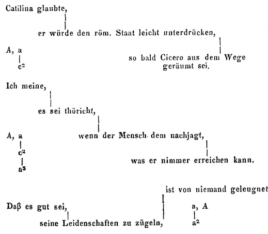

**Figure 2.25:** Basic examples of Bauer’s sentence analysis (Bauer 1850: 95). There are three sentences analyzed in this excerpt, with subordination structure indicated by vertical lines and the structural patterns to the side, summarized with letters. [**[Hi-Res image]**](https://cysouw.github.io/graphicalgrammar/figures/bauer1850_95_full.jpg)

[2.108] A more complex example discussed by Bauer is the sentence (2.15), analyzed as Figure 2.26 (Bauer 1850: 97). Again, there is both an analysis of all main and subordinate clauses, written out with subordination marked by vertical lines, and there is a structural pattern with letters and symbols in the bottom right. This structural pattern has two cases of coordination (marked by a plus symbol), an internal subordination (marked by the brackets), a secondary subordination (marked by a vertical line) and a subordination at the end of the sentence (marked by a comma). I have attempted to combine both these analysis into a single constituency tree as shown in Figure 2.27. The structural pattern has been used as the node-labels, while the text itself are the leaves in the tree. Probably it would have been more accurate to analyze the subordination *c* as a simple frontal embedding of the second conjunct, using a comma in the analysis instead of brackets for a clause-internal embedding (viz. *A+c,A,a+a* instead of *A+A(c)A,a+a*), but that is some minor nitpicking.

| (2.15) | Er schenkte ihr 300 Rubel und als er erfuhr, daß sie in Petersburg einen Vetter habe, stellte er ihre frei, ob sie ihre Reise fortsetzen oder ob sie umkehren wolle. (Bauer 1850: 97) |
| --- | --- |

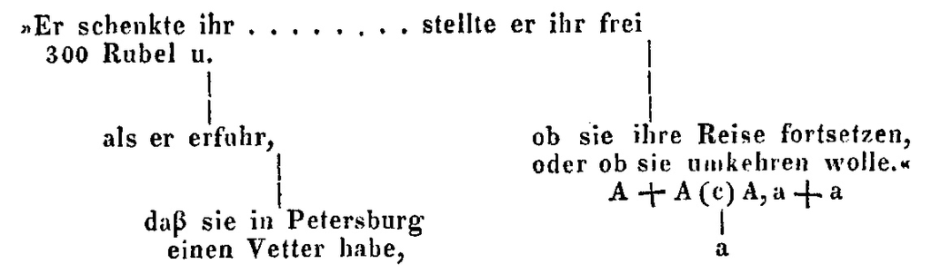

**Figure 2.26:** Analysis of the complex example in (2.15) from Bauer (1850: 97). Note both the use of vertical lines for subordination and the separate abstract analysis with symbols in the bottom right. [**[Hi-Res image]**](https://cysouw.github.io/graphicalgrammar/figures/bauer1850_97_full.jpg)

[figure not shown]

**Figure 2.27:** Display of the structure combining the text from example (2.15) and the structural letter-analysis from Figure 2.26 into a contemporary-style constituency tree.

[2.109] Expansion of notation at least since the 6th edition (Bauer 1863: 144-150)

- Beigeordnete Sätze: A + A
- Beigeordnete Sätze ohne Conjunct: A [+] A
- Beigeordnete Sätze mit gepaarten Conjunctionen: + A + A
- Gegengeordnete Sätze: A x A
- Gegengeordnete Sätze ohne Conjunct: A [x] A
- Causale begründete beigeordnete Sätze (*denn*): A < A
- Causale folgernde beigeordnete Sätze (*daher*): A > A
- Nebengeordnete Sätze: Ā
- Gleichgeordnete Sätze: Ā̄

[2.110] In this edition he also promises to write a more extensive explanation of his notation, but he never seems to have done this.

> Es ergeben sich die manchfaltigsten Gestalten von Sätzen von der einfachsten Schreibart an bis zur compliciertesten. Die Darstellung solcher Satzbilder durch Formeln ist äußert lehrreich und förderlich, sowohl für das Verständnis scherer Sätze, als für das Schreiben. […] Solche Formeln zur Darstellung von Satzbildern zu geben, muß sich der Verfaßer vorbehalten für eine besondere kleine Schrift, welche eine Ergänzung der Syntax für eine höhere Lehrstufe bilden soll. (Bauer 1863: 128)

### 2.3.9 Wetzel & Wetzel (1865) *Die deutsche Sprache*

[2.111] Periode like Lehmann, §194-195, cited here in the 3rd edition (Wetzel & Wetzel 1871: 312-316)

[2.112] Almost identical, just a bit shorter and streamlined, in *Leitfaden*, first edition 1868 (Wetzel & Wetzel 1868: 182), also in the 46th edition (Wetzel & Wetzel 1871: 223-224)

### 2.3.10 Menge (1873) *Repetitorium der lateinischen Syntax und Stilistik*

[2.113] Hermann August Menge (1841-1939), teacher and translator of the infamous *Menge-Bibel*. Based on his practical teaching experience, he wrote textbooks for Latin and Greek. The Latin textbook is still in use today, though in a slightly revised version (e.g. a 1955 edition is cited in Langholf 1969: 10).

[2.114] Lehmann Periode in §541-542, cited here in the 6th edition (Menge 1890: 357-364). In the preface to the first edition he cites among others Hoffmann (but not Nägelsbach), and the other preface do not mention any changes as far as the Periode is concerned, so it is very probable that the Period analysis was already present in the first edition of 1873.

### 2.3.11 Gelbe (1877) *Deutsche Sprachlehre*

[2.115] Theodor Gelbe (1837-1892), Realschuldirektor in Stollberg. Satzbild like Götzinger (Gelbe 1877: 150-153) historical survey of satzbilder (Gelbe 1880)

### 2.3.12 Diringer (1878) *Die Periode oder der Gliedersatz*

[2.116] Josef Diringer (1878-1883) Ordinarius für Deutsch, Latein und Griechisch in Eichstätt

[2.117] practical application in second half of the book (Diringer 1878: 42-60) using separate lines for subordination, like music notation

[2.118] Further development of *Periodenbild* citing Bauer, Lehmann and Götzinger (and Becker, Herling, but there does not seem to be any links as for the graphics)

### 2.3.13 Esser (1878) *Die Formen der Periode*

[2.119] Franz Esser (Oberlehrer Gymnasium Weissenburg) citing Götzinger, but using dashes instead of horizontal braces (Esser 1878)

### 2.3.14 Sanders (1879) *Deutsche Sprachbriefe*

[2.120] Daniel Sanders (1819-1897) https://de.wikipedia.org/wiki/Daniel_Sanders_(Lexikograf)

[2.121] Satzbild (Sanders 1879) Periode: 228 and various more

### 2.3.15 Blatz (1880) *Neuhochdeutsche Grammatik*

[2.122] Satzbilder (Blatz 1880: 866-871) in Introduction mentions Becker, Sanders

### 2.3.16 Zettel (1882) *Unterricht in der deutschen Sprache*

[2.123] Karl Zettel (1831-1904), Gymnasium Regensburg, Satzbild like Götzinger (Zettel 1882: 85-87)

### 2.3.17 Kern (1883) *Methodik des deutschen Unterrichts*

[2.124] Franz Kern (1830-1894) (Kern 1883)

[2.125] “ein Beckersches Formwort” (p70) cites “Hoffmann in seiner Neuhochd. Elementargramm.” (p57) cites “Sanders Lehrbuch der deutschen Sprache für Schulen” (p43)

[2.126] Kern cites Hoffmann (Kern 1888), but only in the second edition after he already published his “tree” metaphors. The idea for the “trees” is already in “Satzlehre”, finished in December 1882, and practically applied in “Methodik” of 1883.

[2.127] “So steht in der von Erdmann mit Recht gelobten Grammatik von Hoffmann” (1888: 159)

[2.128] Influence from Götzinger? (Forsgren 1998: 63) only circumstantial evidence

### 2.3.18 Willomitzer (1885) *Deutsche Grammatik*

[2.129] Franz Willomitzer (1847-1910)

[2.130] First edition only a single simple table (Becker-influence?) (Willomitzer 1879: 123)

[2.131] Later editions add *Satzbilder* very much in the style of Kern (without clear attribution), starting with fourth edition from 1885 (Willomitzer 1885: 123, 132, 137)

[2.132] improved in the example in the 6th edition (Willomitzer 1894: 114, 121, 127)

[2.133] (no change yet in 3rd edition 1882 http://data.onb.ac.at/rep/131CF155)

[2.134] There is also a different notation for *Periode*, which uses letters, but different from all others, already in first edition (Willomitzer 1879: 157-158), slightly changed in later editions (Willomitzer 1894: 154-155)

[2.135] Revised by Johann Tschinkel after the death of Willomitzer, later renamed as *Deutsche Sprachlehre für Mittelschulen*, reprinted and revised up to a 23th edition in 1930. The table is gone, and only a single unexplained *Satzbild* remains (Tschinkel 1921: 242).

### 2.3.19 Utzinger (1887) *Deutsche Grammatik*

[2.136] Heinrich Utzinger (1842-1913) Zürich (Utzinger 1887)

14. Auflage 1943!

[2.137] probably influences by hoffmann, though he does not cite him in the introduction (he cites götzinger *Anfangsgründe*)

- *Schema* (Utzinger 1887: 89) subject-predicate on one line!
- *Satzbild* (Utzinger 1887: 122) very simplified like hoffmann

### 2.3.20 Lyon (1889) *Handbuch der deutschen Sprache*

[2.138] Otto Lyon (1853-1912) Stadtschulrat in Dresden

[2.139] simple analysis of constituents with numbers (Lyon 1889: 101) Satzbilder like Lehmann (Lyon 1889: 269-270)

[2.140] more extensive in *Lektüre als Grundlage* Satzbilder wie Hoffmann (Lyon 1897: 130-154)

[2.141] *Handbuch* has seen many revision and editions. The 8th edition from 1919 (strongly revised) includes Utzinger-style tree graphic (Lyon 1919: 122, 136). The section about *Satzbilder* under the heading *Periode* (Lyon 1919: 196-198) is verbatim identical to the 1889 version.

### 2.3.21 Kuderna (1893) *Sprachliches Mahnwort*

[2.142] Béla Kuderna (1846-1915), Hauptmann in the austrian army and teacher for german language and style at the *Infanterie-Cadetenschule* in Vienna.

[2.143] two *Satzbilder* (Kuderna 1893: 268-269)

### 2.3.22 Tiktin (1895) *Gramatica Românǎ*

[2.144] Hariton Tiktin (1850-1936) was born in Breslau (Wrocław), but moved to Iași in Romania at the age of 18, where he worked as a teacher. He wrote a dissertation in Leipzig and worked as a lecturer at the Humboldt-University Berlin

[2.145] (Tiktin 1895[1891]: 206-207) second edition, but difference to first edition (1891) unknown

### 2.3.23 Gloël (1895) *Schriftliche Übersetzung aus dem Griechischen*

[2.146] Heinrich Gloël, Gymnasiallehrer in Wesel

[2.147] Satzbilder (Gloël 1895: 75)

### 2.3.24 Toifel (1897) *Satzstellungen in der Kudrun*

[2.148] Lehrer in Salzburg, later Ried im Innkreis

[2.149] Many Satzbilder, probably tradition Hoffmann (Toifel 1897)

[2.150] Later the same with another text: (Toifel 1901)

### 2.3.25 Trunk (1898) *Zur Hebung des deutschen Sprachunterrichtes*

[2.151] inspired by Kern

### 2.3.26 Raumer (1902) *Das Periodenbild*

[2.152] Siegmund von Raumer (1860-1939), Gymnasiallehrer in Erlangen

[2.153] New proposal for *Periode*, reaction to Lehmann and subsequent proposals. Very short, only one example of his proposal (using multiple lines) (Raumer 1902: 63)

### 2.3.27 Schuberth (1908) *Deutsche Satzbilder*

[2.154] Gustav Schuberth (1850-1922), Schuldirektor in Großenhain (Schuberth 1908)

### 2.3.28 Erman (1913) *Stellung und Funktion der Nebensätze*

[2.155] Konrad Bessel Erman (1888-)

[2.156] Dissertation *Beziehungen zwischen Stellung und Funktion der Nebensätze mehrfacher Unterordnung im Althochdeutschen* (Erman 1913)

[2.157] cites (Lehmann 1856; Esser 1878; Toifel 1897; Toifel 1901)

### 2.3.29 Pfannkuchen (1914) *Periodenbau*

[2.158] Wilhelm Pfannkuchen (1887-), dissertation in Giessen with Otto Behagel (Pfannkuchen 1914), teacher in Darmstadt. cites Kern, Gelbe, Lehmann, but seems mainly influenced by (Lehmann 1852)

[output not shown]

[2.159] example p.60

### 2.3.30 Müller (1921) *Vom Deutschunterricht in der Arbeitsschule*

[2.160] Lotte Müller (1893-1972) https://de.wikipedia.org/wiki/Charlotte_Müller_(Pädagogin)

[2.161] cited second edition (Müller 1922: 49) one tree example like Kern, with verb on top, but strange position of the subject.

[2.162] Deutsche Sprachkunde in der Arbeitsschule, Leipzig 1923

### 2.3.31 Langholf (1969) *Die Syntax des deutschen Amadisromans*

[2.163] (Langholf 1969: 10) own version of Periodenbau, cites Menge as inspiration!

## 2.4 Feldermodell

### 2.4.1 Drach (1937) *Grundgedanken der deutschen Satzlehre*

[2.164] Erich Drach (1885-1935) (Drach 1937)

## 2.5 Modern incarnations

### 2.5.1 Essen (1956) *Methodik des Deutschunterrichts*

[2.165] Erika Essen (1914-1986) bio (Müller 1996)

[2.166] (Essen 1956; Essen 1958) very nice curved lines!

[2.167] https://www.lagis-hessen.de/de/subjects/print/sn/bio/id/18993

### 2.5.2 Grosse (1960) *Die deutsche Satzperiode*

[2.168] (Grosse 1960) indented subordinates clauses (Grosse 1966) many modern approaches

### 2.5.3 Rychener (1960) *Freude an Grammatik*

[2.169] (Rychener 1960)

[2.170] (Rychener 1982) Many different ideas by Rychener: underlining of clause-internal structure (Rychener 1982: 150-151), Becker-style tables (Rychener 1982: 178), tab-inserts (Rychener 1982: 176), Vertical displacement of clause-combinations like Flothuis (Rychener 1982: 189)

### 2.5.4 Lobentanzer (1986) *Deutsch muß nicht schwer sein*

[2.171] Satzbilder with lines in (Lobentanzer 1986: 60, 72-73)

## 2.6 Idiosyncratic analyses

### 2.6.1 Stöhr (1898) *Algebra der Grammatik*

[2.172] (Stöhr 1898)

### 2.6.2 Stamm (1899) *Graphische Darstellung*

[2.173] Adolf Stamm (1857-???)

[2.174] (1896 Oberlehrer in Iserlohn, 1911 erster Leiter des staatlichen Gymnasiums in Mülheim an der Ruhr?)

[2.175] idisyncratic graphics (Stamm 1899) critique of Stamm: (Arens 1902) (other reaction to Stamm: (Mossner 1960))

### 2.6.3 Eberhard (1905) *Graphische Darstellung in der Sprachlehre*

[2.176] Johann Eberhard (1838-?)

[2.177] (Direktor in Sigmaringen in 1889?)

[2.178] new proposal as a reaction to Adolf Stamm (1899) (Eberhard 1905)

> Das die graphische Darstellung ein erwünschtes Mittel ist, um Übersicht über ein verwickeltes Satzbilde zu erzielen, unterliegt keinem Zweifel. Nach meinen Erfahrungen bringen alle Schüler, auch die Minderbefähigten, der bezeichneten Darstellung ein großes Interesse entgegen – gewiss ein wichtiges Moment bei dem trockenen Lehrstoff! Die graphische Darstellung solcher Sätze, die in der Schule zergeliedert sind, ist deshalb auch eine viel begehrte Hausaufgabe. (Eberhard 1905: 284)

# 3 USA

## 3.1 Introduction

[3.1] “Normal schools” < école normale, education for teachers!

[3.2] Greene (1836) *A practical grammar of the English language* “diagram” of tenses, not syntactic structure https://de.wikipedia.org/wiki/Roscoe_Greene https://google.com/books?id=PI4VAQAAMAAJ

[3.3] Blackboard in schools only starting in 1830s “As late as 1835 the idea of using slates and blackboards was exceedingly novel; in only a few schools does it appear to have been attempted before this time” (Lyman 1922: 148)

> In the study of Grammar the blackboard may be used to exhibit the inflections of the various parts of speech; it may also be used in syntax, to point out the connection of the principal words to each other. The method of doing this is by writing on the board the sentence to be parsed, **and then connecting by curved lines those words that have any grammatical connection with each other**. The instructor at the same time pointing out what that relation is. (James Ray 1830, cited in Lyman 1922: 148, emphasis added)

## 3.2 Teaching grammar to the Deaf

### 3.2.1 Barnard (1836) *Analytic Grammar*

> The method of illustrating the principles of syntax employed in the following treatise, is one which has been, for a number of years, advantageously used in the instruction of the deaf and dumb. […] The first notions of the writer regarding it, were obtained while he was engaged as an instructor in the American Asylum, at Hartford, in the years 1831 and 1832. The *method*, which it at present exhibits, has been, however, the result of a more recent labor, during the writer’s residence, in a corresponding capacitiy, at the New York Institution for the Instruction of the Deaf and Dumb. (Barnard 1836: iii)

[3.4] Analytic Grammar; With Symbolic Illustration. New York: E. French. https://catalog.hathitrust.org/Record/008991837 No trees, but “symbolic sentences” in which categories are marked. Some ideas of levels http://www.polysyllabic.com/?q=node/336. Developed at school for the deaf in Hartford! based on l’epee/sicard “. This development seems to be linked to deaf-education, see (Wing 1887: 86)

### 3.2.2 March (1869) *A parser and analyzer for beginners*

[3.5] Francis A. March, A Parser and Analyzer for Beginners, with Diagrams and Suggestive Pictures (1869). http://www.polysyllabic.com/?q=olddiagrams/clarkderiv thanks to: Richard Salter Storrs (deaf education in hartford, mentioned in preface of March 1869), see (Williams & Harding 1885: 102)

### 3.2.3 Storrs (1880) *Methods of deaf-mute teaching*

[3.6] (Storrs 1880a; Storrs 1880b; Storrs 1881)

### 3.2.4 Wing (1885) *Function symbols*

[3.7] (Wing 1885) further development of storrs/peet symbols for the deaf (which were also the basis for March 1869)

## 3.3 Proto-Diagramming

### 3.3.1 Wilbur (1814) *The grammatical alphabet*

[3.8] (Wilbur & Livingston 1814) pictures for word classes. the “chart” mentioned could be this one: https://lccn.loc.gov/2020768232 (not digital)

[3.9] (Wilbur 1821) *The grammatical key* same picture for word classes, but apparently not used to draw pictures of sentences. In sentence analysis the numbers are used for parsing word classes. symbols and numbers are changed from the 1814 version

[3.10] word “chart” replaced by “atlas” in furthermore exactly the same sentences.

### 3.3.2 Brown (1831) *The American grammar*

- construing p.22: major/minor sections with different brackets p.29
- scanning (p35-40)
- scheme (p81-88), parsing

[3.11] “Construing consists in dividing a sentence into sections or groups, ascertaining their true constructive relation, learning their exact significant characters, and referring the inferior sections to their respective superiors.” (p. xii)

[3.12] (West 2000: 91-109)

- American Grammar (1820) https://google.com/books?id=Y5Y_AAAAYAAJ
- The American system of English syntax (1837) https://lccn.loc.gov/10024676
- An exegesis of English syntax (1840) https://lccn.loc.gov/10024675 https://lccn.loc.gov/10024691
- The first part of the American system of English syntax (1841)
- An Appeal from the Old Theory of English Grammar (1845) https://google.com/books?id=C-ZZAAAAMAAJ
- An English Syntithology (1847) https://google.com/books?id=4MVEAAAAIAAJ
- An appeal from the absurdities and contradictions which pervade, and deform the old theory of English grammar (1850) https://lccn.loc.gov/11008562
- An English Grammar, in Three Books (1850) https://google.com/books?id=O1IZAAAAYAAJ
- The first book of the rational system of English grammar (1854) https://lccn.loc.gov/10024689
- The second book of the rational system of English grammar (1854) https://lccn.loc.gov/10024690
- The grammatical reader (1854) https://lccn.loc.gov/ca11002074

### 3.3.3 Andrew & Stoddard (1836) *A grammar of the Latin language*

[3.13] no graphics, but very concise description of dependency structure

> In analyzing a proposition, it is first to be divided into its logical subject and predicate.  
> If the logical subject consists of more than one word, its grammatical subject should be pointed out, and distinguished as simple or compound.  
> When the grammatical subject is determined, the words which modify or limit it should next be specified, and then the words which modify them, and so on, until the logical subject is exhausted.  
> In analyzing the logical predicate, the grammatical predicate should first be mentioned, then the words which modify or limit it, and their modifiers, until the logical predicate is exhausted. [Andrews & S. (1836): 254-255

| (3.1) | Mithridātes, duārum et viginti gentium rex, totǐdem linguis jura dixit |
| --- | --- |

> The logical subject is *Mithridātes duārum et viginti gentium rex*.  
> The logical predicate is *totǐdem linguis jura dixit*.  
> The grammatical subject is *Mithridātes*: this is modified by rex. Rex is limited by *gentium*, which is itself limited by *duārum* and *viginti*. *Et* connects *duārum* and *viginti*.  
> The grammatical predicate is *dixit*, which is limited by *jura* and *linguis*, and the latter by *totǐdem*. (Andrews & S. 1836: 255-256)

### 3.3.4 Barrett (1837) *The principles of language*

[3.14] parsing inspired by Brown???

[3.15] (Barrett 1837) system of parsing (introduced to the learner in the preface vii-viii), key to analysis p. 29, parsing explained p31. Text of later image on p. 33.

[3.16] “scanning” on page 113.

[3.17] slightly different title, but probably just a new edition(Barrett 1845) insert between p.18 and 19. Parsing of the examples by letters, p.18-31

[3.18] (Barrett 1857), same graphic plate beween p18 and p19. Parsing exemplified p66-75

[3.19] new plates: at start, before p85 in latin

[3.20] note morpheme-separation by dashes in Latin p.125-131

[3.21] new book (Barrett 1859) proposing 21 different relations (p.28), the numbers are written to each word when parsing a sentence

### 3.3.5 Peirce (1839) *The grammar of the English language*

[3.22] “chains” on p. 50, 52, 140 (Peirce 1839)

[3.23] “as the dependence of words in a sentence is more fully illustrated by the following figurative exemplifications, the pupil should study them till he shall be able, without difficulty, to apply to them any simple sentences that he shall find.” (Peirce 1839: 47)

[3.24] “immediate dependence” vs. “intermediate connection” (p. 141)

[3.25] numbered example sentences p. 233-241, there appears to be some implicit hierarchical ordering, but no clear explanation. Maybe numbering like Brown?

### 3.3.6 Greene (1846) *A treatise on the structure of the English language*

[3.26] Samuel Stillman Greene (1810-1883)

[3.27] cited here in printing from 1849. graphics “formula for a sentence” (Greene 1849: 70, 82, 111, 120, 167, 184) meaning of digits is unclear

[3.28] Later different systems, e.g.

- (Greene 1860: 171-177) subject-predicate base with modifiers in brackets
- (Greene 1874: 23-24) summarise structure with “significant symbols” S, P, a, o, v (cf Jespersen??? just coincidence…)

### 3.3.7 Hall (1849) *Encyclopedia of English grammar*

[3.29] “Monology” inspired by Brown! Numbering to indicate constituents (“monos”) (Hall 1850: 197-305). Also bracketing with square and round brackets.

[3.30] identical in 1849 version. bad scan at https://archive.org/details/encyclopediaofen00hall/page/296/mode/2up?q=monology

[3.31] Not the same person as William D. Hall from 1898 diagrams.

[3.32] coincidence “monème” by Henri Frei *La grammaire des fautes* (1929) ???

## 3.4 Diagramming

### 3.4.1 Clark (1847) *The Science of the English Language*

[3.33] Stephen W. Clark (1810-1901) was a school principal of East Bloomfield Academy and wrote the influential book *The science of the English language. A practical grammar: in which words, phrases, and sentences are classified according to their offices, and their various relations to one another. Illustrated by a complete system of diagrams.* (Clark 1847) He produced revisions of this book and wrote variants for different readers up to the 1870s [e.g Clark (1870), see (Mazziotta 2016: 303-305 for the little that is known about Clark). A detailed investigation of the work of Clark is available in Mazziotta (2016; 2020b; 2020a).

> for the convenience of teachers a manuscript grammar was prepared, which embodied the principles of the science and the Author’s mode of presenting it. These principles and this method have been properly tested by numerous and advanced classes during the seven years last past. (Clark 1847: iii)

[3.35] Term *office* ~ syntactic function?

[3.36] He uses the term *diagram*

[3.37] adjuncts are hanging, but also enclosed as boxes on p17!

[3.38] (Clark 1847) very interesting frontispiece in the first edition! Is later sold separately as a poster for schools

### 3.4.2 Holbrook (1859) *The normal, or method of teaching*

[3.39] graphical analysis (Holbrook 1859: 174), citing “Brown’s rules of syntax” (Holbrook 1859: 165), probably Goold Brown. He also cites “Clark’s grammar, revised edition”

[3.40] complete grammar in 1873, same diagrams (Holbrook 1873: 145-151)

[3.41] nicer scan here (later version, same examples): https://archive.org/details/newenglishgramma00holb/page/224/

### 3.4.3 Chandler (1861) *A class book on English grammar and analysis*

[3.42] 1860 (Chandler 1860) version has no diagrams, added in revised edition 1861 (Chandler 1861)

[3.43] “models for black board exercises” (p151-160) very clear inspiration for later Reed/Kellog (Reed/Kellog say in introduction that their system arose in 1868, so clearly later than chandler)

### 3.4.4 York (1862) *An Analytical, Illustrative, and Constructive Grammar*

[3.44] Richard Brantley York (1805-1891) Brantley York was an educator, author, and Methodist clergyman in North Carolina. He organized Union Institute Academy at Brown’s Schoolhouse in Randolph Co., N.C. in 1839, which would evolve into Normal College, Trinity College, and later Duke University.

[3.45] not yet found: (1854) An illustrative and constructive grammar of the English language

[3.46] first edition of Analytical grammar from 1860

[3.47] https://en.wikipedia.org/wiki/Brantley_York

[3.48] 1862: 38, 39 (note brackets and numbers like Brown???)

[3.49] https://archive.org/details/analyticalillust00york

[3.50] p.21 !!!

[3.51] https://archive.org/details/yorksenglishgra00york/page/20/mode/2up?q=diagram

[3.52] https://catalog.hathitrust.org/Record/011199495

[3.53] diagram, tree metaphor in pictures

[3.54] https://books.google.de/books?id=BdIOAQAAMAAJ&newbks=1&newbks_redir=0&printsec=frontcover&hl=de#v=onepage&q=diagram&f=false

### 3.4.5 Jewell (1867) *Grammatical diagrams defended and improved*

[3.55] following clark (1847)

[3.56] https://google.com/books?id=dmwVAQAAMAAJ

### 3.4.6 Burtt (1868) *A practical grammar of the English language*

[3.57] no graphics in (Burtt 1859)

[3.58] (Burtt 1868) cites chandler in introduction (though not about graphics). completely revised and new diagrams (Burtt 1868: 263-279), improved from Chandler

[3.59] same in (Burtt 1873: 126-136), variant of Chandler

### 3.4.7 Parker (1869) *A grammar of English language*

[3.60] William Henry Parker, original not yet found (Brittain 1973: 53)

### 3.4.8 Chamberlin (1871) *Natural system of English grammar*

[3.61] original not yet found (Brittain 1973: 67)

[3.62] https://bsky.app/profile/coffeeanddonatus.bsky.social/post/3kifj7o36bu2i https://nationallibraryofeducation.on.worldcat.org/search/detail/974041820?queryString=chamberlin%20natural%20system%20grammar&clusterResults=true&groupVariantRecords=false

### 3.4.9 Lighthall (1872) *Introduction to analysis and parsing*

[3.63] probably G.E. Lighthall (1872) *Introduction to analysis and parsing* with bubbles, original not yet found (Brittain 1973: 73)

[3.64] (Lighthall 1874), clark but without bubbles, just underline

### 3.4.10 Butler (1874) *A practical and critical grammar*

[3.65] originally *A practical grammar* from 1845 without diagrams, see https://google.com/books?id=-khKAAAAIAAJ for 1846 revision (Butler 1846) note: “The rules for the Analysis of Sentences have been taken, with some changes, from Andrews and Stoddard’s Latin Grammar” (preface p.3) examples like Andrews/Stoddard on p220-221

[3.66] revised edition with slightly different name, with diagramming like Holbrook (Butler 1874: 178-187). Also interesting footnote in preface p5.

[3.67] Revised edition with original name *A practical grammar* in 1879 with diagrams (Butler 1879: 168-177)

### 3.4.11 Reed & Kellog (1875) *Graded lessons in English*

[3.68] https://www.letsdiagram.com https://natureofwriting.com/course/diagramming-sentences

### 3.4.12 Harvey (1878) *A practical grammar of the English language*

[3.69] Thomas Wadleigh Harvey (1821-1892)

[3.70] practical grammar (Harvey 1868) no graphics. revised practical grammar (Harvey 1878: 266-272) with diagram like reed/kellog

[3.71] ??? not found: Harvey (1900) *A new English grammar for schools* (Brittain 1973: 178). Note that there is a 1900 revision of the elementary grammar by Louise Connolly https://lccn.loc.gov/00002828

[3.72] original elementary grammar (1869) https://lccn.loc.gov/11006142

### 3.4.13 Lyte (1879) *Forms of parsing and analysis*

[3.73] first attempt (Lyte 1879)

[3.74] expanded later in (Lyte 1899; Lyte 1898; Lyte 1886)

### 3.4.14 Sanders (1879) *Analysis by diagrams*

[3.75] William Francis Lewis Sanders (1849-1930)

[3.76] Born on Sept. 12, 1849, in Maxville, Ind., William Francis Lewis Sanders is the son of Jonas Bedford and Delphena Nevitt Sanders. He received the B.A. degree (1873) from Indiana University. On March, 10 1875, he married Fannie Taylor and they had five children: Pearl, Bertram, Emma Allison, Mabel Rosalie, and Earl Prentiss. Sanders held various teaching and administrative positions in Indiana public schools at Owensville, Bloomington Cambridge City, New Albany, and Connersville . He died on Oct. 8, 1930.

[3.77] 1879 book not yet found, see (Brittain 1973: 89)

[3.78] 1891 *The English sentence* diagrams included at (Sanders 1891: 68-end)

### 3.4.15 Eubank (1881) *Key to Harvey’s practical grammar*

[3.79] first edition 1881, cited here revised edition from 1885. Diagramming (Eubank 1885: 113-200) “brace system”

### 3.4.16 Maris (1880) *The normal English grammar*

[3.80] original not yet found (Brittain 1973: 102) only cover page here from 1888 edition: https://digital.klnpa.org/digital/collection/philips/id/8878/

### 3.4.17 Raub (1880) *Practical English grammar*

[3.81] vertical analysis (Raub 1880a: 129-156) “written analysis”

[3.82] also (Raub 1880b; Raub 1885) both referring to the first book as the origin. 1885 seems most comprehensive summary

### 3.4.18 Adams (1882) *Grammatical diagrams and analyses*

[3.83] (Adams 1882) based on Holbrook and Harvey. Says Holbrook approach is widespread in America ?!

### 3.4.19 Vaughn (1883) *English grammar revolutionized and simplified*

[3.84] (Vaughn 1883: 82-end) following reed/kellog

### 3.4.20 Patterson (1884) *Elements of grammar*

[3.85] reed/kellog-style (Patterson 1884: 206-220)

### 3.4.21 Sornberger (1884) *Normal language lessons*

[3.86] (Sornberger 1884: 80) vertical SP-diagram like Holbrook (author is from a “Normal school”)

### 3.4.22 Irish (1884) *Grammar and analysis made easy*

[3.87] Frank Van Buren Irish (Irish 1884) like reed/kellog

[3.88] “sander’s system of diagrams’ preface p. iii, note that Harvey has many diagrams himself

### 3.4.23 Putnam (1885) *Supplementary lessons in English*

[3.89] original not yet found (Brittain 1973: 118)

### 3.4.24 Wilson (1886) *The system of branching method*

[3.90] Isaac Eldridge Wilson

- word-class tree: p. 488, 494 (see Blanchard: Wood 2000: 138, originally 1847? https://catalog.mwa.org/vwebv/holdingsInfo?searchId=3288&recPointer=0&recCount=10) https://www.loc.gov/item/2018757044/
- diagramming: (Wilson 1886: 544-554)

### 3.4.25 Welsh (1887) *Lessons in English grammar*

[3.91] Alfred H. Welsh (1850-1889)

[3.92] no graphical analysis:

- 1883: Development of English books?id=J8EzAQAAMAAJ
- 1885: Complete Rhetoric books?id=ZfgAAAAAYAAJ&
- 1896 (1889): English composition books?id=Ov0AAAAAYAAJ

[3.93] graphing:

- 1884: Essentials of English https://lccn.loc.gov/11020470 138-143 not graphing yet, but analysis is close
- 1887: Lessons in English grammar books?id=z1YXAAAAIAAJ analysis: 165-172 adds diagrammed analysis
- 1888: First lessons in English books?id=iFgXAAAAIAAJ diagramming in different format, closer to reed/kellog p14-20, 34, 39-40, etc.

[3.94] after death, edited by greenwood, based on welsh’ “lessons” 1887:

- 1892: Studies in English grammar books?id=8psSAAAAIAAJ same analysis as lesson 1887 p51-61
- 1892: Elements of language and grammar https://lccn.loc.gov/11020466 diagramming 21-27

### 3.4.26 Rigdon (1887) *Analysis of the English sentence with diagrams*

[3.95] diagramming (Rigdon 1887: 13-26, 58-68)

[3.96] Grammar of the English sentence (1890) diagramming like reed/kellog p.167

[3.97] https://books.google.de/books?id=dJAOAAAAYAAJ&printsec=frontcover&hl=de#v=onepage&q&f=false

### 3.4.27 Greene (1888) *Inductive language lessons*

[3.98] Harris R. Greene (Greene 1889: 36, 41, 49, etc.). combination of “reverse” tree and symbols below the worlds.

[3.99] first printing from 1888, cited here unchanged 1889 version

[3.100] earlier books do not seem to have graphics

- https://google.com/books?id=XBwBAAAAYAAJ
- https://google.com/books?id=fUVKAAAAIAAJ

### 3.4.28 Welsh (1889) *A practical English grammar*

[3.101] Judson Perry Welsh (1857-1934) Bloomsburg normal school president 1890-1906, https://library.bloomu.edu/pages/Archives/Presidents/Welsh.html

[3.102] thanks teacher Francis A. March at lafayette college in the preface (p. v). diagram (Welsh 1889: 29ff.)

### 3.4.29 Kiddle (1889) *Brown’s language lessons with graded exercises*

[3.103] rather different kind of diagrams from the other traditions. Own invention? Grammar based on Goold Brown. (Kiddle 1889: 44-)

### 3.4.30 Gauss & Hodge (1890) *A comprehensive English grammar*

[3.104] word-analysis (phonetics, orthography, syllables), parsing (word classes, morphology), sentence-analysis (syntax, “scheme” p.304), scanning (prosody)

[3.105] “They [the authors] also claim, as a new and good feature, the Syntax Tree; which follows and, as an illustration, explains Sentence-analysis in Part Third.” (p. vi)

[3.106] tree-analysis p326-336. Note words ARE the branches!

### 3.4.31 Harper & Burgess (1891) *Inductive Latin primer*

[3.107] diagrams for english in first part called *Inductive studies in English grammar* (Harper & Burgess 1891: 42-43)

[3.108] Later separate book has similar diagrams (Harper & Burgess 1894: 59-60) in preface they cite grammars of Whitney, Meiklejohn, Salmon (Longman’s grammar???) and Welsh (which Welsh???)

### 3.4.32 Maxwell (1891) *Advanced lessen in English grammar*

[3.109] William Henry Maxwell (1852-1920) (Maxwell 1891)

[3.110] analysis simple sentences similar to reed/kellog but not identiacl 52-58, complex sentence completely different, using template-boxes among other methods: 280-297

### 3.4.33 Pendleton (1891) *Diagrams for grammar analysis*

[3.111] original not yet found (Brittain 1973: 151)

### 3.4.34 Robbins (1893) *Practical English grammar made easy*

[3.112] (Robbins 1893) note: “revised edition”, but earlier version cannot be found. Vertical diagrams all throughout

### 3.4.35 Gaines (1893) *Inductive grammar*

[3.113] original not yet found (Brittain 1973: 156)

[3.114] Inductive Grammar. A Manual of Direction for the Study of English based on the Practical Grammar of Noble Butler by J. T. Gaines, O. B. Theiss

[3.115] Note very short mentioning of Butler with a single unexplained grammatical diagram on p43 of *Principles in teaching* (1891) https://catalog.hathitrust.org/Record/009568553

### 3.4.36 Buck (1894) *English grammar and analysis*

[3.116] diagrams (Buck 1894: 15-16, 111, 136)

[3.117] more extensive subordination diagrams (Buck 1900: 16-17, 117-118, 143)

### 3.4.37 Park (1894) *A practical and complete English grammar*

[3.118] diagrams (Park 1894: 14, 16, etc.) cite Sanders for diagrams (p5)

[3.119] also (Park 1898: 107-109, 114-118)

### 3.4.38 Hoenschel (1896) *Complete English grammar for common and high schools*

[3.120] first edition from 1895, not yet found.

[3.121] Preface to the second edition (1896) says “a simple system of diagrams has been added” (p6). Cited here is the third edition (1897)

[3.122] *The aim should be, not to diagram the sentence, but to analyze it. The diagram is only an aid to analysis.* (p8)

[3.123] Diagramming (Hoenschel 1897a: 65-66), and throughout.

[3.124] Many more diagrams in the teacher’s companion (Hoenschel 1897b)

### 3.4.39 Hall (1898) *English grammar and composition*

[3.125] diagrams (Hall 1898: 174-183) not the same Hall from “monology” in 1849

### 3.4.40 Bartlett (1899) *The essentials of language and grammar*

[3.126] diagrams (Bartlett 1899)

### 3.4.41 Salmon (1901) *Longman’s English grammar*

[3.127] David Salmon originally wrote *School grammar* (Salmon 1890), which was reissued as *Longman’s school grammar* (1891). This grammar does not contain any graphical analysis of sentences

[3.128] George J. Smith revised the book as *Longman’s English grammar*, though most of the text still is Salmon’s original. However, Smith (or somebody) added the graphical analysis (Salmon 1901: 266-271)

[3.129] In 1988 a completely different grammar appeared under the name *Longman English grammar* by L.G. Alexander. No graphical analysis.

### 3.4.42 Garrison (1901) *Manual and diagrams to accompany Metcalf’s grammars*

[3.130] (Garrison 1901)

[3.131] refers to examples from English grammar for common schools, Robert C. Metcalf & Thomas Metcalf (1894) they give no diagrams https://archive.org/details/englishgrammarfo0000robe

### 3.4.43 Harris (1903) *Inductive lessons in language and grammar*

[3.132] (Harris 1903a; Harris 1903b)

[3.133] two books, many diagrams like reed/kellogg

### 3.4.44 Hall (1904) *Brown’s first lessons in language and grammar*

[3.134] based on Goold Brown, but with diagrams (Hall 1904: 36-39, 51, 57-59, 85-90, 93, 100)

### 3.4.45 Eastman (1904) *English grammar*

[3.135] (Eastman 1904: 194-210)

### 3.4.46 White (1904) *Practical grammar and composition*

[3.136] hand-drawn diagrams (White 1904: 26, 55, 60, etc.)

### 3.4.47 Baker (1907) *Correct English*

[3.137] redd/kellog style, but with boxes (Baker 1907: 248-254)

### 3.4.48 Kittredge & Arnold (1908) *The mother tongue*

[3.138] Book II. An elementary English grammar, by G.L. Kittredge and S.L. Arnold (Arnold, Sarah Louise, 1859-1943; Kittredge, George Lyman, 1860-1941)

[3.139] Original does not have diagramming: (Kittredge & Arnold 1900)

[3.140] Revised edtion (1908) added appendic with diagrams (Kittredge & Arnold 1908: 338-349) with special symbols, moving upwards instead of downwards

### 3.4.49 Perrin (1911) *Constructive course grammar*

[3.141] not yet found (Brittain 1973: 200)

### 3.4.50 Edgar (1915) *Sentence analysis by diagram*

[3.142] many examples of redd/kellog style diagrams (Edgar 1915: 9-66)

### 3.4.51 Perry & Eichmann (1920) *Grammar, Book 1-4*

[3.143] graphic analysis

[3.144] https://archive.org/details/grammarbookone00perr https://archive.org/details/grammarbooktwo00perr https://archive.org/details/grammarbookthree00perr https://archive.org/details/grammarbookfour00perr

### 3.4.52 Cross (1922) *The little grammar*

[3.145] reed/kellog with arrows! (Cross 1922: 105-116)

### 3.4.53 Tresler (1928) *Grammar in action*

[3.146] https://lccn.loc.gov/28010886

### 3.4.54 House & Harman (1931) *Descriptive English grammar*

[3.147] reed/kellog again (House & Harman 1931: 145-325)

### 3.4.55 Scott (1934) *Foundation grammar for high school students*

[3.148] not yet found (Brittain 1973: 204)

### 3.4.56 Harrisson (1940) *Working essentials of English grammar*

[3.149] not yet found (Brittain 1973: 206)

### 3.4.57 Pemberton (1944) *Laboratory manual of English grammar*

[3.150] not yet found (Brittain 1973: 209)

### 3.4.58 Warriner (1946) *English grammar and composition*

[3.151] Original from 1946 difficult to find. Still in use today. contains redd/kellog throughout https://en.wikipedia.org/wiki/Warriner%27s_English_Grammar_and_Composition

[3.152] edition from 1986: https://archive.org/details/englishgrammarco00holt

[3.153] Edition from 1969 (Warriner 1969)

### 3.4.59 Pence (1947) *A grammar of present-day English*

[3.154] Raymond Woodbury Pence

[3.155] many reprints, later with Donald William Emery

[3.156] diagramming identical to reed/kellog (Pence 1947: 311-368)

## 3.5 Immediate constituents

### 3.5.1 Wundt (1880) *Logik*

[3.157] Hypothesis that Wundt influenced Bloomfield: (Percival 1976: 234-235 gives various detailed arguments)

[3.158] not much effect in German linguistics, but see Delbrück 136ff https://books.google.de/books?id=BAQLAAAAMAAJ (no graphics though) https://doi.org/10.1515/9783111457642

[3.159] Debate about logical analysis: Wundt proposes recursive subject-predicate pairing as a model for though and language: note that this is the logical tradition of the terminology, not the grammatical!

[3.160] Wundt’s discussion of the ‘old grammarians’ (Wundt 1900: 222-224), arguing against the ‘copula-theory’

[3.161] See (Picardi 2022: 24-26) for the relation with Frege

[3.162] See (Dittrich 1902) for a direct following of Wundt in Germany, otherwise nothing found

### 3.5.2 Sheffield (1912) *Grammar and thinking*

[3.163] Alfred Dwight Sheffield (Sheffield 1912: 50-51) Grammar and Thinking (citing Wundt prominently) Brittain (1973:204) says “linguists seem to have been unaware of his work”. This is not true!

[3.164] also Alfred Dwight Sheffield (Sheffield 1929: 53)

- Nida cites him in 1943 dissertation
- Jespersen cites him in 1913 Sprogets Logic
- review by Bloomfield, quite critical (Bloomfield 1912)

### 3.5.3 Sapir (1921) *Language*

[3.165] morphology-formula (Sapir 1921)

### 3.5.4 Bloomfield (1933) *Language*

[3.166] (Bloomfield 1933: 161)

[3.167] (Bloomfield 1914: 60-61), cited in Percival (1976:235) clearly thinks about binary branching. Also note the Wundt-inspired psychological reasoning.

### 3.5.5 Ajdukiewicz (1935) *Die syntaktische Konnexität*

[3.168] (Ajdukiewicz 1935)

### 3.5.6 Pike (1943) *Taxemes and immediate constituents*

[3.169] (Pike 1943: 70), citing bloomfield

### 3.5.7 Wells (1947) *Immediate constituents*

[3.170] (Wells 1947: 84)

### 3.5.8 Mikuš (1947) *Le Syntagme EST-IL Binaire?*

[3.171] Francis Mikuš from Ljubljana, cf (Graffi 2001: 201)

[3.172] trees following Wundt (Mikuš 1947: 37), includes “chines boxes” diagram, without attribution.

[3.173] boxes: (Mikuš 1952: 452, 457, 460), numbers (Mikuš 1952: 453, 458), spiral (Mikuš 1952: 461), boxes with connections (Mikuš 1952: 462)

[3.174] reanalysis of Sapirs symbolic representation, boxes on page 20 (Mikuš 1953: 20)

### 3.5.9 Nida (1949) *Morphology*

[3.175] nothing in 1946 version! (Nida 1946)

[3.176] sentence: (Nida 1949: 87) hierarchical morphological structure p.101, both 105

### 3.5.10 Harris (1951) *Methods in structuralist linguistics*

[3.177] book is later called *Structural Linguistics* (Harris 1963[1951])

[3.178] examples of IC: *my most recent plays closed down* (p278-279) analysed as follows, with number of dots representing separation. Reversed bloomfield approach: more dots are “larger” separation

[3.179] T :: D . A : N² :. -s :.: V¹ . Pb : -ed

[3.180] Complete rewrite rules (in Chomskian format, harris writes them from right to left). Note the strange early past suffix insertion. This system was already introduced in (Harris 1946), but wihtout the notation for a complete sentence

[3.181] Utterance → N⁴V⁴ N⁴ → TN³ N³ → N²-s N² → AN² A → DA V⁴ → V²-ed V² → V¹Pb

[3.182] Insertion

[3.183] T = my D = most A = recent N² = play V¹ = close Pb = down

### 3.5.11 Fries (1952) *The structure of English*

[3.184] (Fries 1952: 272) (Pike is a student of Fries, Fries might have been inspired by Pike 1943 here)

### 3.5.12 Bar-Hillel (1953) *A Quasi-Arithmetical Notation for Syntactic Description*

[3.185] (Bar-Hillel 1953) english explanation of (Ajdukiewicz 1935)

### 3.5.13 Gleason (1955) *An introduction to descriptive linguistics*

[3.186] (Gleason 1955: 129-131)

[3.187] second edition from 1961 extended, Chomsky mentioned in introduction (Gleason 1961). Includes generation and transformation. But still the old IC-stuff as well (Gleason 1961)

[3.188] (Gleason 1965) very open description: Ch7 on Reed/Kellog and other approaches, but also many chapters on TGG

### 3.5.14 Chomsky (1955) *The logical structure of linguistic theory*

[3.189] (Chomsky 1955)

[3.190] Chomsky (1955: 277) Note the reversal of the usage of dashes, here more alike to brackets. The dashes seem to represent some kind of intonation structure, though.

[3.191] Chomsky (1955: 316b) Similar to Pike/Fries/Hockett

[3.192] Chomsky cites Bar-Hillel (1953: 57)

[3.193] also in (Chomsky 1975: 229, 258)

### 3.5.15 Hockett (1958) *A course in modern linguistics*

[3.194] (Hockett 1958: 152)

### 3.5.16 Francis (1958) *The structure of American English*

[3.195] (Francis 1958) chinese boxes. Stewart (Stewart 1976) reports from personal communication with Francis, that the chinese-box diagrams were inspired on the graphical display in (Fries 1952)

### 3.5.17 Nida (1960) *A synopsis of English syntax*

[3.196] (Nida 1960) added images to 1943 dissertation, which did not have images

[3.197] Nida (1973[1960]) writes his thesis in 1943, which is published in 1960. There do not seem to be trees in his thesis, but he Immediate Constituents might imply trees (but difficult to follow). In the 1960 edition he adds a long list of trees. But this is of course after Chomsky 1957.

[3.198] In the preface of the 1943: 30 dissertation he cited Sheffield 1912 (though not with respect to structural analysis)

[3.199] Note the combination of dependency and constituency!

### 3.5.18 Gammon (1963) *On representing syntactic structure*

[3.200] (Gammon 1963), completely ignoring chomsky?

### 3.5.19 Nida (1964) *Toward a Science of Translating*

[3.201] https://books.google.de/books?id=YskUAAAAIAAJ https://archive.org/details/towardsscienceof0000euge

[3.202] summary of different equivalent graphics (Nida 1964: 58-62)

### 3.5.20 Stageberg (1965) *An introductory English grammar*

[3.203] chinese boxes (Stageberg 1965: 263) Fries-scheme of IC (Stageberg 1965: 263-273)

[3.204] added chapter on TGG from different author. seems to be added late in the process of making the book.

## 3.6 Idiosyncratic analyses

### 3.6.1 Cruttenden (1859) *The philosophy of sentential language*

[3.205] https://lccn.loc.gov/10028710 https://lccn.loc.gov/10028727 https://lccn.loc.gov/10033615

[3.206] (Brittain 1973: 31)

### 3.6.2 Robert (1956) *Patterns of English*

[3.207] completely idiosyncratic system of letters and numbers. No references whatsoever (Roberts 1956).

### 3.6.3 Smith (1957) *Superfixes and syntactic markers*

[3.208] (Smith 1957) idiosyncratic system with symbols

# 4 Great Brittain

## 4.1 Syntactic tables

[4.1] Note tables in (Becker 1830: 253-261)

### 4.1.1 James (1847) *The elements of grammar*

[4.2] “construction” in table-like manner like Becker 1830 (James 1847: 133-134)

### 4.1.2 Morell (1852) *The analysis of sentences*

[4.3] Morell (Morell 1857[1868]; Morell 1852) is based on Becker 1829! But simplifies into tables, and removes ordering. Tables become widespread in GB

[4.4] table p24-25, complex sentence p41

### 4.1.3 Swinton (1872) *A progressive grammar of the English tongue*

[4.5] William Swinton (1833-1892) in USA (Professor of the English language in the University of California??? Preface written in New York), but no diagram - more likely britisch tradition

[4.6] tabular based on Becker (Swinton 1872: 154)

[4.7] Swinton (1872: iii-iv) “The introduction, some thirty years ago, of the method of Sentential Analysis, devised by the German philologist Becker, and adapted to American school use in the meritorious works of Professor Greene and others, marks the only considerable innovation, in this country, on the Murray system.”

[4.8] He writes many versions of grammars and textbooks, but never uses diagramming. He cites many GB-grammars (p. viii), so this work seems to belong more in that tradition

### 4.1.4 Morris (1877) *English grammar*

[4.9] Also USA, but only using tables (Morris 1877: 100-111)

### 4.1.5 Mason (1881) *English grammar*

[4.10] first edition (Mason 1858) no tables 25th edition (Mason 1881: 183-185) with tables (fold-out appendix after p268)

### 4.1.6 Fitch (1881) *Lectures on teaching*

[4.11] long-form analysis like becker (Fitch 1881: 268-269)

### 4.1.7 Meiklejohn (1882) *The standard grammar*

[4.12] graphical display “mapping” (Meiklejohn 1882: 20, 22, 147, 168-169)

[4.13] “mapping out” = diagramming? (Meiklejohn 1886: 92, 97-98) “continuous analysis = Becker-style? (Meiklejohn 1886: 99) tables p.98

### 4.1.8 Cooper & Sonnenschein (1891) *An English grammar for schools*

[4.14] table (Cooper & Sonnenschein 1891: 9) indentation (Cooper & Sonnenschein 1891: 25)

### 4.1.9 Davidson & Alcock (1889)

[4.15] https://catalog.hathitrust.org/Record/006151225 table analysis p212, large example p220

[4.16] many different books and version, first collaboration from 1873

### 4.1.10 Nesfield (1898) *English grammar, past and present*

[4.17] tables (Nesfield 1898: 105-117)

### 4.1.11 Onions (1904) *Advanced English syntax*

[4.18] Charles Talbut Onions (1873-1965) Many editions, at least untill 1932

[4.19] tables and indented complex sentences (Onions 1904)

## 4.2 Diagrams

### 4.2.1 Dale (1897) *The teaching of the mother tongue in Germany*

[4.20] Describing schools in germany

[4.21] Kern is cited (p558) graphical display is presented as “normal” in Germany, example (Dale 1897: 557)

### 4.2.2 Adamson (1907) *The practice of instruction*

[4.22] “schema” = diagramming? (Adamson 1907: 176-177)

[4.23] cites fitch (p. 175), but does not cite inspiration for “schema”

### 4.2.3 Palser & Lewis (1923) *A new outline grammar of function*

[4.24] diagramming? (Palser & Lewis 1923) Also used in “Memorandum on the teaching of English” (1927: page 8)

[4.25] “The graphic method of analysis we have used for many years, with modifications from time to time as experience required.” (p6)

[4.26] citing: Adamson and Dale (citing Kern!)

### 4.2.4 Fry (1925) *A key to language*

[4.27] own graphics

[4.28] Fry (Fry 1925: 12) commenting on Palser/Lewis: “all the chief features of my method have been used by myself and a few of my pupils for something like twenty years.”

[4.29] cited by Jespersen

# 5 France

## 5.1 Sicard (1799) *Cours d’instruction d’un sourd-muet*

[5.1] grammaire generale (Sicard 1798) numbers p. 29 “chiffre”, but only one example?

[5.2] Cours d’instruction (Sicard 1799) numbers? p 64-71, 101, 112, 178, 332-333. graphics: 89

## 5.2 Gaultier (1819) *Leçons de grammaire en action*

[5.3] (Gaultier 1819) using colors and circles to teach word classes to small kids

## 5.3 Tesnière (1934) *Comment construire une syntaxe*

[5.4] (Tesnière 1934), see also (Mazziotta 2019), from “Comment construire une syntaxe”

[5.5] Tesniere knew about Fry (Fry 1925), documented in (Mazziotta & Kahane 2024), uses numbers like Sicard

## 5.4 Bonnard (1950) Grammaire française des lycées et collèges

[5.6] first edition not available in Germany? see scans

## 5.5 Grevisse (1959) Précis de grammaire française

[5.7] Original from 1939, but not diagrams. Takes over Bonnard-style diagrams in 25th edition (1959)

# 6 Scandinavia

## 6.1 Broberg (1882) *Manuel de la langue danoise*

[6.1] Severin Carl Olfert Fischer Broberg (1822-1900)

[6.2] indented table with sentence structure (Broberg 1882: 95-102)

## 6.2 Lindwall (1903) *Några ord om satsanalys*

[6.3] In the second part of a review of a grammatical text book he proposes a graphical display for the blackboard (Lindwall 1903)

## 6.3 Beckman (1904) *Svensk Språklära*

[6.4] Karl Frederik Natanael Beckman (1868-1946) professor of Swedish language at Gothenburg University (Beckman 1904: 194-198, 202, 219)

[6.5] cites Kern and Lindwall (p. 273)

[6.6] his school textbooks do not seem to have been noticed?

## 6.4 Noreen (1906) *Vårt språk*

[6.7] influence ??? of Adolf Gotthard Noreen (1854-1925) professor at Uppsala University (Doreen 1906: 32-33) Hierarchical morphology with dashes:

[6.8] Exempel på dylika ord äro följande, i hvilka jag låter den primära sammansättningens leder skiljas af ett bindestreck, den sekundäras af två osv.

[6.9] Sekundära: salt-sjö–fisk, förgät-mig-ej–krans, kompani–trum-slagare, bo-lags–ord-förande, upp-och-ned–vänd, svarta-hafs–flottan.

[6.10] Tertiära: brand-stods–bo-lags—ord-förande, fattig—sopp-koknings–in-rättning, infanteri-regements–kompani—trum-slagare–pojkar, högsta–dom-stols—ledamöterna, metallarbetare–fack-förenings—samman-träde.

[6.11] Kvartära: sprit-handels—aktie–bo-lags—-ord-förande, kropps-arbetare–för-säkrings—kommitté—-ut-låtandet.

[6.12] Examples of such words are the following, in which I let the primary compound be separated by a hyphen, the secondary by two, etc.

[6.13] Secondary: salt-sea–fish, forget-me-not wreath, company–drummer, chairman of housing association, upside-down–turned, black-sea–fleet.

[6.14] Tertiary: fire-resistance–housing-law—chairman, poor—soup-boiling–in-rectification, infantry regiments–company—drummer–boys, the members of the Supreme Court, metalworkers–union—meeting.

[6.15] Quaternary: spirit-trading—shares–community-laws—-speaker, body-worker–for-insurance—committee—-the-statement.

## 6.5 Jespersen (1913) *Sprogets logik*

[6.16] Notion *rang* ‘rank’, different levels. First attempt at symbolic representation (Jespersen 1913: 32-33), further develop in 1937

## 6.6 Brøndal (1928) *Ordklasserne*

[6.17] (Brøndal 1928) System of categories for morphology, build from limited set of primitives. complex schema in appendix

[6.18] syntax in *morfologi of syntax* (1932) (cf. Hallon 1989: 79-155) cites kern, sheffield, wundt (Brøndal 1932)

[6.19] (Togeby 1989: 109) gives an actual example how a sentence analysis might look like in Brøndal’s system

## 6.7 Hansen (1933) *Sætningen og dens led in moderne dansk*

[6.20] Aage Hansen (1894-1983) studied with Jespersen in Copenhagen. Book is dedicated to him.

[6.21] various graphics (Hansen 1933), mentioned in the preface of Jespersen 1937 (Jespersen 1937)

## 6.8 Hjelmslev (1935) *La catégorie de cas*

[6.22] stupid graphic in (Hjelmslev 1928: 138)

[6.23] arrows on (Hjelmslev 1972: 52-53), but not real language analysis, just an example of interdependence of elements in language

[6.24] lots of graphics, but only paradigms, structure, illustration

## 6.9 Jespersen (1937) *Analytic syntax*

[6.25] symbolic analysis, (Jespersen 1937: 83) citing a graphic from (Fry 1925)

[6.26] compares his analysis with Stöhr (Stöhr 1898), Sapir (morpheme analysis), maurice bologne, Brøndal

[6.27] discussion in (Cigana 2020)

## 6.10 Setälä (1946) *Suomen kielen oppikirja*

[6.28] Emil Nestor Setälä (Setälä & Nieminen 1946: 68), cited by (Thümmel 1993: 139)

[6.29] There are many earlier editions! Original of both authors together from 1939? https://fi.wikipedia.org/wiki/Kaarlo_Nieminen_(kielitieteilijä)

[6.30] “The mutual relations of the parts of a sentence can be illustrated by means of a drawing. If we mark the subject with a thick vertical line, the predicate with a thick horizontal line extending from it, the conditions of each with thinner lines directed diagonally, and the conditions of the conditions again with lines directed diagonally.”

[6.31] no graphics in 1898: https://urn.fi/URN:NBN:fi-fd2015-00009354

## 6.11 Diderichsen (1947) *Elementær dansk grammatik*

[6.32] Feldertheorie (Diderichsen 1957[1946]), giving nested schema like hansen (Diderichsen 1957[1946]: 146) does not cite drach (1935) uses term “chinese boxes”

[6.33] details about history: https://da.wikipedia.org/wiki/Sætningsskema

[6.34] He knew about Hansen, but never cited it. acknowledgement in 1964 Festschrift for Hansen (Diderichsen 1966: 364).

# 7 Netherlands

## 7.1 Flothuis (1930) *Kurzgefaszte deutsche Syntax*

[7.1] Marius Hendrikus Flothuis (1873-1950), teacher of german language and literature in Amsterdam. Father of composer Marius Flothuis. https://archief.amsterdam/indexen/deeds/98533401-2df7-56a3-e053-b784100ade19?person=98533401-2df8-56a3-e053-b784100ade19

[7.2] Adds idiosyncratic diagrams of subordinate clauses to the end of his grammar. cites Kern and Wundt, but his graphics do not look like theirs (Flothuis 1930)

## 7.2 Heemstra (1947) *Grundrisz der deutsch-niederländischen Satzlehre*

[7.3] only graphical display of clause subordination. cites examples from (Kern 1884) and (Flothuis 1930), does not add anything new (Heemstra 1947: 76-79)

## 7.3 de Groot (1949) *Structural linguistics and syntactic Laws*

[7.4] Albert W. de Groot (1892-1963)

[7.5] brackets (Groot 1949a: 10), numbers and incidental brackets (Groot 1949b: 117, 156, 184, 230)

## 7.4 Paardekooper (1955) *syntaktische verkenningen*

# 8 Eastern Europe

## 8.1 Logebil 1883

[8.1] (Lugebil 1883)

## 8.2 Gebauer (1900)

[8.2] Jan Gebauer (1838-1907) (Gebauer 1900: 237, 249, 257, 265) hierarchical bracketing

## 8.3 More Czech

[8.3] (Novotná 2012; Novotná 2006; Vernerová 2019; Panevová 2024)

- Vladimír Šmilauer (1955) Učebnice větného rozboru
- Vladimír Šmilauer (1947) Novočeská skladba, Appendix with the title Klíč k mluvnickému rozboru větnému (pro školní potřebu) ‘A key to syntax analysis of sentences (for schooling purposes)’

## 8.4 Lehr-Spławiński & Kubiński (1927) *Gramatyka języka polskiego*

[8.4] Tadeusz Lehr-Spławiński (1891-1965) Roman Kubiński (1886-1957)

[8.5] https://gramatyki.uw.edu.pl/book/544?lang=en

[8.6] first edition 1927, cited here in 2nd edition (Lehr-Spławiński & Kubiński 1928: 150) single tree-image of sentence

[8.7] More on polish grammars, but apparaently no other graphics: https://gramatyki-uw-edu-pl.translate.goog/?_x_tr_sl=auto&_x_tr_tl=en&_x_tr_hl=de&_x_tr_pto=wapp

## 8.5 Petrov (1906) *Русскій язык*

[8.8] Version from 1898 does not have graphics: https://books.google.de/books?id=h1M5AQAAMAAJ&pg=PA122

[8.9] 1923: 115 version does have graphic http://e-heritage.ru/Book/10075936

[8.10] other version 1923: 167 with graphic https://www.prlib.ru/item/363130

[8.11] (Thümmel 1993: 171) cites a version from 1906: 127

## 8.6 Russia

[8.12] Ušakov et al., 1929, 3rd part, pp. 6–7, and 4th part, p. 5; Krjučkov and Svetlïev, 1936, pp. 6–7

- Krjučkov and Svetlïev (1936). The Grammar. Moscow.
- Ušakov, Smirnova & Ščeptova (1929). Učebnaja kniga po russkomu jazyku. Moscú/Leningrado: Gosizdat.

# Bibliography

Adams, Frank P. 1882. *Grammatical diagrams and analyses*. Indianapolis: Normal Publishing House. https://lccn.loc.gov/item/11004519/.

Adamson, John William. 1907. *The practice of instruction: A manual of method general and special*. London: National Society’s Depository. https://archive.org/details/practiceofinstru00adamuoft.

Adelung, Johann Christoph. 1782. *Umständliches Lehrgebäude der Deutschen Sprache zur Erläuterung der Deutschen Sprachlehre für Schulen. Zweyter Band*. Leipzig: Breitkopf. https://mdz-nbn-resolving.de/bsb10583301.

Ajdukiewicz, K. 1935. Die syntaktische Konnexität. *Studia Philosophica* 1. 1–27. https://sbc.org.pl/publication/24411.

Alwast, Jendris. 2000. Billroth, Johann Gustav Friedrich. In Schleswig-Holsteinische Landesbibliothek (ed.), *Biographisches Lexikon für Schleswig-Holstein und Lübeck*, vol. 11, 270–271. BioLex Digital. Kiel: Wachholtz. doi:10.23797/9783529025624.

Andrews, E. A. & Stoddard S. 1836. *A grammar of the Latin language for the use of schools and colleges*. Boston, MA: Crocker and Brewster. https://lccn.loc.gov/02018937.

Arens, Eduard. 1902. Über die Verwertung der Satzbilder im deutschen Unterricht. In Bernhard Gerth (ed.), *Neue Jahrbücher für Pädagogik*, vol. 5, 154–160. Teubner. https://google.com/books?id=u-sLAAAAIAAJ.

Arnauld, Antoine & Claude Lancelot. 1660. *Grammaire générale et raisonnée*. Paris: Pierre le Petit. https://gallica.bnf.fr/ark:/12148/bpt6k50416g.

Baker, Josphine Turck. 1907. *Correct English, how to use it: A complete grammar*. Baltimore, MD: Bowe. https://google.com/books?vid=Harvard:HN3HTX.

Bar-Hillel, Yehoshua. 1953. A quasi-arithmetical notation for syntactic description. *Language* 29(1). 47–58. doi:10.2307/410452.

Barnard, Frederick A. 1836. *Analytic grammar, with symbolic illustration*. New York: French. https://catalog.hathitrust.org/Record/008991837.

Barrett, Solomon. 1837. *The principles of language: Containing a full grammatical analysis of English poetry, confirmed by syllogistical reasoning and logical induction, with corrections in syntax and copious examples in prosody*. Albany: Steele. https://google.com/books?id=mtkEdv9P4zYC.

Barrett, Solomon. 1845. *The principles of English grammar, or, the self instructor: Being a treatise on the constructive principles of the language. Showing the actual relation which the words and sections sustain to each other on inductive principles. Thereby enabling the student to parse and correct every word, and punctuate every sentence in the language*. Tenth edition, revised. Utica: Roberts. https://google.com/books?id=IwIyAQAAMAAJ.

Barrett, Solomon. 1857. *The principles of grammar: Being a compendious treatise on the languages, English, Latin, Greek, German, Spanish, and French. Founded on the immutable principle of the relation which one word sustains to another*. Revised edition. Cambridge: Metcalf; Company. https://archive.org/details/principlesofgram00barrrich.

Barrett, Solomon. 1859. *A new inductive grammar of the English language, founded entirely on the principle of relations*. Boston: Higgins, Bradley & Dayton. https://lccn.loc.gov/11004541.

Bartlett, Albert LeRoy. 1899. *The essentials of language and grammar* (The Silver Series of Language Books). New York: Silver, Burdett & Company. https://google.com/books?id=tFEXAAAAIAAJ.

Basler, Otto. 1935. *Der große Duden: Grammatik der deutschen Sprache. Eine Anleitung zum Verständnis des Aufbaus unserer Muttersprache*. Leipzig: Bibliographisches Institut.

Bauer, Friedrich. 1850. *Grundzüge der neuhochdeutschen Grammatik für die unteren und mittleren Klassen höherer Bildungsanstalten*. Nördlingen: C. H. Beck. https://nbn-resolving.org/urn:nbn:de:bvb:384-uba005778-6.

Bauer, Friedrich. 1863. *Grundzüge der neuhochdeutschen Grammatik für höherer Bildungsanstalten*. Sechste sehr vermehrte und verbeßerte Auflage. Ausgabe für protestantische Schulen. Nördlingen: C. H. Beck. https://google.com/books?id=RzVGAAAAcAAJ.

Baum, Richard. 1976. *Dependenzgrammatik: Tesnières Modell der Sprachbeschreibung in wissenschaftsgeschichtlicher und kritischer Sicht* (Beihefte Zur Zeitschrift Für Romanische Philologie 151). Tübingen: Niemeyer. doi:10.1515/9783111328263.

Becker, Karl Ferdinand. 1827. *Organism der Sprache als Einleitung zur deutschen Grammatik. Deutsche Sprachlehre, erster Band*. Frankfurt am Main: Reinherz. https://mdz-nbn-resolving.de/bsb10583381.

Becker, Karl Ferdinand. 1829. *Deutsche Grammatik. Deutsche Sprachlehre, zweiter Band*. Frankfurt am Main: Hermannsche Buchhandlung. https://mdz-nbn-resolving.de/bsb10584675.

Becker, Karl Ferdinand. 1830. *A grammar of the German language*. London: John Murray. https://hdl.handle.net/2027/loc.ark:/13960/t5m91hr47.

Becker, Karl Ferdinand. 1833. *Über die Methode des Unterrichtes in der deutschen Sprache, als Einleitung zu dem Leitfaden für den ersten Unterricht in der deutschen Sprachlehre*. Frankfurt am Main: Hermannsche Buchhandlung. https://google.com/books?id=jXsChQRllGgC.

Beckman, Natanael. 1904. *Svensk språklära för den högre elementarundervisningen*. Stockholm: Bonniers. https://google.com/books?id=lrZEAAAAIAAJ.

Billroth, Gustav. 1832. *Lateinische Syntax für die obern Klassen gelehrter Schulen*. Leipzig: Weidmann’sche Buchhandlung. https://google.com/books?id=jT5PAAAAYAAJ.

Billroth, Gustav. 1834. *Lateinische Schulgrammatik für alle Klassen*. Leipzig: Weidmann’sche Buchhandlung. https://google.com/books?id=Rfdd0HmSOY8C.

Billroth, Gustav. 1838. *Lateinische Schulgrammatik*. Zweite Ausgabge besorgt von Freidrich Ellendt. Leipzig: Weidmann’sche Buchhandlung. https://google.com/books?id=gm5EAAAAcAAJ.

Billroth, Gustav. 1848. *Lateinische Schulgrammatik*. Dritte Ausgabe besorgt von Freidrich Ellendt. Leipzig: Weidmann’sche Buchhandlung. https://google.com/books?id=31hOAAAAYAAJ.

Blatz, Friedrich. 1880. *Neuhochdeutsche Grammatik mit Berücksichtigung der historischen Entwicklung der deutschen Sprache*. Zweite, theilweise verbesserte und vermehrte Auflage. Tauberbischofsheim: Lang. https://mdz-nbn-resolving.de/bsb11023177.

Bloomfield, Leonard. 1912. Review of “Grammar and thinking. A study of the working concepts in syntax” by Alfred Dwight Sheffield. *The Journal of English and Germanic Philology* 11(4). 619–624. https://www.jstor.org/stable/27700198.

Bloomfield, Leonard. 1914. *An introduction to the study of language*. New York: Holt & Company. https://hdl.handle.net/11858/00-001M-0000-002A-5DFC-B.

Bloomfield, Leonard. 1933. *Language*. London: Allen & Unwin.

Brinsley, John the Elder. 1612. *Ludus literarius: Or the grammar schoole*. London: Thomas Man. https://archive.org/details/bim_early-english-books-1475-1640_ludus-literarius-_brinsley-john-the-elde_1612.

Brittain, Richard Coulter. 1973. *A critical history of systems of sentence diagramming in English*. University of Texas at Austin PhD thesis.

Broberg, Severin. 1882. *Manuel de la langue danoise (dano-norvégienne.) à l’usage des etrangers*. Copenhague: Høst. http://purl.ox.ac.uk/uuid/d2f990d70e3047f6ba46922277bf170d.

Brøndal, Viggo. 1928. *Ordklasserne partes orationis. Studier over de sproglige kategorier*. Kjøbenhavn: Gad.

Brøndal, Viggo. 1932. *Morfologi of syntax* (Festskrift Udgivet Af Københavns Universitet i Anlednung Af Universitets Aarsfest). København: Biano Lunos.

Buck, Martha. 1894. *English grammar and analysis*. Philadelphia, PA: Potter & Company. https://google.com/books?id=w4AVAQAAMAAJ.

Buck, Martha. 1900. *Grammar and analysis of the English language*. Chicago, IL: Clinic Publishing & Co. https://google.com/books?vid=Wisc:89090360264.

Buhofer, Annalies Häcki. 1994. “Deutsche Sprachlehre für die Damen” – Moderne und originelle Aspekte in Karl Philipp Moritz’ Grammatik und Sprachtheorie. In Annalies Häcki Buhofer (ed.), *Karl Philipp Moritz: literaturwissenschaftliche, linguistische und psychologische Lektüren* (Basler Studien Zur Deutschen Sprache Und Literatur 67), 91–114. Tübingen: Francke.

Burkett, John Walt. 2011. *Aristotle, *rhetoric* III, a commentary*. Texas Christian University PhD thesis. https://repository.tcu.edu/handle/116099117/4295.

Burtt, Andrew. 1859. *Elements of English grammar, synthetic and analytic. Designed for the use of schools, academies, and private learners*. Pittsburgh: English & Co. https://lccn.loc.gov/11004895.

Burtt, Andrew. 1868. *A practical grammar of the English language, synthetic and analytic. Adapted to the wants of publich schools, academies, and private learners*. Revised edition. New York: Taintor Brothers & Co. https://google.com/books?id=NIMVAQAAMAAJ.

Burtt, Andrew. 1873. *A primary grammar of the English language, designed for the use of schools and private learners*. Pittsburgh: English & Co. https://lccn.loc.gov/11004893.

Butler, Noble. 1846. *A practical grammar of the English language*. Louisville, KY: Morton & Co. https://archive.org/details/practicalgrammar00butl_0.

Butler, Noble. 1874. *A practical and critical grammar of the English language*. Louisville, KY: Morton & Co. https://google.com/books?id=-nkSAAAAIAAJ.

Butler, Noble. 1879. *A practical grammar of the English language*. Revised edition. Louisville, KY: Morton & Co. https://google.com/books?id=hFIXAAAAIAAJ.

Chandler, Z. M. 1860. *A class book on English grammar and analysis*. Zanesville: Hurd. https://lccn.loc.gov/11004912.

Chandler, Z. M. 1861. *A class book on English grammar and analysis*. Revised edition. Zanesville: Hurd. https://lccn.loc.gov/11004913.

Chomsky, Noam. 1955. *The logical structure of linguistic theory*. Microfilm of original manuscript. Massachusetts Institute of Technology. https://hdl.handle.net/11858/00-001M-0000-0012-8E96-F.

Chomsky, Noam. 1975. *The logical structure of linguistic theory*. New York: Springer. https://link.springer.com/book/9780306307607.

Cigana, Lorenzo. 2020. Some aspects of dependency in Otto Jespersen’s structural syntax. In András Imrényi & Nicolas Mazziotta (eds.), *Chapters of Dependency Grammar: A historical survey from antiquity to Tesnière* (Studies in Language Companion Series 212), 215–251. Amsterdam: Benjamins. doi:10.1075/slcs.212.08cig.

Clark, Stephen W. 1847. *The science of the English language. A practical grammar: In which words, phrases, and sentences are classified according to their offices, and their various relations to one another. Illustrated by a complete system of diagrams*. New York: A.S. Barnes & Co. https://archive.org/details/practicalgrammar01clar.

Clark, Stephen W. 1870. *The normal grammar: Analytic and synthetic. Illustrated by diagrams*. New York: Barnes & Company. https://lccn.loc.gov/11004921.

Cooper, A. J. & E. A. Sonnenschein. 1891. *An English grammar for schools based on the principles and requirements of the grammatical society* (Parallel Grammar Series). London: Swan Sonnenschein; Co. https://books.google.de/books?id=E4oVAQAAMAAJ.

Cooper, Christopher. 1685. *Grammatica linguae anglicanae*. London: Tooke. https://google.com/books?id=rrIB-jAZugsC.

Coseriu, Eugenio. 1980. Un précuseur méconnu de la syntaxe structurale: H. tiktin. *Recherces de linguistique: Hommages à maurice leroy*, 48–62. Éditions de l’Université de Bruxelles.

Cross, E. A. 1922. *The little grammar*. Boston: Atlantic Monthly Press. https://google.com/books?vid=Harvard:32044021077151.

Czoska, Frank. 1984. *Theorie und Praxis des Deutschunterrichts bei Diesterweg* (Studien zur Germanistik und Anglistik 4). Frankfurt am Main: Lang.

Dale, F. H. 1897. The teaching of the mother tongue in Germany. *Special report on educational subjects 1896-7*, 533–576. London: Eyre; Spottiswoode. https://wellcomecollection.org/works/vf7k9wf9.

Diderichsen, Paul. 1957[1946]. *Elementær Dansk grammatik*. 2nd edition. Gyldendal.

Diderichsen, Paul. 1966. Sætningsleddene of deres stilling – tredive år efter. *Helhed og struktur udvalgte sprogvidenskabelige afhandlinger*. København: Gad.

Diesterweg, Friedrich Adold Wilhelm. 1830. *Praktischer Lehrgang für den Unterricht der deutschen Sprache. Ein Leitfaden für Lehrer , welche die Muttersprache naturgemäß lehren wollen. Zweiter Theil. Die Wortformen und die Satzlehre*. Crefeld: Funke. (digital version not available).

Diesterweg, Friedrich Adold Wilhelm. 1834. *Praktischer Lehrgang für den Unterricht der deutschen Sprache. Ein Leitfaden für Lehrer, welche die Muttersprache naturgemäß lehren wollen. Zweiter Theil. Die Wortformen und die Satzlehre*. Zweite, ganz umgearbeitete und viel vermehrte Auflage. Crefeld: Funke. https://google.com/books?id=gq7HwsdddZQC.

Diesterweg, Friedrich Adold Wilhelm. 1838. *Praktischer Lehrgang für den Unterricht der deutschen Sprache. Ein Leitfaden für Lehrer, welche die Muttersprache naturgemäß lehren wollen. Zweiter Theil. Die Wortformen und die Satzlehre*. Dritte, verbesserte und vermehrte Auflage. Crefeld: Funke. https://mdz-nbn-resolving.de/bsb10583534.

Diringer, Josef. 1878. *Die Periode oder der Gliedersatz in der deutschen Sprache*. Eichstätt: Däntler. https://mdz-nbn-resolving.de/bsb11364227.

Dittrich, Otmar. 1902. Die sprachwissenschaftliche Definition der Begriffe “Satz” und “Syntax”. *Philosophische Studien* 19. 93–127. https://vlp.mpiwg-berlin.mpg.de/references?id=lit4569.

Doreen, Adolf. 1906. *Vårt språk. Nysvensk grammatik i utförlig framställning. Sjunde bandet. Fjärde delen. Formälra (morfologi)*. Lund: Gleerup.

Drach, Erich. 1937. *Grundgedanken der deutschen Satzlehre*. Frankfurt am Main: Diesterweg.

Dukes, Hunter. 2024. American grammar: Diagraming sentences in the 19th Century. *The public domain review*. https://publicdomainreview.org/collection/diagramming-sentences-in-the-19th-century/.

Eastman, H. P. 1904. *Eastmans’s English grammar. A practical grammar for schools and colleges*. Greenville, TX: Dennis. https://lccn.loc.gov/05006288.

Eberhard, J. 1905. Die graphische Darstellung in der Sprachlehre. *Pädagogische Woche* 1(22). 282–284. https://nbn-resolving.org/urn:nbn:de:0111-bbf-spo-13195716.

Edgar, Henry C. 1915. *Sentence analysis by diagram. A handbook for the rapid review of English syntax*. New York: Newson & Company. https://archive.org/details/sentenceanalysi00edgagoog.

Ellendt, Friedrich. 1838. *Lateinische Grammatik für die unteren Klassen der Gymnasien*. Leipzig: Weidmann’sche Buchhandlung. https://google.de/books?id=HmkFa9PfBDYC.

Elmentaler, Michael. 1996. *Logisch-semantische Studien in der Grammatik des frühen 19. Jahrhunderts: Untersuchungen zur Kategorienlehre von Simon Heinrich Adolf Herling* (Germanistische Linguistik 160). Tübingen: Niemeyer. doi:10.1515/9783110918571.

Erman, Konrad Bessel. 1913. *Beziehungen zwischen Stellung und Funktion der Nebensätze mehrfacher Unterordnung im Althochdeutschen*. Stuttgart: Kohlhammer.

Essen, Erika. 1956. *Methodik des deutschunterrichts*. Heidelberg: Quelle & Meyer.

Essen, Erika. 1958. Die Satzform und ihre grundlegende Bedeutung im Grammatikunterricht der Unterstufe. *Der Deutschunterricht* 10(1). 18–39.

Esser, Franz. 1878. *Abhandlung über die Formen der Periode im Nibelungenlied* (Programm Des Gymnasiums Zu Weissenburg i.e. Für Das Schuljahr 1877-1878). Weissenburg: Wentzel. https://google.com/books?id=VTbNhpO4rY4C.

Eubank, Thomas. 1885. *Key to Harvey’s practical grammar, including analysis by diagrams*. Revised edition. Cleveland: Holcomb. https://google.com/books?id=tGMVAQAAMAAJ.

Fitch, Joshua. 1881. *Lectures on teaching*. Cambridge: Cambridge University Press. https://archive.org/details/in.ernet.dli.2015.39683.

Flothuis, M. H. 1930. *Einfache kurzgefaszte deutsche Syntax*. Groningen: Noordhoff. https://resolver.kb.nl/resolve?urn=MMKB31:030944000.

Forsgren, Kjell-Åke. 1985. *Die deutsche Satzgliedlehre 1780-1830: Zur Entwicklung der traditionellen Syntax im Spiegel einiger allgemeiner und deutscher Grammatiken* (Göteborger Germanistische Forschungen 29). Acta Universitatis Gothoburgensis.

Forsgren, Kjell-Åke. 1992–. *Satz, Satzarten, Satzglieder: Zur Gestaltung der deutschen traditionellen Grammatik von Karl Ferdinand Becker bis Konrad Duden, 1830-1880*. Münster: Nodus.

Forsgren, Kjell-Åke. 1998. On “valency theory” in 19th-century German grammar. *Beiträge zur Geschichte der Sprachwissenschaft* 8. 55–68.

Francis, W. Nelson. 1958. *The structure of American English*. New York: Ronald.

Franzkowiak, Johanna. 2013. *Baumgraphen*. Julius-Maximilians-Universität Würzburg Master’s thesis.

Fries, Charles Carpenter. 1952. *The structure of English: An introduction to the construction of English sentences*. New York: Harcourt, Brace & Co.

Fry, Isabel. 1925. *A key to language. A method of grammatical analysis by means of graphic symbols*. London: Sidgwick & Jackson. https://babel.hathitrust.org/cgi/pt?id=uc1.b3240070.

Fuchshuber-Weiß, Elisabeth. 2013. Von der Übersicht zur Einsicht: Friedrich Bauers Schulgrammatik. In Claudia Jahnel & Hermann Vorländer (eds.), *Friedrich Bauer (1812-1874): Pionier in der Weltmission, Wegbereiter des Duden*, 77–134. Neudettelsau: Erlanger Verlag.

Fürg, Johann Baptist. 1847. *Die satz- und styllehre mit inbegriff der wortbiegung, dargest. In 760 aufgaben sammt den nöthigsten erläuterungen*. Vierte Auflage. München: Verlag des Verfassers. https://mdz-nbn-resolving.de/bsb10583613.

Gammon, E. R. 1963. On representing syntactic structure. *Language*. Linguistic Society of America 39(3). 369–397. http://www.jstor.org/stable/411122.

Garrison. 1901. *Manual and diagrams to accompany Metcalf’s grammars*. New York: American Book Company. https://archive.org/details/manualdiagramsto00garrrich.

Gaultier, L. 1819. *Leçons de grammaire en action, pour les enfants du premier et du second age*. Paris: Renouard. https://archive.org/details/leonsdegrammaire00gaul.

Gebauer, Jan. 1900. *Příruční mluvnice jazyka českého pro učitele a studium soukromé*. Praze: Tempksého. https://google.com/books?id=TTZAAQAAMAAJ.

Gelbe, Theodor. 1877. *Deutsche Sprachlehre für höhere Lehranstalten sowie zum Selbststudium*. Eisenach: Bacmeister. https://google.com/books?id=W4IxAQAAMAAJ.

Gelbe, Theodor. 1880. *Die Satzbilder. Vortrag gehalten um Vereine für deutsche Sprache und Litteratur zu Chemnitz, nebst einem Vor- und Nachworte für gewisse Zeitungsschreiber*. Kassel: Bacmeister.

Girard, Gabriel. 1747. *Les vrais principes de la language françoise, ou la parole reduite en méthode, conformenent aux lois de l’usage*. Paris: Le Breton. https://gallica.bnf.fr/ark:/12148/bpt6k50629c.

Gleason, H. A. 1955. *An introduction to descriptive linguistics*. New York: Holt. https://archive.org/details/in.gov.ignca.4947.

Gleason, H. A. 1961. *An introduction to descriptive linguistics*. Revised edition. New York: Holt.

Gleason, H. A. 1965. *Linguistics of English grammar*. New York: Holt, Rinehart; Winston.

Gloël, Heinrich. 1895. Die schriftliche Übersetzung aus dem Griechischen in den oberen Gymnasialklassen. *Lehrproben und Lehrgänge aus der Praxis der Gymnasien und Realschulen* 11(42). 37–77. https://google.com/books?id=M4EmAQAAIAAJ.

Görlach, Manfred. 1997. *The linguist history of english: An introduction*. London: Macmillian.

Götzinger, Maximilian Wilhelm. 1827. *Deutsche Sprachlehre für Schulen*. Aarau: Sauerländer. https://google.com/books?id=NkxAOV-qm3MC.

Götzinger, Maximilian Wilhelm. 1830. *Deutsche Sprachlehre für Schulen*. Zweite mit Erläuterungen und Auflösungen der schwierigsten Aufgaben vermehrte Ausgabe. Aarau: Sauerländer. https://mdz-nbn-resolving.de/bsb10797659.

Götzinger, Maximilian Wilhelm. 1835b. Rezension von “Allgemeiner Mechanismus des Periodenbaues” von Joh. Aug. O. L. Lehmann. *Neue Jahrbücher für Philologie und Pädagogik* 13(1). 399–422. https://mdz-nbn-resolving.de/bsb10765117.

Götzinger, Maximilian Wilhelm. 1835a. *Deutsche Sprachlehre für Schulen*. Dritte verbesserte Auflage. Aarau: Sauerländer. https://google.com/books?id=QKpmAAAAcAAJ.

Götzinger, Maximilian Wilhelm. 1836. *Die deutsche Sprache und ihre Literatur. Erster Band: Die deutsche Sprache. Erster Theil*. Stuttgart: Hoffmannsche Verlags-Buchhandlung. https://mdz-nbn-resolving.de/bsb10583637.

Götzinger, Maximilian Wilhelm. 1839. *Die deutsche Sprache und ihre Literatur. Erster Band: Die deutsche Sprache. Zweiter Theil*. Stuttgart: Hoffmannsche Verlags-Buchhandlung. https://mdz-nbn-resolving.de/bsb10583638.

Götzinger, Maximilian Wilhelm. 1842. *Deutsche Sprachlehre für Schulen*. Fünfte verbesserte Auflage. Aarau: Sauerländer. https://google.com/books?id=jeQPPk4a-L4C.

Graffi, Giorgio. 2001. *200 years of syntax: A critical survey* (Amsterdam Studies in the Theory and History of Linguistic Science III: Studies in the History of the Language Sciences 98). Amsterdam: Benjamins.

Greene, Harris R. 1889. *Inductive language lessons. Elementary grammar, and composition, with a new, simple, and effective system of diagramming*. New York: Lovell. https://google.com/books?id=4YJDAQAAMAAJ.

Greene, Samuel S. 1849. *A treatise on the structure of the English language; or the analysis and classification of sentences and their component parts; with illustrations and exercised, adapted to the use of schools*. Philadelphia, PA: Thomas, Cowperthwait & Co. https://lccn.loc.gov/33035333.

Greene, Samuel S. 1860. *A grammar of the English language, adapted to the use of schools and academics*. Philadelphia, PA: Cowperthwait & Co. https://lccn.loc.gov/40018554.

Greene, Samuel S. 1874. *An analysis of the English language; or, the elements of sentences, in their forms, combinations, and relations. With methods for determining their grammarical, logical, and rhetorical uses. Designed for the higher grades of schools*. Philadelphia, PA: Cowperthwait & Co. https://lccn.loc.gov/10033757.

Groot, Albert W. de. 1949b. *Structurele syntax*. Den Haag: Servire.

Groot, Albert W. de. 1949a. Structural linguistics and syntactic laws. *Word* 5(1). 1–12. doi:10.1080/00437956.1949.11659348.

Grosse, Siegfried. 1960. Die deutsche Satzperiode. *Der Deutschunterricht* 12(5). 66–81.

Grosse, Siegfried. 1966. Über die Versuche, den Bau des Satzes graphisch darzustellen. *Der Deutschunterricht* 18(5). 65–91.

Hall, M. B. 1904. *Brown’s first lessons in language and grammar*. New York: Wood & Company. https://lccn.loc.gov/04017930.

Hall, William. 1850. *Encyclopædia of English grammar: Designed for the use of schools, academies and private learners. Embracing what is generally distinguished by the separate titles of grammar, elocution, rhetoric, logic, and music, upon a new plan not before introduced. With copious exercises in prose, and selections from the most distinguished poets of Europe and America*. Columbus, OH: Scott & Bascom. https://google.com/books?id=lxhEAQAAMAAJ.

Hall, William D. 1898. *English grammar and composition*. Chicago, IL: Rand, McNally & Company. https://lccn.loc.gov/tmp92004383.

Hallon, Robert J. M. 1989. *Brøndal’s system of grammar: A translation of, and commentary on, morfologi of syntax (1932)*. Adelaide: University of Adelaide PhD thesis. http://hdl.handle.net/2440/19088.

Hansen, Aage. 1933. *Sætningen og dens led i moderne Dansk*. Kjøbenhavn: Arnold Busck.

Harper, William R. & Isaac B. Burgess. 1891. *An inductive Latin primer*. New York: American Book Company. https://google.com/books?id=o64AAAAAYAAJ.

Harper, William R. & Isaac B. Burgess. 1894. *Inductive studies in English grammar*. New York: American Book Company. https://google.com/books?id=1ZMAAAAAYAAJ.

Harris, Thomas G. 1903a. *Inductive lessons in language and grammar. First book* (Harris’s Spiral Course in English). Boston, MA: Heath & Co. https://google.com/books?id=SKAAAAAAYAAJ.

Harris, Thomas G. 1903b. *Inductive lessons in language and grammar. Second book* (Harris’s Spiral Course in English). Boston, MA: Heath & Co. https://google.com/books?id=JKIAAAAAYAAJ.

Harris, Zellig S. 1963[1951]. *Structural linguistics*. Chicago: University of Chicago Press.

Harris, Zellig S. 1946. From morpheme to utterance. *Language* 22(3). 161–183. doi:10.2307/410205.

Harvey, Thomas W. 1868. *A practical grammar of the English language for the use of schoools of every grade*. Cincinnati, OH: Wilson, Hinkle & Co. https://lccn.loc.gov/40037114.

Harvey, Thomas W. 1878. *A practical grammar of the English language*. Revised edition. Cincinnati, OH: Van Antwerp, Bragg & Co. https://archive.org/details/bwb_T3-AGI-243/.

Haselbach, Gerhard. 1966. *Grammatik und Sprachstruktur: Karl Ferdinand Beckers Beitrag zur allgemeinen Sprachwissenschaft in historischer und systematischer Sicht*. Berlin: De Gruyter. doi:10.1515/9783111646596.

Heemstra, Johannes. 1947. *Grundrisz der deutsch-niederländischen Satzlehre*. Haarlem: Gottmer.

Herling, Simon Heinrich Adolf. 1823. *Grundregeln des deutschen Stils oder der Periodenbau der deutschen Sprache. Ein Lehrbuch für den stilistischen Unterricht*. Frankfurt am Main: Hermannsche Buchhandlung. https://mdz-nbn-resolving.de/bsb10583779.

Herling, Simon Heinrich Adolf. 1828. *Erster Cursus eines wissenschaftlichen Unterrichtes in der deutschen Sprache für Deutsche, nach einer neuen auf die Bildungsgesetze der Sprachen gegründeten Methode*. Frankfurt am Main: Hermannsche Buchhandlung. https://mdz-nbn-resolving.de/bsb10583780.

Herling, Simon Heinrich Adolf. 1830. *Die Syntax der deutschen Sprache: Erster Theil (Syntax des einfachen Satzes)*. Frankfurt am Main: Hermannsche Buchhandlung. https://mdz-nbn-resolving.de/bsb10583781.

Herling, Simon Heinrich Adolf. 1832. *Die Syntax der deutschen Sprache: Zweiter Theil (der Periodenbau der deutschen Sprache)*. Dritte, wesentlich sehr verbesserte und vermehrte Ausgabe. Frankfurt am Main: Hermannsche Buchhandlung. https://mdz-nbn-resolving.de/bsb10583782.

Heyse, Johann Christian August. 1814. *Theoretische praktische deutsche Grammatik oder Lehrbuch zum reinen und richtigen Sprechen, Lesen und Schreiben für den Schul- und Hausgebrauch*. Hannover: Hahn. https://mdz-nbn-resolving.de/bsb10583813.

Heyse, Johann Christian August. 1820. *Theoretisch-praktische deutsche Grammatik oder Lehrbuch zum reinen und richtigen Sprechen, Lesen und Schreiben der deutschen Sprache, zunächst zum Gebrauch für Lehrer und zum Selbstunterricht*. Zweite, sehr verbesserte und besonders mit der Verskunst der deutschen Sprache vermehrte Ausgabe. Hannover: Hahn’sche Hofbuchhandlung. https://google.com/books?id=M5lHAQAAMAAJ.

Heyse, Johann Christian August. 1827. *Theoretisch-praktische deutsche Grammatik oder Lehrbuch zum reinen und richtigen Sprechen, Lesen und Schreiben der deutschen Sprache nebst einr kurzen Geschichte und Verslehre derselben, zunächst zum Gebrauch für Lehrer und zum Selbstunterricht*. Vierte, sehr vermehrte und verbesserte Ausgabe. Hannover: Hahn’sche Hofbuchhandlung. https://mdz-nbn-resolving.de/bsb10583815.

Hjelmslev, Louis. 1928. *Principes de grammaire générale*. København: Høst.

Hjelmslev, Louis. 1972. *La catégorie des cas: Étude de grammaire générale*. Zweite verbesserte und mit den Korrekturen des Autors versehene Auflage der Ausgabe Kopenhagen 1935-1937. München: Fink. https://mdz-nbn-resolving.de/bsb00043365.

Hockett, Charles F. 1958. *A course in modern linguistics*. New York: Macmillan.

Hoenschel, E. J. 1897b. *Key and manual for Hoenschel’s complete grammar*. Topeka, KA: Crane & Company. https://google.com/books?id=dZUAAAAAYAAJ.

Hoenschel, E. J. 1897a. *Hoenschel’s complete English grammar for common and high schools*. Third edition, revised and enlarged. Topeka, KA: Crane & Company. https://lccn.loc.gov/11005890.

Hoffmann, Karl August Julius. 1839. *Neuhochdeutsche Schulgrammatik für Gymnasien und Progymnasien, mit Rücksicht auf Sprachvergleichung bearbeitet*. Clausthal: Verlag der schweigerschen Buchhandlung. https://google.com/books?id=nbJHAQAAMAAJ.

Hoffmann, Karl August Julius. 1853. *Neuhochdeutsche Schulgrammatik, mit Rücksicht auf Sprachvergleichung bearbeitet*. Zweite, größtenteils umgearbeitete Auflage. Clausthal: Verlag der schweigerschen Buchhandlung. https://mdz-nbn-resolving.de/bsb10583849.

Hoffmann, Karl August Julius. 1856. *Neuhochdeutsche Elementargrammatik mit Rücksicht auf die Grundsätze der historischen Grammatik*. Vierte Auflage. Clausthal: Grosseschen Buchhandlung. https://mdz-nbn-resolving.de/bsb10583850.

Holbrook, Alfred. 1859. *The normal: Methods of teaching the common branches, orthoepy, orthography, grammar, geography, arithmetic and elocution; including the outlines, technicalities, explanations, demonstrations, definitions and methods, introductory and peculiar to each branch*. New York: Barnes & Company. https://lccn.loc.gov/item/06028201/.

Holbrook, Alfred. 1873. *An English grammar conformed to present usage; with an objective method of teaching the elements of the English language*. Cincinnati: Stevens & Co. https://google.com/books?vid=Harvard:32044102853629.

House, Homer C. & Susan Emolyn Harman. 1931. *Descriptive English grammar*. New York: Prentice-Hall. https://hdl.handle.net/2027/mdp.39015001569261.

Huston, Jon Reckard. 1954. *An analysis of English grammar textbooks used in American schools before 1850*. Pittsburgh, PA: University of Pittsburgh PhD thesis.

Irish, Frank Van Buren. 1884. *Grammar and analysis made easy and attractive by diagrams, containing all the difficult sentences of Harvey’s grammar diagrammed; also many difficult sentences from other grammars; designed for both teachers and pupils*. Cincinnati, OH: Van Antwerp, Bragg & Co. https://catalog.hathitrust.org/Record/006577875.

James, J. H. 1847. *The elements of grammar, according to Dr. Becker’s system, displayed by the structure of the English tongue, (with copious examples from the best writers,) arranged as a practice for translation into foreign languages*. London: Longman, Brown, Green & Longmans. https://google.com/books?id=9pGx5nLMQsEC.

Jespersen, Otto. 1913. *Sprogets logik*. København: Universitetsbogtrykkeriet. https://google.com/books?id=JmAvAQAAMAAJ.

Jespersen, Otto. 1937. *Analytic syntax*. With an introduction by James D. McCawley. University of Chicago Press.

Kahane, Sylvain. 2020. How dependency syntax appeard in the French *encyclopedia*. In András Imrényi & Nicolas Mazziotta (eds.), *Chapters of Dependency Grammar: A historical survey from antiquity to Tesnière* (Studies in Language Companion Series 212), 85–131. Amsterdam: Benjamins. doi:10.1075/slcs.212.04kah.

Kern, Franz. 1883. *Zur methodik des deutschen Unterrichts*. Berlin: Nicolaische Verlags-Buchhandlung. https://mdz-nbn-resolving.de/bsb11023315.

Kern, Franz. 1884. *Grundriss der deutschen Satzlehre*. Nicolaische Verlags-Buchhandlung. https://google.com/books?id=VkM8AQAAMAAJ.

Kern, Franz. 1888. *Die deutsche Satzlehre: Eine Untersuchung ihrer Grundlagen*. Zweite vermehrte Auflage. Berlin: Nicolaische Verlags-Buchhandlung. https://google.com/books?id=amsVAAAAYAAJ.

Kiddle, Henry. 1889. *Brown’s language lessons with graded exercises in analysis, parsing, construction, and composition. An introduction to Goold Brown’s series of English grammars*. New York: William Wood; Company. https://google.com/books?id=N4gAAAAAYAAJ.

Kittredge, George Lyman & Sarah Louise Arnold. 1900. *The mother tongue. Book II. An elementary English grammar*. Boston, MA: Ginn & Company. https://archive.org/details/mothertonguebook00kitt.

Kittredge, George Lyman & Sarah Louise Arnold. 1908. *The mother tongue. Book II. An elementary English grammar*. Revised edition. Boston, MA: Ginn & Company. https://archive.org/details/mothertonguebook00kitt_1.

Kuderna, Béla. 1893. Ein sprachliches Mahnwort. *Streffleurs österreichische Militärische Zeitschrift* 34(1). 261–278. https://google.com/books?id=w-D6h1gu4TQC.

Langholf, Barbara. 1969. *Die Syntax des deutschen Amadisromans. Untersuchung zur Sprachgeschichte des 16. Jahrhundert*. Universität Hamburg PhD thesis.

Lehmann, August. 1833. *Allgemeiner Mechanismus des Periodenbaues, nebst einem Versuche, an ihn eine Kritik der deutschen Periode anzuknüpfen*. Danzig: Anhuth. doi:10.3931/e-rara-73094.

Lehmann, August. 1852. *Goethe’s Sprache und ihr Geist*. Berlin: Allgemeine Deutsche Verlags-Anstalt. https://mdz-nbn-resolving.de/bsb10583996.

Lehmann, August. 1856. *Sprachliche Studien über das Nibelungenlied. Erstes Heft. Satzstellung* (Jahresbericht Über Das Königliche Gymnasium Zu Marienwerder). Marienwerder: Harich. http://fbc.pionier.net.pl/id/oai:kpbc.umk.pl:250730.

Lehmann, August. 1857. *Sprachliche Studien über das Nibelungenlied. Zweites Heft. Satzstellung* (Jahresbericht Über Das Königliche Gymnasium Zu Marienwerder). Marienwerder: Harich. http://fbc.pionier.net.pl/id/oai:kpbc.umk.pl:237523.

Lehr-Spławiński, Tadeusz & Roman Kubiński. 1928. *Gramatyka języka polskiego. Podręcznik szkolny. Z 19 rycinami w tekście, tablicą i mapą narzeczy*. Lwów: Wydawnictwo Zakładu Narodowego imienia Ossolińskich. http://fbc.pionier.net.pl/id/oai:pbc.gda.pl:14648.

Leitner, Gerhard (ed.). 1991. *English traditional grammars: An international perspective* (Amsterdam Studies in the Theory and History of Linguistic Science III: Studies in the History of the Language Sciences 62). Amsterdam: Benjamins.

Lighthall, G. E. 1874. *Analysis, parsing, and composition. Designed for beginners*. San José: Waldteufel. https://archive.org/details/analysisparsing00lighgoog.

Lindwall, A. F. W. 1903. Några ord om satsanalys med anledning af en nyutkommen lärobok. *Pedagogisk tidskrift* 39. 134–152. https://runeberg.org/pedagtid/1903/0140.html.

Linn, Andrew. 2006. English grammar writing. In Bas Aarts & April McMahon (eds.), *Handbook of english linguistics*, 72–92. Blackwell. doi:10.1002/9780470753002.ch4.

Lobentanzer, Hans. 1986. *Deutsch muß nicht schwer sein. Eine vergnügliche Sprach- und Stilkunde*. München: Deutscher Taschenbuch Verlag.

Lugebil, K. 1883. Dobiaš (Anton). Sintaksis Apollonija Diskola. Kiev. 1882. *Žurnal Ministerstva Narodnago Prosveščenija* 229(9). 113–138. https://mdz-nbn-resolving.de/bsb11887514.

Lyman, Rollo La Verne. 1922. *English grammar in American schools before 1850*. Chicago, IL: University of Chicago Library. https://archive.org/details/englishgrammarin00lymarich.

Lyon, Otto. 1889. *Handbuch der Deutschen Sprache für höhere Schulen. Mit Übungsaufgaben. Erster Teil: Sexta bis Tertia.* Zweite, vermehrte und verbesserte Auflage. Teubner. https://dbooks.bodleian.ox.ac.uk/books/PDFs/N10737101.pdf.

Lyon, Otto. 1897. *Die Lektüre als Grundlage eines einheitlichen und naturgemäßen Unterrichtes in der deutschen Sprache sowie als Mittelpunkt nationaler Bildung. Zweiter Teil: Obertertia bis Oberprima. Erste Lieferung: Obertertia*. Leipzig: Teubner. https://google.com/books?id=dWu6-zcd9wUC.

Lyon, Otto. 1919. *Otto Lyons Handbuch der deutschen Sprache für Lehrerbildungsanstalten. Erster Teil*. Bearbeitet von Albert Sieke und Richard Reißig. Achte, durchgesehene und verbesserte Auflage. Leipzig: Teubner.

Lyte, E. Oram. 1879. *Forms of parsing and analysis, oral and written; with forms for correcting false syntax*. Lancaster, PA: Normal Publishing Company.

Lyte, E. Oram. 1886. *Grammar and composition for common schools*. New York: Appleton; Company. https://google.com/books?id=VnwSAAAAIAAJ.

Lyte, E. Oram. 1898. *Elements of grammar and composition*. New York: American Book Company. https://google.com/books?id=_5YAAAAAYAAJ.

Lyte, E. Oram. 1899. *Advanced grammar and composition*. New York: American Book Company. https://google.com/books?id=x5oAAAAAYAAJ.

Mason, C. P. 1858. *English grammar; including the principles of grammatical analysis*. London: Walton; Maberly. https://google.com/books?id=CKr0yAEACAAJ&.

Mason, C. P. 1881. *English grammar including grammatical analysis*. Twenty-fifth edition. London: Bell & Sons. https://google.com/books?id=NXMCAAAAQAAJ.

Maxwell, William H. 1891. *Advanced lessons in English grammar for use in higher grammar classes*. New York: American Book Company. https://archive.org/details/advancedlessonsi00maxw.

Mazziotta, Nicolas. 2016. Drawing syntax before syntactic trees: Stephen Watkins Clark’s sentence diagrams (1847). *Historiographia Linguistica* 43(3). 301–342. doi:10.1075/hl.43.3.03maz.

Mazziotta, Nicolas. 2019. The evolution of spatial rationales in Tesnière’s stemmas. In Kim Gerdes & Sylvain Kahane (eds.), *Proceedings of the fifth international conference on dependency linguistics (depling, SyntaxFest 2019)*, 69–80. Paris, France: Association for Computational Linguistics. doi:10.18653/v1/W19-7709.

Mazziotta, Nicolas. 2020b. Dependency in early sentence diagrams: Stephen W. Clark. In András Imrényi & Nicolas Mazziotta (eds.), *Chapters of Dependency Grammar: A historical survey from antiquity to Tesnière* (Studies in Language Companion Series 212), 133–162. Amsterdam: Benjamins. doi:10.1075/slcs.212.05maz.

Mazziotta, Nicolas. 2020a. Grammar and graphical semiotics in early syntactic diagrams: Clark (1847) and Reed-Kellogg (1876). In Émilie Aussant & Jean-Michel Fortis (eds.), *Historical journey in a linguistic archipelago: Descriptive concepts and case studies*, 67–81. Berlin: Language Science Press. doi:10.5281/ZENODO.4269413.

Mazziotta, Nicolas & Sylvain Kahane. 2024. L’émergence de la syntaxe structurale de Lucien Tesnière. In Cécile Mathieu & Valentina Bisconti (eds.), *Entre vie et théorie: La biographie des linguistes dans l’histoire des sciences du langage*. Lambert-Lucas. https://hdl.handle.net/2268/221406.

Meiklejohn, John Miller Dow. 1882. *The standard grammar being a complete view of the words and sentences of the English language. With parsing, analysis and 356 exercises*. London: Chambers. https://books.google.de/books?id=HnMCAAAAQAAJ.

Meiklejohn, John Miller Dow. 1886. *The English language: Its grammar, history, and literature with chapters on composition, versification, paraphrasing, and punctuation*. London: Blackwood. https://books.google.de/books?id=HxFLeEvWeSEC.

Meiner, Johann Werner. 1781. *Versuch einer an der menschlichen Sprache abgebildeten Vernunftlehre oder philosophische und allgemeine Sprachlehre*. Leipzig: Breitkopf. https://google.com/books?id=thZgAAAAcAAJ.

Menge, Hermann. 1890. *Repetitorium der lateinischen Syntax und Stilistik, ein Lernbuch für Studierende und vorgeschrittene Schüler, zugleich ein praktisches Repertorium für Lehrer*. Sechste berichtigte und ergänzte Auflage. Wolfenbüttel: Zwickler. https://google.com/books?id=L2HRAAAAMAAJ.

Mikuš, Francis. 1947. Le syntagme EST-IL binaire? *Word*. Routledge 3(1-2). 32–38. doi:10.1080/00437956.1947.11659301.

Mikuš, Francis. 1952. Quelle est en fin de compte la structure-type du langage? *Lingua* 3. 430–470. doi:10.1016/0024-3841(52)90041-7.

Mikuš, Francis. 1953. Edward sapir et la syntagmatique. *Cahiers Ferdinand de Saussure* (11). 11–30. http://www.jstor.org/stable/27757983.

Morell, John Daniel. 1857[1868]. *A grammar of the English language: Together with an exposition of the analysis of sentences*. 2nd edition. London: Longmans, Green & Co. https://books.google.de/books?id=i0SED5ukaQIC.

Morell, John Daniel. 1852. *The analysis of sentences explained and systematised after the plan of Becker’s German grammar*. Manchester: Robert Theobald. https://books.google.de/books?id=aGwCAAAAQAAJ.

Moritz, Carl Philipp. 1782. *Deutsche Sprachlehre für die Damen in Briefen*. Berlin: Arnold Wever. https://mdz-nbn-resolving.de/bsb10584078.

Moritz, Karl Philipp. 1793. *Grammatisches Wörterbuch der deutschen Sprache*. Vol. Erster Band. Berlin: Ernst Felisch. https://google.com/books?id=oZRKAAAAcAAJ.

Moro, Andrea. 2017. *A brief history of the verb *to be**. Cambridge, MA: MIT Press.

Morris, Richard. 1877. *English grammar*. New York: Appleton; Company. https://lccn.loc.gov/unk82011559.

Mossner, Friedrich. 1960. Probleme des Verstehens fremdsprachiger Texte. *Sprachtypologie und Universalienforschung (STUF)* 13(1-4). 335–359. doi:10.1524/stuf.1960.13.14.335.

Müller, Helmut-Gerhard. 1996. Die Pädagogin und Didaktikerin Professor Dr. Erika Essen. In DGB Kreis Mittelhessen (ed.), *Frauen in marburg 3: Ein lauf- und lesebuch*, 187–198. Marburg: BdWi.

Müller, Lotte. 1922. *Vom Deutschunterricht in der Arbeitsschule*. Zweite Auflage. Leipzig: Klinkhardt.

Nägelsbach, Carl Friedrich. 1846. *Lateinische Stilistik für Deutsche. Ein sprachvergleichender Versuch*. Nürnberg: Stein. https://google.com/books?id=ckGBAuTK7-UC.

Nesfield, John. 1898. *English grammar, past and present*. London: Macmillan & Co. https://archive.org/details/englishgrammarpa00nesfuoft.

Nida, Eugene A. 1946. *Morphology: The descriptive analysis of words* (University of Michigan Publications: Linguistics II). Ann Arbor, MI: University of Michigan Press. https://hdl.handle.net/2027/mdp.39015071419371.

Nida, Eugene A. 1949. *Morphology: The descriptive analysis of words* (University of Michigan Publications: Linguistics II). Second and completely new edition, based on actual-language materials. Ann Arbor, MI: University of Michigan Press. http://www.etnolinguistica.org/biblio:nida-1949-morphology.

Nida, Eugene A. 1960. *A synopsis of english syntax* (Linguistic Series). Norman, Okla.: Summer Institute of Linguistics.

Nida, Eugene A. 1964. *Towards a science of translating with special reference to principles and procedures involved in bible translation*. Leiden: Brill.

Novotná, Alena. 2006. *Výuka syntaxe na měšťanských školách v první polovině 20. století*. Univerzita Karlova v Praze, Pedagogická fakulta Master’s thesis. http://hdl.handle.net/20.500.11956/2730.

Novotná, Alena. 2012. *Výuka syntaxe českého jazyka na měšťanských školách v letech 1918-1939*. Univerzita Karlova v Praze, Pedagogická fakulta PhD thesis. http://hdl.handle.net/20.500.11956/45519.

Olsson, Dan. 2009. *“Davon sagen die Herren kein Wort”: Zum pädagogischen, grammatischen und dialektologischen Schaffen Max Wilhelm Götzingers (1799–1856)*. Umeå Universitet PhD thesis. https://nbn-resolving.org/urn:nbn:se:umu:diva-20547.

Onions, C. T. 1904. *An advanced English syntax based on the principles and requirements of the grammatical society* (Parallel Grammar Series). London: Swan Sonnenschein & Co. https://archive.org/details/anadvancedengli00oniogoog.

Palser, E. M. & R. T. Lewis. 1923. *A new outline grammar of function through analysis and synthesis of sentences*. London: Harrap & Co. https://babel.hathitrust.org/cgi/pt?id=mdp.39015058690317.

Panevová, Jarmila. 2024. Šmilauer – Tesnière – závislostní syntax. *Acta Universitatis Carolinae Philologica* 1. 43–46. doi:10.14712/24646830.2024.17.

Park, J. G. 1894. *A practical and complete English grammar*. New York: American Book Company. https://google.com/books?id=nNGC0R5POCgC.

Park, J. G. 1898. *Language lessons including composition and inductive grammar*. New York: American Book Company. https://google.com/books?id=ppUAAAAAYAAJ.

Patterson, Calvin. 1884. *Elements of grammar; with practical exercises in the correct use of language. Containing also analysis and synthesis of sentences and a complete system of diagrams*. New York: Sheldon. https://google.com/books?id=RYcAAAAAYAAJ.

Peirce, Oliver B. 1839. *The grammar of the English language*. New York: Robinson & Franklin. https://archive.org/details/grammarofenglis00peir.

Pence, R. W. 1947. *A grammar of present-day English*. New York: Macmillan. https://archive.org/details/grammarofpresent0000penc.

Percival, Keith. 1976. On the historical source of immediate constituent analysis. In James D. McCawley (ed.), *Notes from the linguistic underground* (Syntax and Semantics 7), 229–242. New York, NY: Academic Press.

Pfannkuchen, Wilhelm. 1914. *Periodenbau in Goethes und Schillers größeren Dichtungen*. Darmstadt: Winter.

Picardi, Eva. 2022. *Frege on language, logic and psychology*. Oxford: Oxford University Press. doi:10.1093/oso/9780198862796.001.0001.

Pike, Kenneth L. 1943. Taxemes and immediate constituents. *Language* 19(2). 65–82. https://www.jstor.org/stable/409840.

Priestley, Joseph. 1772. *The rudiments of English grammar, adapted to the use of schools; with notes and observations, for the use of those who have made some proficiency in the language*. Third edition. London: Rivington. https://google.com/books?id=ujsJAAAAQAAJ.

Raub, Albert N. 1880a. *Practical English grammar: For the use of schools and private students*. Chicago: Werner. https://google.com/books?id=HJMAAAAAYAAJ.

Raub, Albert N. 1880b. *Lessons in English: A practical course of language lessons and elementary grammar*. Chicago: Werner. https://google.com/books?id=8pIAAAAAYAAJ.

Raub, Albert N. 1885. *Grammatical analysis by diagrams*. Harrisburg, PA: Raub & Co. https://books.google.de/books?vid=Wisc:89099896904.

Raumer, Siegmund von. 1902. Das Periodenbild. *Blätter für das Gymnasial-Schulwesen* 38. 59–64. https://google.com/books?id=KHQmAQAAIAAJ.

Rigdon, Jonathan. 1887. *Analysis of the English sentence with diagrams, designed especially for teachers and for advanced classes in high schools, normal schools and colleges*. Danville, IN: Indiana Publishing Company. https://google.com/books?id=PpwdAQAAMAAJ.

Robbins, C. W. 1893. *Practical English grammar made easy. For the use of business college, private and public schools and private students*. Revised and enlarged. Nixon-Jones. https://lccn.loc.gov/11017789.

Roberts, Paul. 1956. *Patterns of English*. New York: Harcourt, Brace & World.

Robins, R. H. 1980. Functional syntax in medieval Europe. *Historiographia Linguistica* 7(1/2). 231–240. doi:10.1075/hl.7.1-2.18rob.

Rychener, Hans. 1960. *Freude an Grammatik!* Aarau: Sauerländer.

Rychener, Hans. 1982. *Gutes Deutsch, Guter Stil: Freude am Wort; grammatisch-stilistisches Arbeitsbuch*. Frankfurt am Main: Lang.

Salmon, David. 1890. *A school grammar*. New York: Longmans, Green; Co. https://google.com/books?id=So8AAAAAYAAJ.

Salmon, David. 1901. *Longmans’ English grammar*. Revised by George J. Smith. New York: Longmans, Green & Co. https://google.com/books?id=hnUVAQAAMAAJ.

Sanders, Daniel. 1879. *Deutsche Sprachbriefe*. Berlin: Langenscheidt. https://mdz-nbn-resolving.de/bsb11023537.

Sanders, W. F. L. 1891. *The English sentence, a treatise on grammar and analysis with diagrams*. Connersville, IN: The Author. https://google.com/books?id=cNypOvWp2fEC.

Sapir, Edward. 1921. *Language: An introduction to the study of speech*. New York: Harcourt, Brace & Co.

Schmidt, Hartmut. 1993. Karl Philipp Moritz, der Linguist. *Text + Kritik* 118/119. 100–106.

Schmitthenner, Friedrich. 1828. *Teutonia. Ausführliche Sprachlehre nach neuer wissenschaftlicher Begründung. II. Buch. Höhere Sprachlehre*. Frankfurt am Main: Hermannsche Buchhandlung. https://mdz-nbn-resolving.de/bsb10584330.

Schuberth, Gustav. 1908. *Deutsche Satzbilder* (Jahresbericht der Realschule mit Realprogymnasium zu Grossenhain 33). Großenhein: Starke & Sachse. http://nbn-resolving.org/urn:nbn:de:hbz:061:1-233382.

Setälä, Eemil Nestor & Kaarlo Nieminen. 1946. *Suomen kielen oppikirja*. Helsinki: Otava.

Seuren, Pieter A. M. 1998. *Western linguistics, an historical introduction*. Oxford: Blackwell.

Seuren, Pieter A. M. 2015. Prestructuralist and structuralist approaches to syntax. In Tibor Kiss & Artemis Alexiadou (eds.), *Syntax: Theory and analysis* (Handbücher Zur Sprach- Und Kommunikationswissenschaft 42/1), vol. 1, 134–157. Berlin: De Gruyter Mouton. doi:10.1515/9783110377408.134.

Sheffield, Alfred Dwight. 1912. *Grammar and thinking: A study of the working conceptions in syntax*. New York: Putnam. http://books.google.com/books?id=mAUCAAAAYAAJ.

Sheffield, Alfred Dwight. 1929. *Command of sentence-patterns: An english grammar on new principles*. Chicago: Scott, Foresman & Company. https://archive.org/details/B-001-017-757.

Sicard, Roch-Ambroise. 1798. *Élémens de grammaire générale, appliqués a la langue française, tome premier*. Paris: Deterville. http://data.onb.ac.at/rep/1068E543.

Sicard, Roch-Ambroise. 1799. *Cours d’instruction d’un sourd-muet de naissance, pour servir à l’éducation des sourds-muets, et qui peut être utile à celle de ceux qui entendent et qui parlent*. Paris: Le Clere. https://mdz-nbn-resolving.de/bsb10761252.

Smith, Henry Lee Jr. 1957. Superfixes and syntactic markers. In Paul L. Garvin (ed.), *Report of the seventh annual round table meeting on linguistics and language study*, 7–24. Washington, D.C.: Georgetown University Press. http://hdl.handle.net/10822/555451.

Sornberger, S. J. 1884. *Normal language lessons*. Syracuse: Bardeen. https://lccn.loc.gov/31004034.

Stageberg, Norman C. 1965. *An introductory English grammar*. New York: Holt, Rinehart; Winston.

Stamm, Adolf. 1899. *Graphische Darstellung der deutschen Satzlehre nebst einer Interpunktionslehre*. Leipzig: Baedeker.

Stewart, Ann Harleman. 1976. *Graphic representation of models in linguistic theory*. Indiana University Press. https://muse.jhu.edu/book/84787.

Stöhr, Adolf. 1898. *Algebra der Grammatik. Ein Beitrag zur Philisophie der Formenlehre und Syntax*. Leipzig: Deuticke. https://google.com/books?id=ZecqAAAAYAAJ.

Storrs, Richard S. 1880b. Methods of deaf-mute teaching.—II. *American Annals of the Deaf and Dumb* 25(4). 233–250. http://www.jstor.org/stable/44461070.

Storrs, Richard S. 1880a. Methods of deaf-mute teaching.—I. *American Annals of the Deaf and Dumb* 25(2). 105–119. http://www.jstor.org/stable/44401667.

Storrs, Richard S. 1881. Methods of deaf-mute instruction.—III. *American Annals of the Deaf and Dumb* 26(3). 141–160. http://www.jstor.org/stable/44460985.

Swinton, William. 1872. *A progressive grammar of the English tongue: Based on the results of modern philology* (Harper’s Language Series). New York: Harper & Brothers. https://books.google.de/books?id=JeZEAAAAIAAJ.

Tesnière, Lucien. 1934. Comment construire une syntaxe. *Bulletin de la Faculté des Lettres de Strasbourg* 7. 219–229.

Thümmel, Wolf. 1993. Geschichte der syntaxforschung: Westliche entwicklungen. In Joachim Jacobs, Arnim von Stechow, Wolfgang Sternefeld & Theo Vennemann (eds.), *Syntax: Ein internationales handbuch zeitgenössischer forschung* (HSK 9.1), 130–199. Mouton de Gruyter.

Tiktin, Hariton. 1895[1891]. *Gramatica română pentru învățămîntul secundar, teorie și practică,*. Bucarești: Tempo. https://culturalia.ro/entities/1a57efb2-6c45-4454-9de3-f75d12ec68c6/view.

Togeby, Ole. 1989. Brøndal’s logic and semantics. In Per Aage Brandt (ed.), *Linguistique et sémiotique: Actualité de Viggo Brøndal* (Travaux Du Cercle Linguistique XXII), 107–118. Copenhague: Cercle Linguistique de Copenhague. https://lingvistkredsen.ku.dk/udgivelser/travaux/arkiv/tclc_22/.

Toifel, Otto. 1897. *Einige ungewöhnliche Satzstellungen in der Kudrun* (Jahres-Bericht der K. K. Ober-Realschule in Salzburg 30). Salzburg: Pustet. https://google.com/books?id=0G-FwDhzOBoC.

Toifel, Otto. 1901. *Über einige besondere Arten der Satzstellung bei Bertold von Regensburg* (Jahresbericht des K. K. Staats-Gymnasiums Ried 30). Ried: Fridrich. https://nbn-resolving.org/urn:nbn:de:hbz:061:1-357989.

Tschinkel, Johann. 1921. *Deutsche Sprachlehre für Mittelschulen*. 19. Auflage; im wesentlichen unveränderter Abdruck der gänzliche umgearbeiteten 15. Auflage der Deutschen Sprachlehre von weiland Prof. Dr. F. Willomitzer. Brünn: Rohrer.

Utzinger, Heinrich. 1887. *Deutsche Grammatik. Lehr- und Übungsbuch für Sekundarschulen*. Zürich: Erziehungsdirektion. https://google.com/books?id=Xdafbniv-csC.

Vaughn, James F. 1883. *English grammar revolutionized and simplified*. La Fayette, Ind.: Spring, Emerson & Co. https://lccn.loc.gov/11018041.

Vernerová, Anna. 2019. *Lexicographic treatment of the valency aspects of verbal diatheses*. Charles University in Prague, Faculty of Mathematics and Physics PhD thesis. http://hdl.handle.net/20.500.11956/117067.

Warriner, John E. 1969. *English grammar and composition. Complete course*. Revised edition with supplement. New York: Harcourt Brace Jovanovich.

Wells, Rulon S. 1947. Immediate constituents. *Language* 23(2). 81–117. http://www.jstor.org/stable/410382.

Welsh, Judson Perry. 1889. *A practical English grammar, with lessons in composition and letter-writing*. Philadelphia, PA: Sower. https://lccn.loc.gov/11020462.

West, Michael. 2000. *Transcendental wordplay. America’s romantic punsters & the search for the language of nature*. Athens: Ohio University Press.

Wetzel, Eduard & Friedrich Wetzel. 1868. *Leitfaden für den Unterricht in der deutschen Sprache. Eine nach methodischen Grundsätzen bearbeitete Schulgrammatik für höhere Lehranstalten*. Berlin: Stubenrauch.

Wetzel, Eduard & Friedrich Wetzel. 1871. *Die deutsche Sprache. Eine nach methodischen Grundsätzen bearbeitete Grammatik für höhere Lehranstalten und zum Selbstunterricht*. Dritte, verbessert und vermehrte Auflage. Berlin: Stubenrauch. https://google.com/books?id=uSGy1ZOGVCUC.

White, Buchanan. 1904. *White’s practical grammar and composition. A course of instruction by practical lessons, simplified and graded to supply the demands of the school room and home*. Morgantown, WV: Acme. https://lccn.loc.gov/05001156.

Wilbur, Josiah. 1821. *The grammatical key: Which by questions and answers, represents the method of learning the parts of speech, by characters that stand to represent them: With rules and parsing lessons, calculated in conjunction with an altas for parsing, which will facilitate the intricate study of English grammar, by an ocular demonstration*. Bellows Falls: Blake & Co. https://google.com/books?id=QmBgAAAAcAAJ.

Wilbur, Josiah & William Livingston. 1814. *The grammatical alphabet. Including the method of learning the parts of speech by certain spaces or characters, which stand as their representatives, with rules and parsing lessons, calculated, in conjunction with the grammar chart, to elucidate the intricate study of English grammar*. Hartford: Rusell. https://resolver.sub.uni-goettingen.de/purl?aas04312804.

Williams, Job & John W. Harding. 1885. Richard salter storrs. *American Annals of the Deaf and Dumb* 30(2). 93–110. http://www.jstor.org/stable/44468516.

Willomitzer, F. 1879. *Deutsche Grammatik für österreichische Mittelschulen. Nebst einem Abriss der deutschen Metrik und einem Wörterverzeichnis für die Orthographie*. Wien: Klinkhardt. http://data.onb.ac.at/rep/117D586A.

Willomitzer, F. 1885. *Deutsche Grammatik für österreichische Mittelschulen. Nebst einem Anhang enthaltend die Grundzüge der deutschen Prosodik und Metrik und eine Einführung in ein tieferes Verständnis der Lautlehre und Formenbildung*. Vierte, verbesserte Auflage. Wien: Manz.

Willomitzer, F. 1894. *Deutsche Grammatik für österreichische Mittelschulen*. Sechste, verbesserte Auflage. Wien: Manz. https://google.com/books?id=f081AQAAMAAJ.

Wilson, Isaac Eldridge. 1886. *The system or branching method in education*. Chicago, IL: Learner’s work-tree company. https://lccn.loc.gov/06041614.

Wing, George. 1885. Function symbols. *American Annals of the Deaf and Dumb*. Gallaudet University Press 30(3). 188–203. http://www.jstor.org/stable/44468184.

Wing, George. 1887. The theory and practice of grammatical methods. *American Annals of the Deaf* 32(2). 84–92. http://www.jstor.org/stable/44464399.

Wundt, Wilhelm. 1900. *Eine Untersuchung der Entwicklungsgesetze von Sprache, Mythus und Sitte. Erster Band: Die Sprache.* Vol. 2. Leipzig: Engelmann.

Zettel, K. 1882. Auf welche Weise kann der Unterricht in der deutschen Sprache und Literatur an unseren Studienanstalten methodisch und systematisch betrieben werden? Teil II. *Blätter für das Bayerische Gymnasialschulwesen* 18(3-4). 81–89. https://google.com/books?id=FdUNAAAAYAAJ.